# Change In Single People’s Attachment And Co-Development With Life Satisfaction

Author

[blinded]

Preregistration link: https://osf.io/2udxh/overview?view_only=ee21adb66c6e48a39b3bc53e9fae919b

# 1 Preparations

## 1.1 Load packages

```r
library(tidyverse)
library(lavaan)
library(grateful)
library(knitr)
library(cowplot)
library(Hmisc)
library(corrplot)
library(purrr)
library(broom)
library(broom.mixed)
library(kableExtra)
library(ggh4x)
library(lmerTest)
```

Globals:

```r
avoi_short <- c("avoi_glo", "avoi_rom", "avoi_fri", "avoi_mot", "avoi_fat")
anxi_short <- c("anxi_glo", "anxi_rom", "anxi_fri", "anxi_mot", "anxi_fat")
outcomes_short <- c(avoi_short, anxi_short)

avoi_maj <- c("Avoidance: Global", "Avoidance: Romantic", "Avoidance: Best Friend",
              "Avoidance: Mother", "Avoidance: Father")
anxi_maj <- c("Anxiety: Global", "Anxiety: Romantic", "Anxiety: Best Friend",
              "Anxiety: Mother", "Anxiety: Father")
outcomes_maj <- c(avoi_maj, anxi_maj)

avoi_min <- c("avoidance (global)", "avoidance (romantic)", "avoidance (best friend)",
              "avoidance (mother)", "avoidance (father)")
anxi_min <- c("anxiety (global)", "anxiety (romantic)", "anxiety (best friend)",
              "anxiety (mother)", "anxiety (father)")
outcomes_min <- c(avoi_min, anxi_min)

outcomes <- tibble(short = outcomes_short,
                   maj = outcomes_maj,
                   min = outcomes_min)
```

# 2 Load cleaned data

Cleaned, long file containing all waves of survey data from the CHILL study

```r
base::load("data/cleaned/df_atta.rda")
base::load("data/cleaned/df_atta_rq1.rda")
```

## 2.1 Last data preparation steps

Rename variables (attachment)

```r
df_atta <- df_atta %>%
  rename(avoi_glo = avoide, avoi_rom = avoidc, avoi_fri = avoidd, avoi_mot = avoida, avoi_fat = avoidb,
         anxi_glo = anxietye, anxi_rom = anxietyc, anxi_fri = anxietyd, anxi_mot = anxietya, anxi_fat = anxietyb)

# in RQ1 df:
df_atta_rq1 <- df_atta_rq1 %>%
  rename(avoi_glo_z = avoide_z, avoi_rom_z = avoidc_z, avoi_fri_z = avoidd_z, avoi_mot_z = avoida_z, avoi_fat_z = avoidb_z,
         anxi_glo_z = anxietye_z, anxi_rom_z = anxietyc_z, anxi_fri_z = anxietyd_z, anxi_mot_z = anxietya_z, anxi_fat_z = anxietyb_z)
```

Forgot to z-standardize age:

```r
# here, I'm using all persons' first obs for calculating M/SD
age_m <- df_atta %>% group_by(pid) %>% slice_head(n=1) %>% ungroup() %>%
  summarise(age_m = mean(age_base, na.rm=T)) %>% pull(age_m)
age_sd <- df_atta %>% group_by(pid) %>% slice_head(n=1) %>% ungroup() %>%
  summarise(age_sd = sd(age_base, na.rm=T)) %>% pull(age_sd)

df_atta <- df_atta %>%
  mutate(age_base_z = ifelse(!is.na(age_base), (age_base - age_m) / age_sd, NA_real_))
```

Create wide format data for lavaan:

```r
table(df_atta$time_month_rd)
```

```
   0    1    2    3    4    5    6    7    8    9   10   11   12   13   14   15
3542 1805 2016 1884 1714 1743 1606 1762 1600 1638 1676 1585 1642 1552 1363 1169
  16   17   18   19   20   21   22   23   24   25   26   27   28   29   30   31
1045  914  797  795  780  752  791  755  772  695  599  476  421  376  318  266
  32   33   34   35
 212  179  140  112
```

```r
df_atta_wide <- df_atta %>%
  arrange(pid, time_month_rd) %>%
  mutate(time_month_rd = sprintf("%02d", time_month_rd)) %>% # add zero padding
  select(-c(2:4, 23:32)) %>%
  pivot_wider(names_from = time_month_rd,
              names_sep = "_t",
              values_from = c(9:19))
# colnames(df_atta_wide)


# create factor designating the groups
df_atta_wide <- df_atta_wide %>%
  mutate(grp = case_when(single_consist==1 ~ "Consistently single people",
                         partner_consist==1 ~ "Consistently partnered people",
                         partner_interm==1 ~ "Intermittently partnered people",
                         .default = NA_character_)) %>%
  mutate(group_fct = factor(grp,
                            levels = c("Consistently single people", "Consistently partnered people",
                                       "Intermittently partnered people"),
                            labels = c("Consistently single people", "Consistently partnered people",
                                       "Intermittently partnered people"), ordered = TRUE)) %>%
  select(-grp)

table(df_atta_wide$group_fct) # looks good
```

```
     Consistently single people   Consistently partnered people
                            623                            1590
Intermittently partnered people
                           1329
```

```r
# ... also add this to long df:
df_atta <- df_atta %>%
  mutate(grp = case_when(single_consist==1 ~ "Consistently single people",
                         partner_consist==1 ~ "Consistently partnered people",
                         partner_interm==1 ~ "Intermittently partnered people",
                         .default = NA_character_)) %>%
  mutate(group_fct = factor(grp,
                            levels = c("Consistently single people", "Consistently partnered people",
                                       "Intermittently partnered people"),
                            labels = c("Consistently single people", "Consistently partnered people",
                                       "Intermittently partnered people"), ordered = TRUE)) %>%
  select(-grp)

### create outcome-specific missingness indicators:
# if a person has missings in an outcome in *all* waves, they should be dropped later
# in the respective analysis (not treated by FIML), which will be done through these indicators
outcome_vars_missi <- c(outcomes$short, "swb")

# we're doing this for the first 30 time points / months which matches
# our later confirmatory
times_30 <- sprintf("%02d", 0:29)
# loop through all outcomes
for (outcome in outcome_vars_missi) {
  wave_vars <- paste0(outcome, "_t", times_30)
  df_atta_wide[[paste0(outcome, "_missi")]] <-
    as.integer(rowSums(is.na(df_atta_wide[, wave_vars])) == 30)
}
# I checked: these missingness indicators are relevant for friend- (n=1), mother- (n=405), and father-specific attachment (n=661) variables (same for avoidance and anxiety)

# no additional missings in life satisfaction
table(df_atta_wide$swb_missi, useNA = "always")
```

```
   0 <NA>
3542    0
```

```r
df_atta_wide <- df_atta_wide %>% select(-swb_missi) # dont need this

# for later robustness check, we're also doing a 24 months maximum
# -> I checked and these missingness indicators are exactly the same for 24 months (not needed)
```

Build group-specific data frames

```r
df_atta_wide_single_c <- df_atta_wide %>%
  filter(single_consist==1) %>%
  select(-c(single_consist, partner_consist, partner_interm))

df_atta_wide_partn_c <- df_atta_wide %>%
  filter(partner_consist==1) %>%
  select(-c(single_consist, partner_consist, partner_interm))

df_atta_wide_partn_i <- df_atta_wide %>%
  filter(partner_interm==1) %>%
  select(-c(single_consist, partner_consist, partner_interm))

# comparison of each partnered group with single
df_atta_wide_single_partn_c <- bind_rows(df_atta_wide_single_c, df_atta_wide_partn_c)
df_atta_wide_single_partn_i <- bind_rows(df_atta_wide_single_c, df_atta_wide_partn_i)
```

# 3 Sample descriptives

## 3.1 Selection effects sample

### 3.1.1 Basic demographics

```r
# sample descriptives
df_atta_rq1 %>%
  filter(!is.na(age_base) & !is.na(man)) %>% # 4 missings in gender & age
  summarise(n = n(), N = n_distinct(pid), fem = round(mean(woman, na.rm=T)*100,2),
            m_age = round(mean(age_base, na.rm=T), 2), sd_age = round(sd(age_base, na.rm=T), 2)) %>% kable(digits = 2)
```

| n | N | fem | m_age | sd_age |
| --- | --- | --- | --- | --- |
| 1349 | 1349 | 80.21 | 32.81 | 11.74 |

```r
# by group:
df_atta_rq1 %>%
  filter(!is.na(age_base) & !is.na(man)) %>% # 4 missings in gender & age
  group_by(group_fct_rq1) %>%
  summarise(n = n(), N = n_distinct(pid), fem = round(mean(woman, na.rm=T)*100,2),
            m_age = round(mean(age_base, na.rm=T), 2), sd_age = round(sd(age_base, na.rm=T), 2)) %>% kable(digits = 2)
```

| group_fct_rq1 | n | N | fem | m_age | sd_age |
| --- | --- | --- | --- | --- | --- |
| Consistently single people | 621 | 621 | 79.39 | 34.30 | 13.07 |
| Initially single, later partnered | 728 | 728 | 80.91 | 31.53 | 10.32 |

### 3.1.2 Socio-demographic indicators

#### 3.1.2.1 Education

```r
education_table <- df_atta_rq1 %>%
  filter(!is.na(age_base) & !is.na(man)) %>% # 4 missings in gender & age
  filter(!is.na(education)) %>%
  count(education, name = "n") %>%
  mutate(
    education = factor(
      education,
      levels = 1:9,
      labels = c(
        "[1] Some High School",
        "[2] Currently in High School",
        "[3] Completed High School",
        "[4] Some College/University",
        "[5] Currently in College/University",
        "[6] Completed College/University",
        "[7] Some Graduate/Professional School",
        "[8] Currently in Graduate/Professional School",
        "[9] Completed Graduate/Professional Degree")),
    percent = round(100 * n / sum(n), 2))

education_table %>% kable(digits = 2)
```

| education | n | percent |
| --- | --- | --- |
| [1] Some High School | 3 | 0.22 |
| [2] Currently in High School | 24 | 1.78 |
| [3] Completed High School | 35 | 2.60 |
| [4] Some College/University | 134 | 9.96 |
| [5] Currently in College/University | 282 | 20.95 |
| [6] Completed College/University | 331 | 24.59 |
| [7] Some Graduate/Professional School | 71 | 5.27 |
| [8] Currently in Graduate/Professional School | 132 | 9.81 |
| [9] Completed Graduate/Professional Degree | 334 | 24.81 |

```r
education_table_by_group <- df_atta_rq1 %>%
  mutate(
    education = factor(
      education,
      levels = 1:9,
      labels = c(
        "[1] Some High School",
        "[2] Currently in High School",
        "[3] Completed High School",
        "[4] Some College/University",
        "[5] Currently in College/University",
        "[6] Completed College/University",
        "[7] Some Graduate/Professional School",
        "[8] Currently in Graduate/Professional School",
        "[9] Completed Graduate/Professional Degree"))) %>%
  filter(!is.na(education)) %>%
  count(group_fct_rq1, education, name = "n") %>%
  group_by(group_fct_rq1) %>%
  mutate(percent = round(100 * n / sum(n), 2)) %>%
  ungroup()

education_table_by_group %>% kable(digits = 2)
```

| group_fct_rq1 | education | n | percent |
| --- | --- | --- | --- |
| Consistently single people | [2] Currently in High School | 14 | 2.25 |
| Consistently single people | [3] Completed High School | 24 | 3.86 |
| Consistently single people | [4] Some College/University | 53 | 8.52 |
| Consistently single people | [5] Currently in College/University | 146 | 23.47 |
| Consistently single people | [6] Completed College/University | 141 | 22.67 |
| Consistently single people | [7] Some Graduate/Professional School | 31 | 4.98 |
| Consistently single people | [8] Currently in Graduate/Professional School | 56 | 9.00 |
| Consistently single people | [9] Completed Graduate/Professional Degree | 157 | 25.24 |
| Initially single, later partnered | [1] Some High School | 3 | 0.41 |
| Initially single, later partnered | [2] Currently in High School | 10 | 1.37 |
| Initially single, later partnered | [3] Completed High School | 11 | 1.51 |
| Initially single, later partnered | [4] Some College/University | 81 | 11.13 |
| Initially single, later partnered | [5] Currently in College/University | 138 | 18.96 |
| Initially single, later partnered | [6] Completed College/University | 191 | 26.24 |
| Initially single, later partnered | [7] Some Graduate/Professional School | 40 | 5.49 |
| Initially single, later partnered | [8] Currently in Graduate/Professional School | 76 | 10.44 |
| Initially single, later partnered | [9] Completed Graduate/Professional Degree | 178 | 24.45 |

#### 3.1.2.2 Religion

```r
religion_table <- df_atta_rq1 %>%
  filter(!is.na(age_base) & !is.na(man)) %>% # 4 missings in gender & age
  filter(!is.na(religion)) %>%
  count(religion, name = "n") %>%
  mutate(percent = round(100 * n / sum(n), 2))

religion_table %>% kable(digits = 2)
```

| religion | n | percent |
| --- | --- | --- |
| Buddhist | 52 | 3.85 |
| Christian Catholic or Orthodox | 132 | 9.79 |
| Hindu | 7 | 0.52 |
| Jewish | 31 | 2.30 |
| Muslim | 7 | 0.52 |
| No religion | 618 | 45.81 |
| Other | 136 | 10.08 |
| Protestant | 336 | 24.91 |
| noneselected | 30 | 2.22 |

```r
religion_table_by_group <- df_atta_rq1 %>%
  filter(!is.na(religion)) %>%
  count(group_fct_rq1, religion, name = "n") %>%
  group_by(group_fct_rq1) %>%
  mutate(percent = round(100 * n / sum(n), 2)) %>%
  ungroup()

religion_table_by_group %>% kable(digits = 2)
```

| group_fct_rq1 | religion | n | percent |
| --- | --- | --- | --- |
| Consistently single people | Buddhist | 17 | 2.73 |
| Consistently single people | Christian Catholic or Orthodox | 68 | 10.91 |
| Consistently single people | Hindu | 4 | 0.64 |
| Consistently single people | Jewish | 15 | 2.41 |
| Consistently single people | Muslim | 3 | 0.48 |
| Consistently single people | No religion | 252 | 40.45 |
| Consistently single people | Other | 61 | 9.79 |
| Consistently single people | Protestant | 193 | 30.98 |
| Consistently single people | noneselected | 10 | 1.61 |
| Initially single, later partnered | Buddhist | 35 | 4.79 |
| Initially single, later partnered | Christian Catholic or Orthodox | 64 | 8.77 |
| Initially single, later partnered | Hindu | 3 | 0.41 |
| Initially single, later partnered | Jewish | 16 | 2.19 |
| Initially single, later partnered | Muslim | 4 | 0.55 |
| Initially single, later partnered | No religion | 368 | 50.41 |
| Initially single, later partnered | Other | 76 | 10.41 |
| Initially single, later partnered | Protestant | 144 | 19.73 |
| Initially single, later partnered | noneselected | 20 | 2.74 |

#### 3.1.2.3 Politics

```r
politics_table <- df_atta_rq1 %>%
  filter(!is.na(age_base) & !is.na(man)) %>% # 4 missings in gender & age
  mutate(politics = factor(ifelse(is.na(politics), "NA", politics),
                           levels = c("Libertarian", "Very Conservative", "Conservative",
                                      "Slightly Conservative", "Moderate/middle-of-the-road",
                                      "Slightly Liberal", "Liberal", "Very Liberal",
                                      "Other", "noneselected", "NA"))) %>%
  count(politics, name = "n") %>%
  mutate(percent = round(100 * n / sum(n), 2))

politics_table %>% kable(digits = 2)
```

| politics | n | percent |
| --- | --- | --- |
| Libertarian | 47 | 3.48 |
| Very Conservative | 19 | 1.41 |
| Conservative | 69 | 5.11 |
| Slightly Conservative | 60 | 4.45 |
| Moderate/middle-of-the-road | 147 | 10.90 |
| Slightly Liberal | 152 | 11.27 |
| Liberal | 421 | 31.21 |
| Very Liberal | 256 | 18.98 |
| Other | 49 | 3.63 |
| noneselected | 10 | 0.74 |
| NA | 119 | 8.82 |

```r
politics_table_by_group <- df_atta_rq1 %>%
  mutate(politics = factor(ifelse(is.na(politics), "NA", politics),
                           levels = c("Libertarian", "Very Conservative", "Conservative",
                                      "Slightly Conservative", "Moderate/middle-of-the-road",
                                      "Slightly Liberal", "Liberal", "Very Liberal",
                                      "Other", "noneselected", "NA"))) %>%
  count(group_fct_rq1, politics, name = "n") %>%
  group_by(group_fct_rq1) %>%
  mutate(percent = round(100 * n / sum(n), 2)) %>%
  ungroup()

politics_table_by_group %>% kable(digits = 2)
```

| group_fct_rq1 | politics | n | percent |
| --- | --- | --- | --- |
| Consistently single people | Libertarian | 24 | 3.85 |
| Consistently single people | Very Conservative | 11 | 1.77 |
| Consistently single people | Conservative | 41 | 6.58 |
| Consistently single people | Slightly Conservative | 32 | 5.14 |
| Consistently single people | Moderate/middle-of-the-road | 63 | 10.11 |
| Consistently single people | Slightly Liberal | 68 | 10.91 |
| Consistently single people | Liberal | 179 | 28.73 |
| Consistently single people | Very Liberal | 106 | 17.01 |
| Consistently single people | Other | 34 | 5.46 |
| Consistently single people | noneselected | 6 | 0.96 |
| Consistently single people | NA | 59 | 9.47 |
| Initially single, later partnered | Libertarian | 23 | 3.15 |
| Initially single, later partnered | Very Conservative | 8 | 1.10 |
| Initially single, later partnered | Conservative | 28 | 3.84 |
| Initially single, later partnered | Slightly Conservative | 28 | 3.84 |
| Initially single, later partnered | Moderate/middle-of-the-road | 84 | 11.51 |
| Initially single, later partnered | Slightly Liberal | 85 | 11.64 |
| Initially single, later partnered | Liberal | 242 | 33.15 |
| Initially single, later partnered | Very Liberal | 153 | 20.96 |
| Initially single, later partnered | Other | 15 | 2.05 |
| Initially single, later partnered | noneselected | 4 | 0.55 |
| Initially single, later partnered | NA | 60 | 8.22 |

### 3.1.3 Descriptives in each group

Show means/SD: avoidance vars

```r
# need the rq1 data but not z-standardized...
df_atta_rq1_descr <- df_atta %>%
  filter(time_month_rd==0 & pid %in% (df_atta_rq1 %>% pull(pid) %>% unique())) %>%
  filter(!is.na(age_base) & !is.na(man)) %>% # to match the later analysis sample size
  left_join(df_atta_rq1 %>% select(pid, group_fct_rq1))
df_atta_rq1_descr %>%
  group_by(group_fct_rq1) %>%
  summarise(
    n = n(),
    `Avoid.: Global`      = sprintf("%.2f (%.2f)", mean(avoi_glo, na.rm = TRUE), sd(avoi_glo, na.rm = TRUE)),
    `Avoid.: Romantic`    = sprintf("%.2f (%.2f)", mean(avoi_rom, na.rm = TRUE), sd(avoi_rom, na.rm = TRUE)),
    `Avoid.: Best Friend` = sprintf("%.2f (%.2f)", mean(avoi_fri, na.rm = TRUE), sd(avoi_fri, na.rm = TRUE)),
    `Avoid.: Mother`      = sprintf("%.2f (%.2f)", mean(avoi_mot, na.rm = TRUE), sd(avoi_mot, na.rm = TRUE)),
    `Avoid.: Father`      = sprintf("%.2f (%.2f)", mean(avoi_fat, na.rm = TRUE), sd(avoi_fat, na.rm = TRUE)),
    `LS`      = sprintf("%.2f (%.2f)", mean(swb, na.rm = TRUE), sd(swb, na.rm = TRUE))
  ) %>%
  kable()
```

| group_fct_rq1 | n | Avoid.: Global | Avoid.: Romantic | Avoid.: Best Friend | Avoid.: Mother | Avoid.: Father | LS |
| --- | --- | --- | --- | --- | --- | --- | --- |
| Consistently single people | 621 | 2.96 (0.81) | 2.42 (0.84) | 2.14 (0.81) | 3.13 (1.17) | 3.47 (1.06) | 2.60 (0.91) |
| Initially single, later partnered | 728 | 2.63 (0.80) | 2.28 (0.78) | 1.84 (0.70) | 3.07 (1.19) | 3.30 (1.11) | 2.85 (0.84) |

Show means/SD: anxiety vars

```r
df_atta_rq1_descr %>%
  group_by(group_fct_rq1) %>%
  summarise(
    n = n(),
    `Anxie.: Global`      = sprintf("%.2f (%.2f)", mean(anxi_glo, na.rm = TRUE), sd(anxi_glo, na.rm = TRUE)),
    `Anxie.: Romantic`    = sprintf("%.2f (%.2f)", mean(anxi_rom, na.rm = TRUE), sd(anxi_rom, na.rm = TRUE)),
    `Anxie.: Best Friend` = sprintf("%.2f (%.2f)", mean(anxi_fri, na.rm = TRUE), sd(anxi_fri, na.rm = TRUE)),
    `Anxie.: Mother`      = sprintf("%.2f (%.2f)", mean(anxi_mot, na.rm = TRUE), sd(anxi_mot, na.rm = TRUE)),
    `Anxie.: Father`      = sprintf("%.2f (%.2f)", mean(anxi_fat, na.rm = TRUE), sd(anxi_fat, na.rm = TRUE)),
    `LS`      = sprintf("%.2f (%.2f)", mean(swb, na.rm = TRUE), sd(swb, na.rm = TRUE))
  ) %>%
  kable()
```

| group_fct_rq1 | n | Anxie.: Global | Anxie.: Romantic | Anxie.: Best Friend | Anxie.: Mother | Anxie.: Father | LS |
| --- | --- | --- | --- | --- | --- | --- | --- |
| Consistently single people | 621 | 3.54 (1.01) | 3.42 (1.11) | 2.31 (1.13) | 2.05 (1.09) | 2.20 (1.06) | 2.60 (0.91) |
| Initially single, later partnered | 728 | 3.46 (1.00) | 3.41 (1.11) | 1.96 (0.98) | 1.86 (1.04) | 2.05 (1.08) | 2.85 (0.84) |

## 3.2 Longitudinal sample

### 3.2.1 Basic demographics

```r
# sample descriptives - total
df_atta %>%
  summarise(n = n(), N = n_distinct(pid), fem = round(mean(woman, na.rm=T)*100,2),
            m_age = round(mean(age_base, na.rm=T), 2), sd_age = round(sd(age_base, na.rm=T), 2)) %>% kable(digits = 2)
```

| n | N | fem | m_age | sd_age |
| --- | --- | --- | --- | --- |
| 39492 | 3542 | 82.25 | 34.54 | 11.87 |

```r
# by group:
df_atta %>%
  group_by(group_fct) %>%
  summarise(n = n(), N = n_distinct(pid), fem = round(mean(woman, na.rm=T)*100,2),
            m_age = round(mean(age_base, na.rm=T), 2), sd_age = round(sd(age_base, na.rm=T), 2)) %>% kable(digits = 2)
```

| group_fct | n | N | fem | m_age | sd_age |
| --- | --- | --- | --- | --- | --- |
| Consistently single people | 6439 | 623 | 80.09 | 34.59 | 13.28 |
| Consistently partnered people | 16312 | 1590 | 83.44 | 37.12 | 11.97 |
| Intermittently partnered people | 16741 | 1329 | 81.91 | 32.01 | 10.59 |

```r
# sample descriptives - person-level
df_atta %>%
  group_by(pid) %>% slice_head(n=1) %>% ungroup() %>%
  summarise(n = n(), N = n_distinct(pid), fem = round(mean(woman, na.rm=T)*100,2),
            m_age = round(mean(age_base, na.rm=T), 2), sd_age = round(sd(age_base, na.rm=T), 2)) %>% kable(digits = 2)
```

| n | N | fem | m_age | sd_age |
| --- | --- | --- | --- | --- |
| 3542 | 3542 | 82.14 | 34.8 | 11.77 |

```r
# by group:
df_atta %>%
  group_by(pid) %>% slice_head(n=1) %>% ungroup() %>%
  group_by(group_fct) %>%
  summarise(n = n(), N = n_distinct(pid), fem = round(mean(woman, na.rm=T)*100,2),
            m_age = round(mean(age_base, na.rm=T), 2), sd_age = round(sd(age_base, na.rm=T), 2)) %>% kable(digits = 2)
```

| group_fct | n | N | fem | m_age | sd_age |
| --- | --- | --- | --- | --- | --- |
| Consistently single people | 623 | 623 | 79.42 | 34.28 | 13.07 |
| Consistently partnered people | 1590 | 1590 | 83.20 | 37.17 | 11.78 |
| Intermittently partnered people | 1329 | 1329 | 82.14 | 32.21 | 10.48 |

```r
# global attachment
df_atta_wide %>%
  filter(avoi_glo_missi==0) %>%
  summarise(n = n(), N = n_distinct(pid), fem = round(mean(woman, na.rm=T)*100,2),
            m_age = round(mean(age_base, na.rm=T), 2), sd_age = round(sd(age_base, na.rm=T), 2)) %>% kable(digits = 2)
```

| n | N | fem | m_age | sd_age |
| --- | --- | --- | --- | --- |
| 3542 | 3542 | 82.14 | 34.8 | 11.77 |

```r
# romantic attachment
df_atta_wide %>%
  filter(avoi_rom_missi==0) %>%
  summarise(n = n(), N = n_distinct(pid), fem = round(mean(woman, na.rm=T)*100,2),
            m_age = round(mean(age_base, na.rm=T), 2), sd_age = round(sd(age_base, na.rm=T), 2)) %>% kable(digits = 2)
```

| n | N | fem | m_age | sd_age |
| --- | --- | --- | --- | --- |
| 3542 | 3542 | 82.14 | 34.8 | 11.77 |

```r
# friend-specific attachment (1 person with all missing here)
df_atta_wide %>%
  filter(avoi_fri_missi==0) %>%
  summarise(n = n(), N = n_distinct(pid), fem = round(mean(woman, na.rm=T)*100,2),
            m_age = round(mean(age_base, na.rm=T), 2), sd_age = round(sd(age_base, na.rm=T), 2)) %>% kable(digits = 2)
```

| n | N | fem | m_age | sd_age |
| --- | --- | --- | --- | --- |
| 3541 | 3541 | 82.16 | 34.8 | 11.77 |

```r
# mother-specific attachment
df_atta_wide %>%
  filter(avoi_mot_missi==0) %>%
  summarise(n = n(), N = n_distinct(pid), fem = round(mean(woman, na.rm=T)*100,2),
            m_age = round(mean(age_base, na.rm=T), 2), sd_age = round(sd(age_base, na.rm=T), 2)) %>% kable(digits = 2)
```

| n | N | fem | m_age | sd_age |
| --- | --- | --- | --- | --- |
| 3137 | 3137 | 82.67 | 32.87 | 10.08 |

```r
# father-specific attachment
df_atta_wide %>%
  filter(avoi_fat_missi==0) %>%
  summarise(n = n(), N = n_distinct(pid), fem = round(mean(woman, na.rm=T)*100,2),
            m_age = round(mean(age_base, na.rm=T), 2), sd_age = round(sd(age_base, na.rm=T), 2)) %>% kable(digits = 2)
```

| n | N | fem | m_age | sd_age |
| --- | --- | --- | --- | --- |
| 2881 | 2881 | 82.42 | 32 | 9.38 |

### 3.2.2 Socio-demographic indicators

I do all of those on the person-level only (using each person’s first wave).

#### 3.2.2.1 Education

```r
education_table_long <- df_atta %>%
  group_by(pid) %>% slice_head(n=1) %>% ungroup() %>%
  filter(!is.na(education)) %>%
  count(education, name = "n") %>%
  mutate(
    education = factor(
      education,
      levels = 1:9,
      labels = c(
        "[1] Some High School",
        "[2] Currently in High School",
        "[3] Completed High School",
        "[4] Some College/University",
        "[5] Currently in College/University",
        "[6] Completed College/University",
        "[7] Some Graduate/Professional School",
        "[8] Currently in Graduate/Professional School",
        "[9] Completed Graduate/Professional Degree")),
    percent = round(100 * n / sum(n), 2))

education_table_long %>% kable(digits = 2)
```

| education | n | percent |
| --- | --- | --- |
| [1] Some High School | 12 | 0.34 |
| [2] Currently in High School | 36 | 1.02 |
| [3] Completed High School | 90 | 2.55 |
| [4] Some College/University | 375 | 10.61 |
| [5] Currently in College/University | 557 | 15.76 |
| [6] Completed College/University | 894 | 25.30 |
| [7] Some Graduate/Professional School | 210 | 5.94 |
| [8] Currently in Graduate/Professional School | 339 | 9.59 |
| [9] Completed Graduate/Professional Degree | 1021 | 28.89 |

```r
education_table_by_group_long <- df_atta %>%
  group_by(pid) %>% slice_head(n=1) %>% ungroup() %>%
  mutate(
    education = factor(
      education,
      levels = 1:9,
      labels = c(
        "[1] Some High School",
        "[2] Currently in High School",
        "[3] Completed High School",
        "[4] Some College/University",
        "[5] Currently in College/University",
        "[6] Completed College/University",
        "[7] Some Graduate/Professional School",
        "[8] Currently in Graduate/Professional School",
        "[9] Completed Graduate/Professional Degree"))) %>%
  filter(!is.na(education)) %>%
  count(group_fct, education, name = "n") %>%
  group_by(group_fct) %>%
  mutate(percent = round(100 * n / sum(n), 2)) %>%
  ungroup()

education_table_by_group_long %>% kable(digits = 2)
```

| group_fct | education | n | percent |
| --- | --- | --- | --- |
| Consistently single people | [2] Currently in High School | 14 | 2.25 |
| Consistently single people | [3] Completed High School | 24 | 3.86 |
| Consistently single people | [4] Some College/University | 53 | 8.52 |
| Consistently single people | [5] Currently in College/University | 146 | 23.47 |
| Consistently single people | [6] Completed College/University | 141 | 22.67 |
| Consistently single people | [7] Some Graduate/Professional School | 31 | 4.98 |
| Consistently single people | [8] Currently in Graduate/Professional School | 56 | 9.00 |
| Consistently single people | [9] Completed Graduate/Professional Degree | 157 | 25.24 |
| Consistently partnered people | [1] Some High School | 6 | 0.38 |
| Consistently partnered people | [2] Currently in High School | 2 | 0.13 |
| Consistently partnered people | [3] Completed High School | 34 | 2.14 |
| Consistently partnered people | [4] Some College/University | 176 | 11.10 |
| Consistently partnered people | [5] Currently in College/University | 177 | 11.16 |
| Consistently partnered people | [6] Completed College/University | 391 | 24.65 |
| Consistently partnered people | [7] Some Graduate/Professional School | 101 | 6.37 |
| Consistently partnered people | [8] Currently in Graduate/Professional School | 165 | 10.40 |
| Consistently partnered people | [9] Completed Graduate/Professional Degree | 534 | 33.67 |
| Intermittently partnered people | [1] Some High School | 6 | 0.45 |
| Intermittently partnered people | [2] Currently in High School | 20 | 1.51 |
| Intermittently partnered people | [3] Completed High School | 32 | 2.41 |
| Intermittently partnered people | [4] Some College/University | 146 | 11.01 |
| Intermittently partnered people | [5] Currently in College/University | 234 | 17.65 |
| Intermittently partnered people | [6] Completed College/University | 362 | 27.30 |
| Intermittently partnered people | [7] Some Graduate/Professional School | 78 | 5.88 |
| Intermittently partnered people | [8] Currently in Graduate/Professional School | 118 | 8.90 |
| Intermittently partnered people | [9] Completed Graduate/Professional Degree | 330 | 24.89 |

#### 3.2.2.2 Religion

```r
religion_table_long <- df_atta %>%
  group_by(pid) %>% slice_head(n=1) %>% ungroup() %>%
  filter(!is.na(religion)) %>%
  count(religion, name = "n") %>%
  mutate(percent = round(100 * n / sum(n), 2))

religion_table_long %>% kable(digits = 2)
```

| religion | n | percent |
| --- | --- | --- |
| Buddhist | 122 | 3.44 |
| Christian Catholic or Orthodox | 329 | 9.29 |
| Hindu | 11 | 0.31 |
| Jewish | 84 | 2.37 |
| Muslim | 15 | 0.42 |
| No religion | 1630 | 46.02 |
| Other | 370 | 10.45 |
| Protestant | 907 | 25.61 |
| noneselected | 74 | 2.09 |

```r
religion_table_by_group_long <- df_atta %>%
  group_by(pid) %>% slice_head(n=1) %>% ungroup() %>%
  filter(!is.na(religion)) %>%
  count(group_fct, religion, name = "n") %>%
  group_by(group_fct) %>%
  mutate(percent = round(100 * n / sum(n), 2)) %>%
  ungroup()

religion_table_by_group_long %>% kable(digits = 2)
```

| group_fct | religion | n | percent |
| --- | --- | --- | --- |
| Consistently single people | Buddhist | 17 | 2.73 |
| Consistently single people | Christian Catholic or Orthodox | 68 | 10.91 |
| Consistently single people | Hindu | 4 | 0.64 |
| Consistently single people | Jewish | 15 | 2.41 |
| Consistently single people | Muslim | 3 | 0.48 |
| Consistently single people | No religion | 252 | 40.45 |
| Consistently single people | Other | 61 | 9.79 |
| Consistently single people | Protestant | 193 | 30.98 |
| Consistently single people | noneselected | 10 | 1.61 |
| Consistently partnered people | Buddhist | 45 | 2.83 |
| Consistently partnered people | Christian Catholic or Orthodox | 146 | 9.18 |
| Consistently partnered people | Hindu | 3 | 0.19 |
| Consistently partnered people | Jewish | 40 | 2.52 |
| Consistently partnered people | Muslim | 7 | 0.44 |
| Consistently partnered people | No religion | 701 | 44.09 |
| Consistently partnered people | Other | 159 | 10.00 |
| Consistently partnered people | Protestant | 457 | 28.74 |
| Consistently partnered people | noneselected | 32 | 2.01 |
| Intermittently partnered people | Buddhist | 60 | 4.51 |
| Intermittently partnered people | Christian Catholic or Orthodox | 115 | 8.65 |
| Intermittently partnered people | Hindu | 4 | 0.30 |
| Intermittently partnered people | Jewish | 29 | 2.18 |
| Intermittently partnered people | Muslim | 5 | 0.38 |
| Intermittently partnered people | No religion | 677 | 50.94 |
| Intermittently partnered people | Other | 150 | 11.29 |
| Intermittently partnered people | Protestant | 257 | 19.34 |
| Intermittently partnered people | noneselected | 32 | 2.41 |

#### 3.2.2.3 Politics

```r
politics_table_long <- df_atta %>%
  group_by(pid) %>% slice_head(n=1) %>% ungroup() %>%
  mutate(politics = factor(ifelse(is.na(politics), "NA", politics),
                           levels = c("Libertarian", "Very Conservative", "Conservative",
                                      "Slightly Conservative", "Moderate/middle-of-the-road",
                                      "Slightly Liberal", "Liberal", "Very Liberal",
                                      "Other", "noneselected", "NA"))) %>%
  count(politics, name = "n") %>%
  mutate(percent = round(100 * n / sum(n), 2))

politics_table_long %>% kable(digits = 2)
```

| politics | n | percent |
| --- | --- | --- |
| Libertarian | 133 | 3.75 |
| Very Conservative | 50 | 1.41 |
| Conservative | 215 | 6.07 |
| Slightly Conservative | 174 | 4.91 |
| Moderate/middle-of-the-road | 381 | 10.76 |
| Slightly Liberal | 381 | 10.76 |
| Liberal | 1142 | 32.24 |
| Very Liberal | 684 | 19.31 |
| Other | 111 | 3.13 |
| noneselected | 22 | 0.62 |
| NA | 249 | 7.03 |

```r
politics_table_by_group_long <- df_atta %>%
  group_by(pid) %>% slice_head(n=1) %>% ungroup() %>%
  mutate(politics = factor(ifelse(is.na(politics), "NA", politics),
                           levels = c("Libertarian", "Very Conservative", "Conservative",
                                      "Slightly Conservative", "Moderate/middle-of-the-road",
                                      "Slightly Liberal", "Liberal", "Very Liberal",
                                      "Other", "noneselected", "NA"))) %>%
  count(group_fct, politics, name = "n") %>%
  group_by(group_fct) %>%
  mutate(percent = round(100 * n / sum(n), 2)) %>%
  ungroup()

politics_table_by_group_long %>% kable(digits = 2)
```

| group_fct | politics | n | percent |
| --- | --- | --- | --- |
| Consistently single people | Libertarian | 24 | 3.85 |
| Consistently single people | Very Conservative | 11 | 1.77 |
| Consistently single people | Conservative | 41 | 6.58 |
| Consistently single people | Slightly Conservative | 32 | 5.14 |
| Consistently single people | Moderate/middle-of-the-road | 63 | 10.11 |
| Consistently single people | Slightly Liberal | 68 | 10.91 |
| Consistently single people | Liberal | 179 | 28.73 |
| Consistently single people | Very Liberal | 106 | 17.01 |
| Consistently single people | Other | 34 | 5.46 |
| Consistently single people | noneselected | 6 | 0.96 |
| Consistently single people | NA | 59 | 9.47 |
| Consistently partnered people | Libertarian | 59 | 3.71 |
| Consistently partnered people | Very Conservative | 27 | 1.70 |
| Consistently partnered people | Conservative | 115 | 7.23 |
| Consistently partnered people | Slightly Conservative | 96 | 6.04 |
| Consistently partnered people | Moderate/middle-of-the-road | 177 | 11.13 |
| Consistently partnered people | Slightly Liberal | 172 | 10.82 |
| Consistently partnered people | Liberal | 492 | 30.94 |
| Consistently partnered people | Very Liberal | 303 | 19.06 |
| Consistently partnered people | Other | 46 | 2.89 |
| Consistently partnered people | noneselected | 9 | 0.57 |
| Consistently partnered people | NA | 94 | 5.91 |
| Intermittently partnered people | Libertarian | 50 | 3.76 |
| Intermittently partnered people | Very Conservative | 12 | 0.90 |
| Intermittently partnered people | Conservative | 59 | 4.44 |
| Intermittently partnered people | Slightly Conservative | 46 | 3.46 |
| Intermittently partnered people | Moderate/middle-of-the-road | 141 | 10.61 |
| Intermittently partnered people | Slightly Liberal | 141 | 10.61 |
| Intermittently partnered people | Liberal | 471 | 35.44 |
| Intermittently partnered people | Very Liberal | 275 | 20.69 |
| Intermittently partnered people | Other | 31 | 2.33 |
| Intermittently partnered people | noneselected | 7 | 0.53 |
| Intermittently partnered people | NA | 96 | 7.22 |

### 3.2.3 Correlation matrices

Compute correlation matrices across time: I’m just using the first 3 months here as examples.

```r
vars_m1 <- df_atta %>%
  filter(time_month_rd==1) %>%
  select(all_of(avoi_short), all_of(anxi_short), swb, single_consist, partner_consist, partner_interm)
cormat_m1 <- Hmisc::rcorr(as.matrix(vars_m1), type="pearson") # uses pairwise complete pairs
cormat_m1 <- cormat_m1$r

vars_m2 <- df_atta %>%
  filter(time_month_rd==2) %>%
  select(all_of(avoi_short), all_of(anxi_short), swb, single_consist, partner_consist, partner_interm)
cormat_m2 <- Hmisc::rcorr(as.matrix(vars_m2), type="pearson") # uses pairwise complete pairs
cormat_m2 <- cormat_m2$r

vars_m3 <- df_atta %>%
  filter(time_month_rd==3) %>%
  select(all_of(avoi_short), all_of(anxi_short), swb, single_consist, partner_consist, partner_interm)
cormat_m3 <- Hmisc::rcorr(as.matrix(vars_m3), type="pearson") # uses pairwise complete pairs
cormat_m3 <- cormat_m3$r

names_mat <- c(outcomes$maj, "Life Satisfaction", "Consistently single", "Consistently partnered",
                                       "Intermittently partnered")

rownames(cormat_m1) <- names_mat
colnames(cormat_m1) <- names_mat
rownames(cormat_m2) <- names_mat
colnames(cormat_m2) <- names_mat
rownames(cormat_m3) <- names_mat
colnames(cormat_m3) <- names_mat
```

Plot: Correlation matrix at month 1

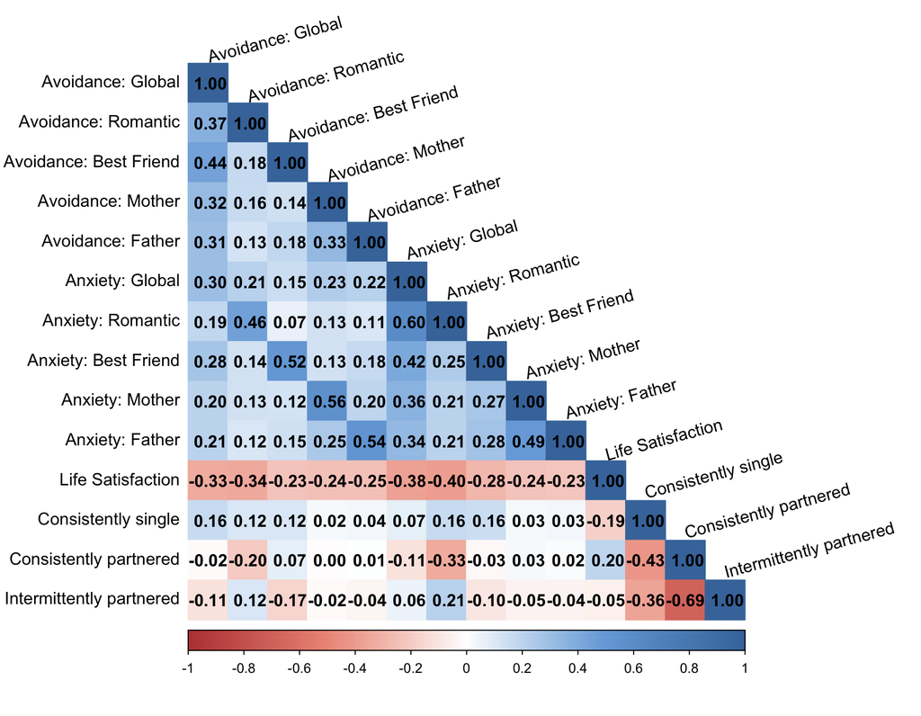

```r
col <- colorRampPalette(c("#BB4444", "#EE9988", "#FFFFFF", "#77AADD", "#4477AA"))

corrplot(cormat_m1, method="color", col=col(200),
         type="lower", order="original",
         addCoef.col = "black", # Add coefficient of correlation
         tl.col="black", tl.srt=15, #Text label color and rotation
         diag=T)
```

Plot: Correlation matrix at month 2

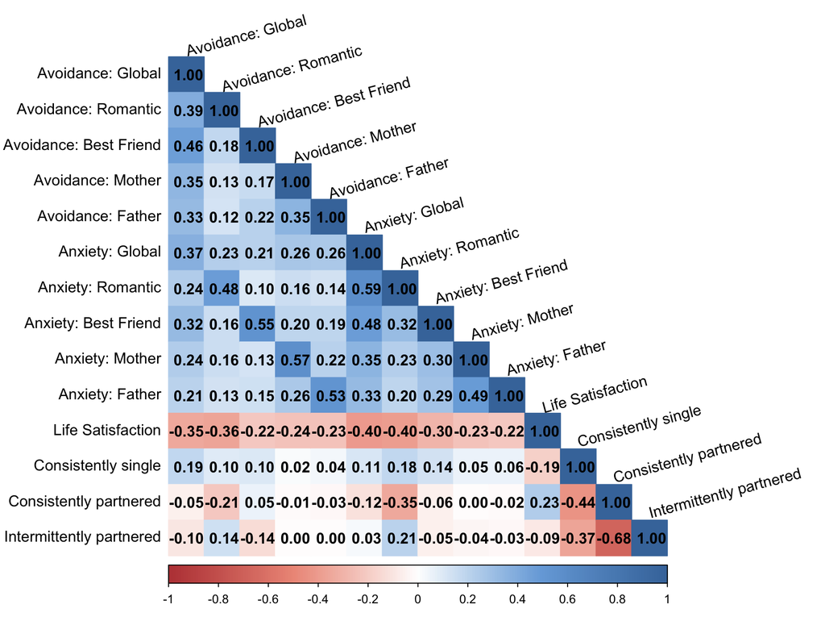

```r
corrplot(cormat_m2, method="color", col=col(200),
         type="lower", order="original",
         addCoef.col = "black", # Add coefficient of correlation
         tl.col="black", tl.srt=15, #Text label color and rotation
         diag=T)
```

Plot: Correlation matrix at month 3

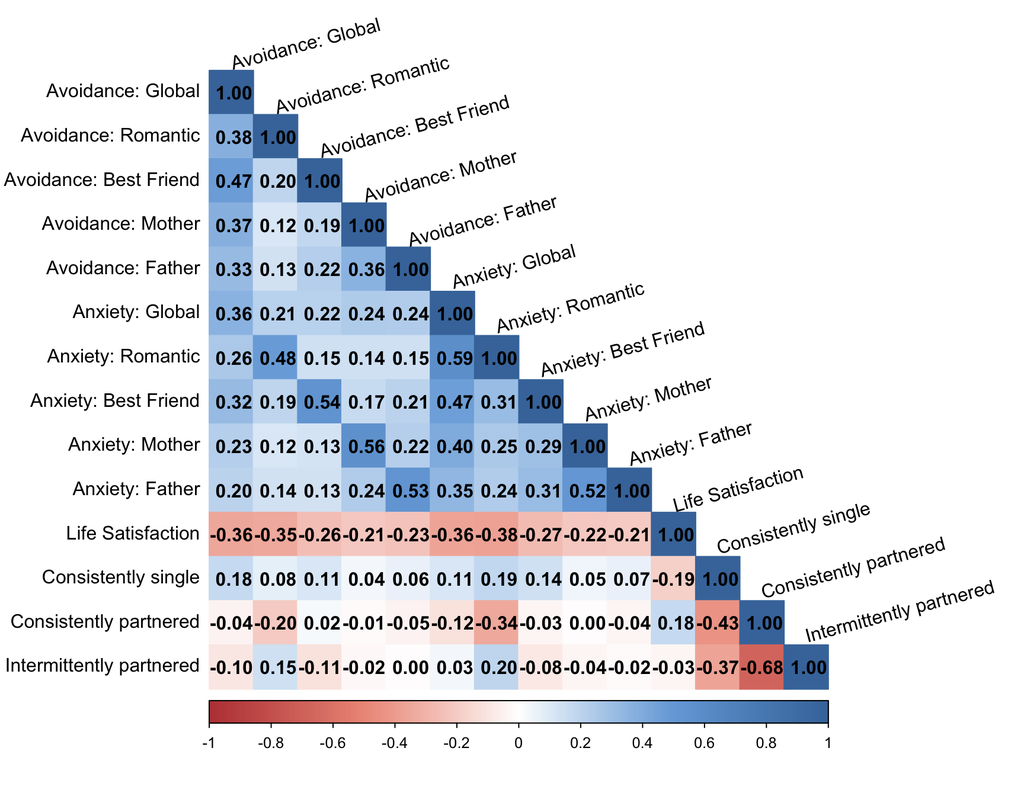

```r
corrplot(cormat_m3, method="color", col=col(200),
         type="lower", order="original",
         addCoef.col = "black", # Add coefficient of correlation
         tl.col="black", tl.srt=15, #Text label color and rotation
         diag=T)
```

Structure of associations is quite similar over time!

### 3.2.4 Variable distributions

#### 3.2.4.1 Avoidance

Prepare df:

```r
df_distr_plot_avoi_1_5 <- df_atta %>%
  filter(time_month_rd %in% c(1:5)) %>%
  rename(wave = time_month_rd) %>%
  select(wave, all_of(avoi_short), swb) %>%
  pivot_longer(cols = c(avoi_short, "swb"),
    names_to = "variable",
    values_to = "value") %>%
  mutate(
    variable = factor(variable, levels = c(avoi_short, "swb"), labels = c(avoi_maj, "Life Satisfaction")), # relabel
    wave = factor(wave, levels = c(1:5), labels = paste0("M", c(1:5)))
  )
df_distr_plot_avoi_6_10 <- df_atta %>%
  filter(time_month_rd %in% c(6:10)) %>%
  rename(wave = time_month_rd) %>%
  select(wave, all_of(avoi_short), swb) %>%
  pivot_longer(cols = c(avoi_short, "swb"),
    names_to = "variable",
    values_to = "value") %>%
  mutate(
    variable = factor(variable, levels = c(avoi_short, "swb"), labels = c(avoi_maj, "Life Satisfaction")), # relabel
    wave = factor(wave, levels = c(6:10), labels = paste0("M", c(6:10)))
  )

df_distr_plot_avoi_11_15 <- df_atta %>%
  filter(time_month_rd %in% c(11:15)) %>%
  rename(wave = time_month_rd) %>%
  select(wave, all_of(avoi_short), swb) %>%
  pivot_longer(cols = c(avoi_short, "swb"),
    names_to = "variable",
    values_to = "value") %>%
  mutate(
    variable = factor(variable, levels = c(avoi_short, "swb"), labels = c(avoi_maj, "Life Satisfaction")), # relabel
    wave = factor(wave, levels = c(11:15), labels = paste0("M", c(11:15)))
  )

df_distr_plot_avoi_16_20 <- df_atta %>%
  filter(time_month_rd %in% c(16:20)) %>%
  rename(wave = time_month_rd) %>%
  select(wave, all_of(avoi_short), swb) %>%
  pivot_longer(cols = c(avoi_short, "swb"),
    names_to = "variable",
    values_to = "value") %>%
  mutate(
    variable = factor(variable, levels = c(avoi_short, "swb"), labels = c(avoi_maj, "Life Satisfaction")), # relabel
    wave = factor(wave, levels = c(16:20), labels = paste0("M", c(16:20)))
  )
```

Plot distributions across time: months 1-5

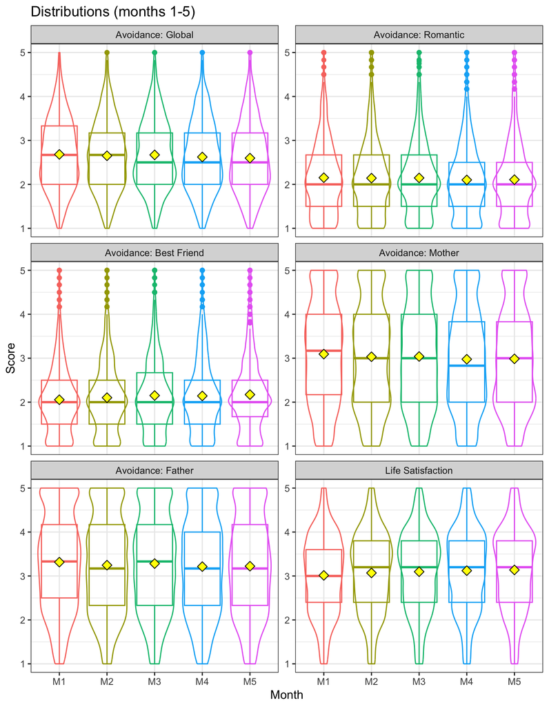

```r
ggplot(df_distr_plot_avoi_1_5 %>% filter(!is.na(value)), aes(x = wave, y = value, fill = wave, color = wave)) +
  geom_boxplot(fill = NA) +
  geom_violin(fill = NA) +
  # Add the mean
  stat_summary(
    fun = mean,                 # calculate mean
    geom = "point",             # draw as points
    shape = 23,                 # filled diamond
    size = 3,                   # point size
    color = "black",            # border color
    fill = "yellow"             # fill color of the diamond
  ) +
  facet_wrap(~variable, scales = "free_y", ncol=2) +
  labs(x = "Month", y = "Score", title = "Distributions (months 1-5)") +
  theme_bw() +
  theme(legend.position = "none")
```

Yellow diamonds represent the sample means. Bars of boxplot represent the median.

Plot distributions across time: months 6-10

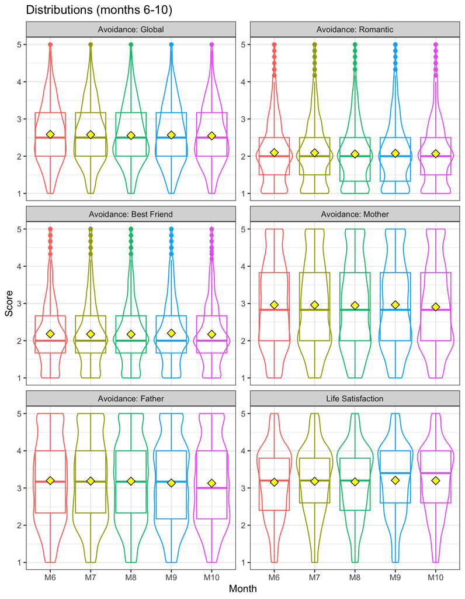

```r
ggplot(df_distr_plot_avoi_6_10 %>% filter(!is.na(value)), aes(x = wave, y = value, fill = wave, color = wave)) +
  geom_boxplot(fill = NA) +
  geom_violin(fill = NA) +
  # Add the mean
  stat_summary(
    fun = mean,                 # calculate mean
    geom = "point",             # draw as points
    shape = 23,                 # filled diamond
    size = 3,                   # point size
    color = "black",            # border color
    fill = "yellow"             # fill color of the diamond
  ) +
  facet_wrap(~variable, scales = "free_y", ncol=2) +
  labs(x = "Month", y = "Score", title = "Distributions (months 6-10)") +
  theme_bw() +
  theme(legend.position = "none")
```

Plot distributions across time: months 11-15

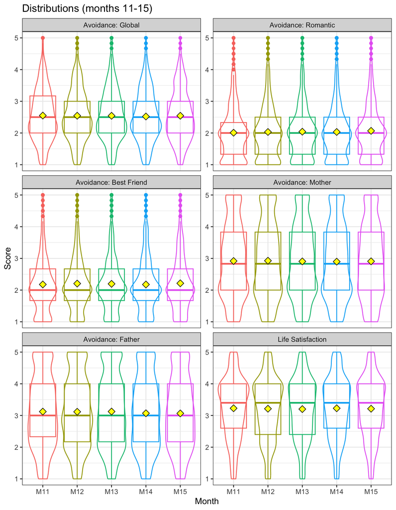

```r
ggplot(df_distr_plot_avoi_11_15 %>% filter(!is.na(value)), aes(x = wave, y = value, fill = wave, color = wave)) +
  geom_boxplot(fill = NA) +
  geom_violin(fill = NA) +
  # Add the mean
  stat_summary(
    fun = mean,                 # calculate mean
    geom = "point",             # draw as points
    shape = 23,                 # filled diamond
    size = 3,                   # point size
    color = "black",            # border color
    fill = "yellow"             # fill color of the diamond
  ) +
  facet_wrap(~variable, scales = "free_y", ncol=2) +
  labs(x = "Month", y = "Score", title = "Distributions (months 11-15)") +
  theme_bw() +
  theme(legend.position = "none")
```

Plot distributions across time: months 16-20

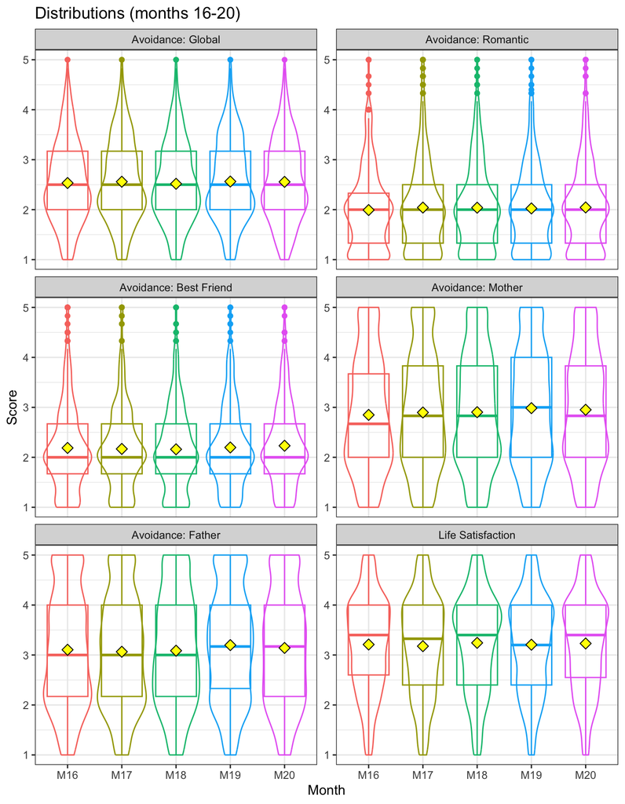

```r
ggplot(df_distr_plot_avoi_16_20 %>% filter(!is.na(value)), aes(x = wave, y = value, fill = wave, color = wave)) +
  geom_boxplot(fill = NA) +
  geom_violin(fill = NA) +
  # Add the mean
  stat_summary(
    fun = mean,                 # calculate mean
    geom = "point",             # draw as points
    shape = 23,                 # filled diamond
    size = 3,                   # point size
    color = "black",            # border color
    fill = "yellow"             # fill color of the diamond
  ) +
  facet_wrap(~variable, scales = "free_y", ncol=2) +
  labs(x = "Month", y = "Score", title = "Distributions (months 16-20)") +
  theme_bw() +
  theme(legend.position = "none")
```

#### 3.2.4.2 Anxiety

Prepare df:

```r
df_distr_plot_anxi_1_5 <- df_atta %>%
  filter(time_month_rd %in% c(1:5)) %>%
  rename(wave = time_month_rd) %>%
  select(wave, all_of(anxi_short), swb) %>%
  pivot_longer(cols = c(anxi_short, "swb"),
    names_to = "variable",
    values_to = "value") %>%
  mutate(
    variable = factor(variable, levels = c(anxi_short, "swb"), labels = c(anxi_maj, "Life Satisfaction")), # relabel
    wave = factor(wave, levels = c(1:5), labels = paste0("M", c(1:5)))
  )
df_distr_plot_anxi_6_10 <- df_atta %>%
  filter(time_month_rd %in% c(6:10)) %>%
  rename(wave = time_month_rd) %>%
  select(wave, all_of(anxi_short), swb) %>%
  pivot_longer(cols = c(anxi_short, "swb"),
    names_to = "variable",
    values_to = "value") %>%
  mutate(
    variable = factor(variable, levels = c(anxi_short, "swb"), labels = c(anxi_maj, "Life Satisfaction")), # relabel
    wave = factor(wave, levels = c(6:10), labels = paste0("M", c(6:10)))
  )

df_distr_plot_anxi_11_15 <- df_atta %>%
  filter(time_month_rd %in% c(11:15)) %>%
  rename(wave = time_month_rd) %>%
  select(wave, all_of(anxi_short), swb) %>%
  pivot_longer(cols = c(anxi_short, "swb"),
    names_to = "variable",
    values_to = "value") %>%
  mutate(
    variable = factor(variable, levels = c(anxi_short, "swb"), labels = c(anxi_maj, "Life Satisfaction")), # relabel
    wave = factor(wave, levels = c(11:15), labels = paste0("M", c(11:15)))
  )

df_distr_plot_anxi_16_20 <- df_atta %>%
  filter(time_month_rd %in% c(16:20)) %>%
  rename(wave = time_month_rd) %>%
  select(wave, all_of(anxi_short), swb) %>%
  pivot_longer(cols = c(anxi_short, "swb"),
    names_to = "variable",
    values_to = "value") %>%
  mutate(
    variable = factor(variable, levels = c(anxi_short, "swb"), labels = c(anxi_maj, "Life Satisfaction")), # relabel
    wave = factor(wave, levels = c(16:20), paste0("M", c(16:20)))
  )
```

Plot distributions across time: months 1-5

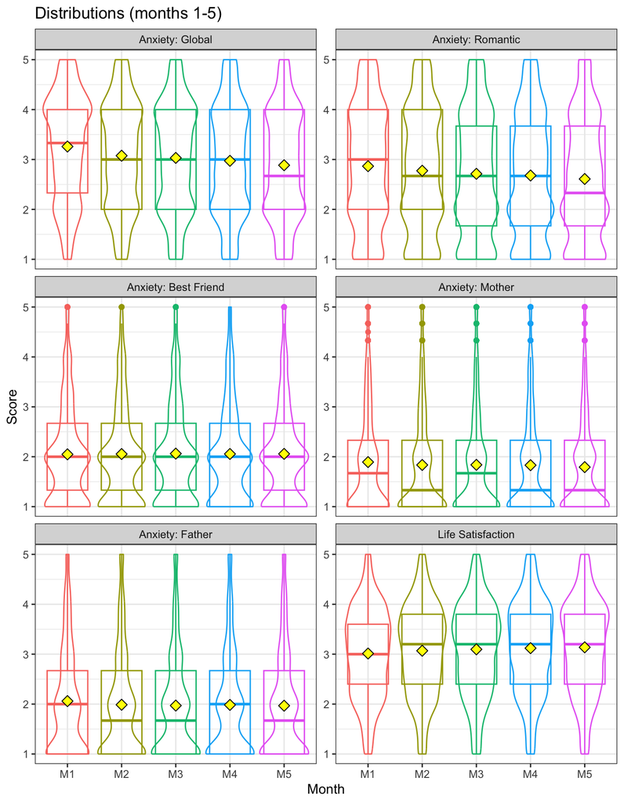

```r
ggplot(df_distr_plot_anxi_1_5 %>% filter(!is.na(value)), aes(x = wave, y = value, fill = wave, color = wave)) +
  geom_boxplot(fill = NA) +
  geom_violin(fill = NA) +
  # Add the mean
  stat_summary(
    fun = mean,                 # calculate mean
    geom = "point",             # draw as points
    shape = 23,                 # filled diamond
    size = 3,                   # point size
    color = "black",            # border color
    fill = "yellow"             # fill color of the diamond
  ) +
  facet_wrap(~variable, scales = "free_y", ncol=2) +
  labs(x = "Month", y = "Score", title = "Distributions (months 1-5)") +
  theme_bw() +
  theme(legend.position = "none")
```

Yellow diamonds represent the sample means. Bars of boxplot represent the median.

Plot distributions across time: months 6-10

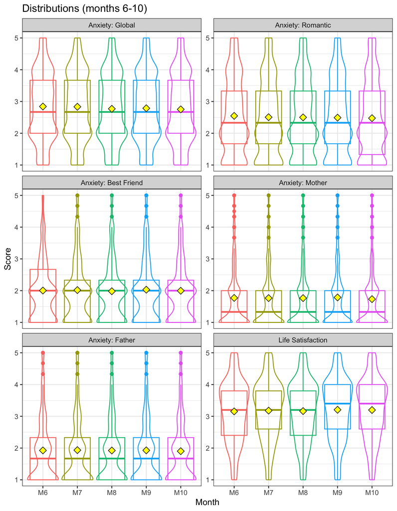

```r
ggplot(df_distr_plot_anxi_6_10 %>% filter(!is.na(value)), aes(x = wave, y = value, fill = wave, color = wave)) +
  geom_boxplot(fill = NA) +
  geom_violin(fill = NA) +
  # Add the mean
  stat_summary(
    fun = mean,                 # calculate mean
    geom = "point",             # draw as points
    shape = 23,                 # filled diamond
    size = 3,                   # point size
    color = "black",            # border color
    fill = "yellow"             # fill color of the diamond
  ) +
  facet_wrap(~variable, scales = "free_y", ncol=2) +
  labs(x = "Month", y = "Score", title = "Distributions (months 6-10)") +
  theme_bw() +
  theme(legend.position = "none")
```

Plot distributions across time: months 11-15

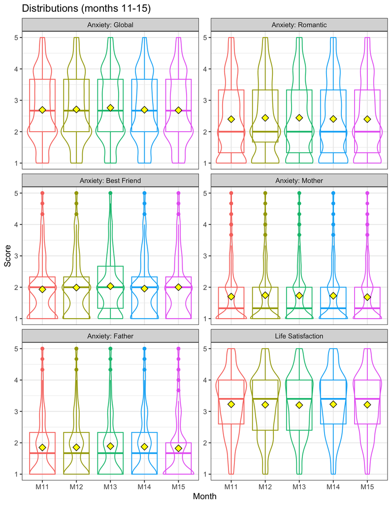

```r
ggplot(df_distr_plot_anxi_11_15 %>% filter(!is.na(value)), aes(x = wave, y = value, fill = wave, color = wave)) +
  geom_boxplot(fill = NA) +
  geom_violin(fill = NA) +
  # Add the mean
  stat_summary(
    fun = mean,                 # calculate mean
    geom = "point",             # draw as points
    shape = 23,                 # filled diamond
    size = 3,                   # point size
    color = "black",            # border color
    fill = "yellow"             # fill color of the diamond
  ) +
  facet_wrap(~variable, scales = "free_y", ncol=2) +
  labs(x = "Month", y = "Score", title = "Distributions (months 11-15)") +
  theme_bw() +
  theme(legend.position = "none")
```

Plot distributions across time: months 16-20

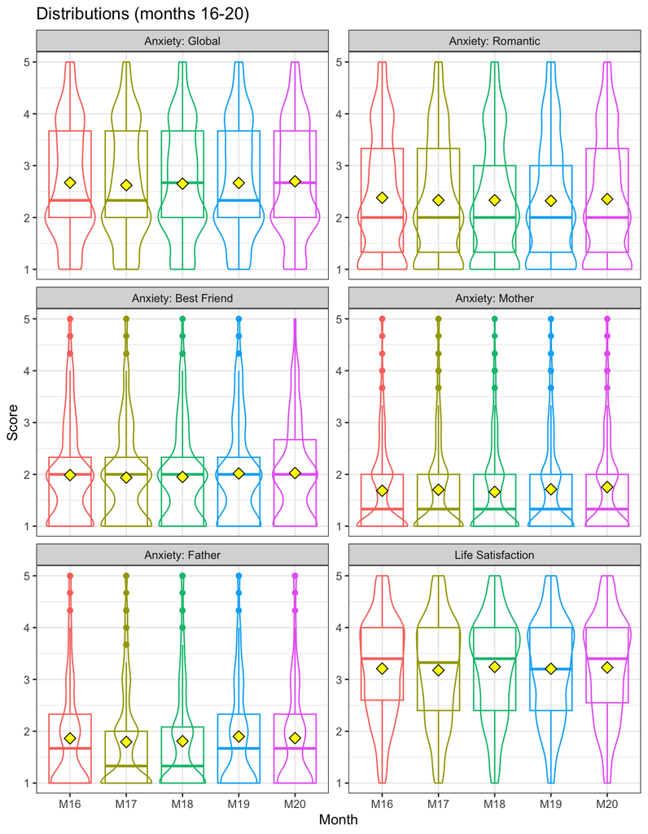

```r
ggplot(df_distr_plot_anxi_16_20 %>% filter(!is.na(value)), aes(x = wave, y = value, fill = wave, color = wave)) +
  geom_boxplot(fill = NA) +
  geom_violin(fill = NA) +
  # Add the mean
  stat_summary(
    fun = mean,                 # calculate mean
    geom = "point",             # draw as points
    shape = 23,                 # filled diamond
    size = 3,                   # point size
    color = "black",            # border color
    fill = "yellow"             # fill color of the diamond
  ) +
  facet_wrap(~variable, scales = "free_y", ncol=2) +
  labs(x = "Month", y = "Score", title = "Distributions (months 16-20)") +
  theme_bw() +
  theme(legend.position = "none")
```

### 3.2.5 Descriptives over time

Show means/SD over time: avoidance vars

```r
df_atta %>%
  rename(month = time_month_rd) %>%
  group_by(month) %>%
  summarise(
    n = n(),
    `Avoid.: Global`      = sprintf("%.2f (%.2f)", mean(avoi_glo, na.rm = TRUE), sd(avoi_glo, na.rm = TRUE)),
    `Avoid.: Romantic`    = sprintf("%.2f (%.2f)", mean(avoi_rom, na.rm = TRUE), sd(avoi_rom, na.rm = TRUE)),
    `Avoid.: Best Friend` = sprintf("%.2f (%.2f)", mean(avoi_fri, na.rm = TRUE), sd(avoi_fri, na.rm = TRUE)),
    `Avoid.: Mother`      = sprintf("%.2f (%.2f)", mean(avoi_mot, na.rm = TRUE), sd(avoi_mot, na.rm = TRUE)),
    `Avoid.: Father`      = sprintf("%.2f (%.2f)", mean(avoi_fat, na.rm = TRUE), sd(avoi_fat, na.rm = TRUE)),
    `LS`      = sprintf("%.2f (%.2f)", mean(swb, na.rm = TRUE), sd(swb, na.rm = TRUE))
  ) %>%
  kable()
```

| month | n | Avoid.: Global | Avoid.: Romantic | Avoid.: Best Friend | Avoid.: Mother | Avoid.: Father | LS |
| --- | --- | --- | --- | --- | --- | --- | --- |
| 0 | 3542 | 2.70 (0.82) | 2.20 (0.84) | 2.00 (0.75) | 3.08 (1.17) | 3.32 (1.11) | 2.93 (0.88) |
| 1 | 1805 | 2.68 (0.81) | 2.15 (0.82) | 2.05 (0.76) | 3.09 (1.16) | 3.31 (1.11) | 3.01 (0.90) |
| 2 | 2016 | 2.65 (0.79) | 2.14 (0.84) | 2.10 (0.79) | 3.03 (1.18) | 3.25 (1.10) | 3.07 (0.90) |
| 3 | 1884 | 2.67 (0.80) | 2.15 (0.82) | 2.15 (0.81) | 3.04 (1.16) | 3.28 (1.10) | 3.10 (0.92) |
| 4 | 1714 | 2.62 (0.81) | 2.10 (0.81) | 2.14 (0.82) | 2.98 (1.16) | 3.21 (1.11) | 3.12 (0.93) |
| 5 | 1743 | 2.60 (0.81) | 2.11 (0.84) | 2.17 (0.83) | 2.99 (1.14) | 3.22 (1.12) | 3.14 (0.93) |
| 6 | 1606 | 2.59 (0.82) | 2.10 (0.82) | 2.18 (0.84) | 2.96 (1.15) | 3.20 (1.12) | 3.15 (0.95) |
| 7 | 1762 | 2.58 (0.81) | 2.09 (0.85) | 2.18 (0.86) | 2.96 (1.15) | 3.19 (1.12) | 3.18 (0.94) |
| 8 | 1600 | 2.56 (0.81) | 2.06 (0.82) | 2.17 (0.83) | 2.95 (1.18) | 3.18 (1.12) | 3.16 (0.95) |
| 9 | 1638 | 2.57 (0.82) | 2.08 (0.84) | 2.20 (0.86) | 2.96 (1.17) | 3.13 (1.11) | 3.21 (0.96) |
| 10 | 1676 | 2.55 (0.80) | 2.07 (0.83) | 2.17 (0.84) | 2.91 (1.15) | 3.13 (1.11) | 3.20 (0.96) |
| 11 | 1585 | 2.55 (0.81) | 2.01 (0.82) | 2.18 (0.86) | 2.92 (1.16) | 3.12 (1.12) | 3.23 (0.96) |
| 12 | 1642 | 2.54 (0.82) | 2.03 (0.83) | 2.21 (0.83) | 2.93 (1.18) | 3.12 (1.11) | 3.21 (0.97) |
| 13 | 1552 | 2.54 (0.81) | 2.04 (0.82) | 2.20 (0.84) | 2.91 (1.14) | 3.12 (1.13) | 3.20 (0.96) |
| 14 | 1363 | 2.52 (0.81) | 2.03 (0.83) | 2.18 (0.83) | 2.90 (1.17) | 3.07 (1.13) | 3.23 (0.96) |
| 15 | 1169 | 2.54 (0.81) | 2.07 (0.85) | 2.21 (0.85) | 2.91 (1.16) | 3.07 (1.12) | 3.21 (0.95) |
| 16 | 1045 | 2.53 (0.82) | 1.99 (0.80) | 2.19 (0.84) | 2.85 (1.15) | 3.10 (1.15) | 3.21 (0.95) |
| 17 | 914 | 2.56 (0.83) | 2.04 (0.87) | 2.17 (0.81) | 2.90 (1.16) | 3.06 (1.11) | 3.18 (0.99) |
| 18 | 797 | 2.52 (0.81) | 2.04 (0.84) | 2.16 (0.81) | 2.90 (1.15) | 3.09 (1.12) | 3.24 (0.97) |
| 19 | 795 | 2.56 (0.82) | 2.02 (0.83) | 2.20 (0.82) | 2.98 (1.16) | 3.20 (1.13) | 3.21 (0.96) |
| 20 | 780 | 2.56 (0.82) | 2.04 (0.85) | 2.23 (0.82) | 2.95 (1.15) | 3.14 (1.13) | 3.23 (0.96) |
| 21 | 752 | 2.54 (0.84) | 2.03 (0.83) | 2.21 (0.80) | 2.98 (1.15) | 3.14 (1.11) | 3.23 (0.97) |
| 22 | 791 | 2.53 (0.82) | 2.05 (0.85) | 2.22 (0.83) | 2.98 (1.14) | 3.16 (1.11) | 3.24 (0.95) |
| 23 | 755 | 2.52 (0.83) | 2.01 (0.85) | 2.19 (0.80) | 2.87 (1.19) | 3.11 (1.12) | 3.29 (0.96) |
| 24 | 772 | 2.50 (0.82) | 2.03 (0.83) | 2.22 (0.82) | 2.94 (1.16) | 3.12 (1.14) | 3.27 (0.95) |
| 25 | 695 | 2.53 (0.81) | 2.02 (0.84) | 2.27 (0.85) | 2.96 (1.14) | 3.14 (1.11) | 3.23 (1.00) |
| 26 | 599 | 2.55 (0.84) | 2.04 (0.86) | 2.27 (0.86) | 2.96 (1.18) | 3.16 (1.14) | 3.22 (0.98) |
| 27 | 476 | 2.51 (0.84) | 1.95 (0.80) | 2.19 (0.81) | 3.01 (1.19) | 3.14 (1.13) | 3.27 (0.99) |
| 28 | 421 | 2.54 (0.84) | 1.98 (0.81) | 2.29 (0.85) | 2.97 (1.13) | 3.17 (1.12) | 3.22 (1.01) |
| 29 | 376 | 2.52 (0.82) | 2.04 (0.88) | 2.25 (0.82) | 2.92 (1.15) | 3.13 (1.13) | 3.25 (0.97) |
| 30 | 318 | 2.54 (0.82) | 1.92 (0.78) | 2.28 (0.83) | 3.00 (1.15) | 3.19 (1.10) | 3.22 (0.95) |
| 31 | 266 | 2.53 (0.84) | 2.00 (0.81) | 2.28 (0.85) | 3.07 (1.17) | 3.15 (1.11) | 3.23 (0.98) |
| 32 | 212 | 2.46 (0.85) | 1.96 (0.84) | 2.25 (0.84) | 2.91 (1.16) | 3.12 (1.15) | 3.29 (1.00) |
| 33 | 179 | 2.46 (0.86) | 1.93 (0.78) | 2.25 (0.86) | 3.07 (1.18) | 3.22 (1.15) | 3.30 (0.96) |
| 34 | 140 | 2.49 (0.86) | 1.99 (0.77) | 2.26 (0.81) | 2.97 (1.18) | 3.14 (1.15) | 3.28 (0.93) |
| 35 | 112 | 2.40 (0.80) | 1.94 (0.85) | 2.09 (0.83) | 2.83 (1.21) | 2.92 (1.30) | 3.34 (0.91) |

Show means/SD over time: anxiety vars

```r
df_atta %>%
  rename(month = time_month_rd) %>%
  group_by(month) %>%
  summarise(
    n = n(),
    `Anx.: Global`      = sprintf("%.2f (%.2f)", mean(anxi_glo, na.rm = TRUE), sd(anxi_glo, na.rm = TRUE)),
    `Anx.: Romantic`    = sprintf("%.2f (%.2f)", mean(anxi_rom, na.rm = TRUE), sd(anxi_rom, na.rm = TRUE)),
    `Anx.: Best Friend` = sprintf("%.2f (%.2f)", mean(anxi_fri, na.rm = TRUE), sd(anxi_fri, na.rm = TRUE)),
    `Anx.: Mother`      = sprintf("%.2f (%.2f)", mean(anxi_mot, na.rm = TRUE), sd(anxi_mot, na.rm = TRUE)),
    `Anx.: Father`      = sprintf("%.2f (%.2f)", mean(anxi_fat, na.rm = TRUE), sd(anxi_fat, na.rm = TRUE)),
    `LS`      = sprintf("%.2f (%.2f)", mean(swb, na.rm = TRUE), sd(swb, na.rm = TRUE))
  ) %>%
  kable()
```

| month | n | Anx.: Global | Anx.: Romantic | Anx.: Best Friend | Anx.: Mother | Anx.: Father | LS |
| --- | --- | --- | --- | --- | --- | --- | --- |
| 0 | 3542 | 3.37 (1.05) | 2.98 (1.23) | 2.06 (0.99) | 1.95 (1.06) | 2.13 (1.13) | 2.93 (0.88) |
| 1 | 1805 | 3.26 (1.06) | 2.87 (1.19) | 2.05 (0.96) | 1.89 (1.00) | 2.06 (1.07) | 3.01 (0.90) |
| 2 | 2016 | 3.08 (1.07) | 2.77 (1.20) | 2.05 (0.97) | 1.84 (1.02) | 1.99 (1.05) | 3.07 (0.90) |
| 3 | 1884 | 3.03 (1.08) | 2.71 (1.20) | 2.06 (0.98) | 1.84 (1.00) | 1.97 (1.04) | 3.10 (0.92) |
| 4 | 1714 | 2.97 (1.10) | 2.68 (1.18) | 2.06 (0.98) | 1.83 (1.00) | 1.98 (1.06) | 3.12 (0.93) |
| 5 | 1743 | 2.88 (1.08) | 2.61 (1.16) | 2.06 (0.96) | 1.79 (0.95) | 1.97 (1.05) | 3.14 (0.93) |
| 6 | 1606 | 2.84 (1.08) | 2.55 (1.19) | 2.00 (0.95) | 1.77 (0.97) | 1.93 (1.04) | 3.15 (0.95) |
| 7 | 1762 | 2.83 (1.08) | 2.51 (1.18) | 2.02 (0.95) | 1.77 (0.95) | 1.93 (1.05) | 3.18 (0.94) |
| 8 | 1600 | 2.77 (1.08) | 2.50 (1.17) | 1.98 (0.92) | 1.76 (0.98) | 1.92 (1.03) | 3.16 (0.95) |
| 9 | 1638 | 2.79 (1.07) | 2.49 (1.16) | 2.03 (0.96) | 1.79 (0.96) | 1.93 (1.04) | 3.21 (0.96) |
| 10 | 1676 | 2.75 (1.09) | 2.47 (1.18) | 2.00 (0.93) | 1.73 (0.92) | 1.90 (1.00) | 3.20 (0.96) |
| 11 | 1585 | 2.69 (1.08) | 2.40 (1.16) | 1.93 (0.92) | 1.70 (0.90) | 1.85 (0.98) | 3.23 (0.96) |
| 12 | 1642 | 2.71 (1.07) | 2.44 (1.15) | 1.99 (0.94) | 1.75 (0.93) | 1.86 (0.96) | 3.21 (0.97) |
| 13 | 1552 | 2.76 (1.08) | 2.44 (1.15) | 2.03 (0.96) | 1.73 (0.90) | 1.89 (1.00) | 3.20 (0.96) |
| 14 | 1363 | 2.70 (1.07) | 2.41 (1.17) | 1.96 (0.92) | 1.73 (0.92) | 1.87 (0.98) | 3.23 (0.96) |
| 15 | 1169 | 2.68 (1.08) | 2.40 (1.14) | 2.00 (0.94) | 1.68 (0.86) | 1.82 (0.96) | 3.21 (0.95) |
| 16 | 1045 | 2.67 (1.10) | 2.38 (1.15) | 1.99 (0.93) | 1.68 (0.86) | 1.86 (1.00) | 3.21 (0.95) |
| 17 | 914 | 2.62 (1.09) | 2.33 (1.13) | 1.94 (0.90) | 1.70 (0.92) | 1.79 (0.96) | 3.18 (0.99) |
| 18 | 797 | 2.65 (1.08) | 2.33 (1.14) | 1.95 (0.89) | 1.66 (0.85) | 1.81 (0.99) | 3.24 (0.97) |
| 19 | 795 | 2.67 (1.09) | 2.32 (1.14) | 2.02 (0.95) | 1.71 (0.88) | 1.90 (1.02) | 3.21 (0.96) |
| 20 | 780 | 2.70 (1.08) | 2.36 (1.14) | 2.03 (0.94) | 1.75 (0.91) | 1.87 (1.00) | 3.23 (0.96) |
| 21 | 752 | 2.65 (1.09) | 2.32 (1.14) | 2.01 (0.95) | 1.74 (0.88) | 1.89 (1.00) | 3.23 (0.97) |
| 22 | 791 | 2.62 (1.08) | 2.30 (1.14) | 2.01 (0.93) | 1.72 (0.90) | 1.87 (1.01) | 3.24 (0.95) |
| 23 | 755 | 2.56 (1.07) | 2.28 (1.13) | 1.95 (0.87) | 1.64 (0.81) | 1.81 (0.94) | 3.29 (0.96) |
| 24 | 772 | 2.61 (1.07) | 2.30 (1.13) | 2.01 (0.93) | 1.70 (0.88) | 1.83 (0.96) | 3.27 (0.95) |
| 25 | 695 | 2.59 (1.06) | 2.31 (1.12) | 2.01 (0.96) | 1.69 (0.85) | 1.83 (0.97) | 3.23 (1.00) |
| 26 | 599 | 2.63 (1.09) | 2.30 (1.12) | 2.07 (0.96) | 1.72 (0.89) | 1.84 (0.96) | 3.22 (0.98) |
| 27 | 476 | 2.59 (1.09) | 2.27 (1.15) | 2.03 (0.96) | 1.73 (0.91) | 1.77 (0.89) | 3.27 (0.99) |
| 28 | 421 | 2.64 (1.08) | 2.30 (1.12) | 2.05 (0.97) | 1.70 (0.90) | 1.81 (0.95) | 3.22 (1.01) |
| 29 | 376 | 2.58 (1.07) | 2.36 (1.14) | 2.02 (0.94) | 1.71 (0.84) | 1.82 (0.91) | 3.25 (0.97) |
| 30 | 318 | 2.68 (1.09) | 2.24 (1.07) | 2.09 (0.96) | 1.72 (0.90) | 1.84 (0.94) | 3.22 (0.95) |
| 31 | 266 | 2.68 (1.08) | 2.33 (1.16) | 2.09 (0.92) | 1.74 (0.89) | 1.87 (0.94) | 3.23 (0.98) |
| 32 | 212 | 2.51 (1.11) | 2.25 (1.16) | 2.02 (0.89) | 1.66 (0.78) | 1.78 (0.92) | 3.29 (1.00) |
| 33 | 179 | 2.54 (1.08) | 2.16 (1.10) | 2.07 (0.96) | 1.74 (0.92) | 1.86 (0.96) | 3.30 (0.96) |
| 34 | 140 | 2.65 (1.09) | 2.26 (1.10) | 2.02 (0.88) | 1.66 (0.76) | 1.82 (0.88) | 3.28 (0.93) |
| 35 | 112 | 2.56 (1.06) | 2.17 (1.13) | 1.96 (0.94) | 1.59 (0.77) | 1.79 (0.96) | 3.34 (0.91) |

#### 3.2.5.1 For each group

##### 3.2.5.1.1 Consistently single people

Show means/SD over time: avoidance vars

```r
df_atta %>%
  filter(group_fct=="Consistently single people") %>%
  rename(month = time_month_rd) %>%
  group_by(month) %>%
  summarise(
    n = n(),
    `Avoid.: Global`      = sprintf("%.2f (%.2f)", mean(avoi_glo, na.rm = TRUE), sd(avoi_glo, na.rm = TRUE)),
    `Avoid.: Romantic`    = sprintf("%.2f (%.2f)", mean(avoi_rom, na.rm = TRUE), sd(avoi_rom, na.rm = TRUE)),
    `Avoid.: Best Friend` = sprintf("%.2f (%.2f)", mean(avoi_fri, na.rm = TRUE), sd(avoi_fri, na.rm = TRUE)),
    `Avoid.: Mother`      = sprintf("%.2f (%.2f)", mean(avoi_mot, na.rm = TRUE), sd(avoi_mot, na.rm = TRUE)),
    `Avoid.: Father`      = sprintf("%.2f (%.2f)", mean(avoi_fat, na.rm = TRUE), sd(avoi_fat, na.rm = TRUE)),
    `LS`      = sprintf("%.2f (%.2f)", mean(swb, na.rm = TRUE), sd(swb, na.rm = TRUE))
  ) %>%
  kable()
```

| month | n | Avoid.: Global | Avoid.: Romantic | Avoid.: Best Friend | Avoid.: Mother | Avoid.: Father | LS |
| --- | --- | --- | --- | --- | --- | --- | --- |
| 0 | 623 | 2.96 (0.81) | 2.41 (0.84) | 2.14 (0.81) | 3.14 (1.17) | 3.47 (1.06) | 2.60 (0.91) |
| 1 | 331 | 2.96 (0.80) | 2.35 (0.78) | 2.24 (0.83) | 3.15 (1.13) | 3.41 (1.06) | 2.66 (0.93) |
| 2 | 387 | 2.95 (0.77) | 2.31 (0.81) | 2.26 (0.83) | 3.08 (1.17) | 3.33 (1.06) | 2.72 (0.91) |
| 3 | 357 | 2.96 (0.77) | 2.28 (0.78) | 2.34 (0.84) | 3.14 (1.11) | 3.43 (1.00) | 2.75 (0.94) |
| 4 | 314 | 2.89 (0.83) | 2.23 (0.80) | 2.36 (0.90) | 3.08 (1.14) | 3.40 (1.08) | 2.72 (0.93) |
| 5 | 315 | 2.85 (0.84) | 2.23 (0.84) | 2.33 (0.87) | 3.02 (1.16) | 3.38 (1.10) | 2.78 (0.93) |
| 6 | 297 | 2.86 (0.82) | 2.19 (0.78) | 2.33 (0.83) | 2.98 (1.17) | 3.34 (1.07) | 2.79 (1.00) |
| 7 | 305 | 2.82 (0.83) | 2.16 (0.84) | 2.34 (0.93) | 2.96 (1.18) | 3.35 (1.10) | 2.80 (0.99) |
| 8 | 290 | 2.80 (0.81) | 2.17 (0.82) | 2.31 (0.93) | 2.95 (1.14) | 3.27 (1.09) | 2.81 (0.99) |
| 9 | 282 | 2.81 (0.83) | 2.25 (0.84) | 2.37 (0.90) | 3.01 (1.17) | 3.30 (1.10) | 2.76 (0.97) |
| 10 | 299 | 2.78 (0.84) | 2.20 (0.80) | 2.32 (0.91) | 2.91 (1.17) | 3.36 (1.08) | 2.83 (1.00) |
| 11 | 273 | 2.78 (0.85) | 2.13 (0.81) | 2.32 (0.92) | 2.89 (1.14) | 3.28 (1.10) | 2.82 (0.97) |
| 12 | 272 | 2.75 (0.82) | 2.15 (0.79) | 2.34 (0.92) | 2.95 (1.18) | 3.22 (1.08) | 2.83 (1.03) |
| 13 | 252 | 2.83 (0.85) | 2.24 (0.84) | 2.39 (0.91) | 2.90 (1.14) | 3.32 (1.09) | 2.77 (0.99) |
| 14 | 220 | 2.74 (0.84) | 2.19 (0.82) | 2.34 (0.90) | 2.90 (1.20) | 3.24 (1.15) | 2.84 (1.02) |
| 15 | 189 | 2.86 (0.86) | 2.29 (0.86) | 2.48 (0.91) | 2.99 (1.18) | 3.37 (1.05) | 2.75 (0.97) |
| 16 | 168 | 2.82 (0.90) | 2.22 (0.83) | 2.40 (0.89) | 2.88 (1.15) | 3.40 (1.17) | 2.81 (1.02) |
| 17 | 123 | 2.85 (0.87) | 2.29 (0.91) | 2.41 (0.91) | 2.93 (1.15) | 3.23 (1.14) | 2.79 (1.03) |
| 18 | 108 | 2.87 (0.83) | 2.28 (0.86) | 2.41 (0.88) | 3.00 (1.06) | 3.46 (1.10) | 2.80 (0.98) |
| 19 | 104 | 2.92 (0.87) | 2.32 (0.86) | 2.41 (0.90) | 3.09 (1.14) | 3.57 (1.12) | 2.88 (1.00) |
| 20 | 100 | 2.93 (0.93) | 2.35 (0.87) | 2.49 (0.89) | 3.24 (1.16) | 3.67 (1.07) | 2.75 (1.02) |
| 21 | 101 | 2.97 (0.88) | 2.37 (0.84) | 2.47 (0.88) | 3.26 (1.03) | 3.63 (1.01) | 2.85 (1.03) |
| 22 | 95 | 2.91 (0.98) | 2.31 (0.82) | 2.43 (0.93) | 3.02 (1.17) | 3.65 (1.07) | 2.82 (0.97) |
| 23 | 95 | 3.02 (0.89) | 2.33 (0.87) | 2.43 (0.82) | 2.97 (1.21) | 3.60 (1.07) | 2.85 (1.00) |
| 24 | 103 | 2.96 (0.90) | 2.36 (0.86) | 2.53 (0.86) | 3.15 (1.14) | 3.53 (1.15) | 2.78 (1.06) |
| 25 | 84 | 2.94 (0.84) | 2.38 (0.80) | 2.57 (0.83) | 3.18 (1.13) | 3.56 (1.17) | 2.75 (0.96) |
| 26 | 75 | 3.04 (0.92) | 2.41 (0.87) | 2.66 (0.96) | 3.25 (1.05) | 3.65 (1.04) | 2.70 (1.04) |
| 27 | 52 | 2.93 (0.86) | 2.30 (0.84) | 2.47 (0.83) | 3.32 (1.15) | 3.68 (1.12) | 2.78 (1.07) |
| 28 | 53 | 3.02 (0.89) | 2.34 (0.88) | 2.54 (0.82) | 3.22 (1.06) | 3.48 (1.05) | 2.67 (1.02) |
| 29 | 46 | 2.94 (0.81) | 2.39 (0.92) | 2.59 (0.91) | 3.13 (1.03) | 3.65 (1.03) | 2.68 (0.99) |
| 30 | 35 | 3.26 (0.94) | 2.34 (0.87) | 2.65 (0.99) | 3.33 (0.99) | 3.69 (1.22) | 2.53 (1.01) |
| 31 | 22 | 2.99 (0.87) | 2.46 (0.83) | 2.73 (1.07) | 3.45 (0.88) | 3.79 (1.28) | 2.57 (0.94) |
| 32 | 24 | 3.04 (1.05) | 2.35 (1.04) | 2.64 (0.88) | 3.28 (1.07) | 3.52 (1.16) | 2.67 (1.11) |
| 33 | 17 | 3.29 (1.04) | 2.58 (1.08) | 2.77 (0.88) | 3.71 (1.01) | 4.09 (1.25) | 2.29 (1.07) |
| 34 | 15 | 2.85 (1.08) | 2.50 (0.84) | 2.60 (0.58) | 3.08 (0.94) | 3.50 (1.25) | 2.80 (1.13) |
| 35 | 13 | 2.94 (0.85) | 2.46 (0.46) | 2.55 (0.78) | 2.94 (0.78) | 3.58 (1.30) | 3.03 (1.07) |

Show means/SD over time: anxiety vars

```r
df_atta %>%
  filter(group_fct=="Consistently single people") %>%
  rename(month = time_month_rd) %>%
  group_by(month) %>%
  summarise(
    n = n(),
    `Anx.: Global`      = sprintf("%.2f (%.2f)", mean(anxi_glo, na.rm = TRUE), sd(anxi_glo, na.rm = TRUE)),
    `Anx.: Romantic`    = sprintf("%.2f (%.2f)", mean(anxi_rom, na.rm = TRUE), sd(anxi_rom, na.rm = TRUE)),
    `Anx.: Best Friend` = sprintf("%.2f (%.2f)", mean(anxi_fri, na.rm = TRUE), sd(anxi_fri, na.rm = TRUE)),
    `Anx.: Mother`      = sprintf("%.2f (%.2f)", mean(anxi_mot, na.rm = TRUE), sd(anxi_mot, na.rm = TRUE)),
    `Anx.: Father`      = sprintf("%.2f (%.2f)", mean(anxi_fat, na.rm = TRUE), sd(anxi_fat, na.rm = TRUE)),
    `LS`      = sprintf("%.2f (%.2f)", mean(swb, na.rm = TRUE), sd(swb, na.rm = TRUE))
  ) %>%
  kable()
```

| month | n | Anx.: Global | Anx.: Romantic | Anx.: Best Friend | Anx.: Mother | Anx.: Father | LS |
| --- | --- | --- | --- | --- | --- | --- | --- |
| 0 | 623 | 3.54 (1.01) | 3.41 (1.11) | 2.31 (1.13) | 2.05 (1.09) | 2.20 (1.06) | 2.60 (0.91) |
| 1 | 331 | 3.43 (1.05) | 3.28 (1.10) | 2.37 (1.12) | 1.95 (1.00) | 2.13 (1.02) | 2.66 (0.93) |
| 2 | 387 | 3.32 (1.04) | 3.22 (1.08) | 2.32 (1.07) | 1.94 (1.05) | 2.11 (1.08) | 2.72 (0.91) |
| 3 | 357 | 3.28 (1.06) | 3.18 (1.09) | 2.35 (1.07) | 1.94 (1.06) | 2.12 (1.03) | 2.75 (0.94) |
| 4 | 314 | 3.24 (1.10) | 3.16 (1.14) | 2.33 (1.12) | 1.99 (1.06) | 2.10 (1.07) | 2.72 (0.93) |
| 5 | 315 | 3.09 (1.10) | 3.05 (1.15) | 2.25 (1.05) | 1.90 (1.01) | 2.10 (1.06) | 2.78 (0.93) |
| 6 | 297 | 3.08 (1.09) | 2.96 (1.21) | 2.23 (1.03) | 1.86 (1.00) | 2.03 (1.06) | 2.79 (1.00) |
| 7 | 305 | 3.04 (1.08) | 2.90 (1.21) | 2.25 (1.04) | 1.94 (1.05) | 2.05 (1.06) | 2.80 (0.99) |
| 8 | 290 | 3.06 (1.11) | 2.94 (1.16) | 2.19 (1.02) | 1.86 (1.02) | 2.05 (1.07) | 2.81 (0.99) |
| 9 | 282 | 3.08 (1.07) | 2.99 (1.16) | 2.31 (1.06) | 1.97 (1.04) | 2.12 (1.12) | 2.76 (0.97) |
| 10 | 299 | 3.00 (1.15) | 2.84 (1.21) | 2.20 (1.05) | 1.87 (1.06) | 2.13 (1.10) | 2.83 (1.00) |
| 11 | 273 | 2.97 (1.10) | 2.81 (1.19) | 2.13 (1.06) | 1.79 (0.97) | 2.00 (0.97) | 2.82 (0.97) |
| 12 | 272 | 2.98 (1.10) | 2.88 (1.16) | 2.21 (1.03) | 1.87 (0.99) | 1.98 (0.97) | 2.83 (1.03) |
| 13 | 252 | 3.06 (1.10) | 2.97 (1.12) | 2.23 (1.05) | 1.79 (0.96) | 2.04 (1.07) | 2.77 (0.99) |
| 14 | 220 | 3.00 (1.13) | 2.93 (1.21) | 2.15 (1.01) | 1.81 (0.98) | 2.00 (1.03) | 2.84 (1.02) |
| 15 | 189 | 3.02 (1.10) | 2.95 (1.18) | 2.26 (1.08) | 1.81 (0.94) | 2.02 (1.04) | 2.75 (0.97) |
| 16 | 168 | 2.98 (1.18) | 2.88 (1.21) | 2.23 (0.98) | 1.86 (0.98) | 2.10 (1.09) | 2.81 (1.02) |
| 17 | 123 | 2.93 (1.11) | 2.80 (1.17) | 2.33 (0.97) | 1.92 (0.97) | 1.95 (0.96) | 2.79 (1.03) |
| 18 | 108 | 3.11 (1.11) | 2.95 (1.16) | 2.31 (1.02) | 1.91 (0.99) | 2.03 (1.13) | 2.80 (0.98) |
| 19 | 104 | 3.06 (1.21) | 2.95 (1.27) | 2.38 (1.13) | 1.95 (0.99) | 2.35 (1.18) | 2.88 (1.00) |
| 20 | 100 | 3.03 (1.12) | 2.95 (1.14) | 2.45 (1.04) | 2.02 (1.03) | 2.14 (1.09) | 2.75 (1.02) |
| 21 | 101 | 3.12 (1.13) | 3.03 (1.15) | 2.48 (1.14) | 1.95 (1.04) | 2.17 (1.14) | 2.85 (1.03) |
| 22 | 95 | 2.96 (1.23) | 2.85 (1.26) | 2.41 (1.12) | 1.89 (1.10) | 2.20 (1.26) | 2.82 (0.97) |
| 23 | 95 | 2.75 (1.10) | 2.80 (1.15) | 2.23 (0.98) | 1.73 (0.85) | 2.06 (1.11) | 2.85 (1.00) |
| 24 | 103 | 3.10 (1.15) | 3.04 (1.16) | 2.49 (1.09) | 2.00 (1.11) | 2.21 (1.24) | 2.78 (1.06) |
| 25 | 84 | 3.14 (1.10) | 3.05 (1.10) | 2.43 (1.13) | 1.88 (1.01) | 2.08 (1.08) | 2.75 (0.96) |
| 26 | 75 | 2.93 (1.23) | 2.89 (1.17) | 2.34 (1.11) | 1.91 (1.01) | 2.11 (1.11) | 2.70 (1.04) |
| 27 | 52 | 3.08 (1.14) | 2.86 (1.21) | 2.63 (1.11) | 2.20 (1.23) | 2.26 (1.13) | 2.78 (1.07) |
| 28 | 53 | 3.09 (1.11) | 2.96 (1.08) | 2.38 (0.99) | 2.01 (0.99) | 1.94 (0.96) | 2.67 (1.02) |
| 29 | 46 | 3.04 (1.12) | 2.91 (1.14) | 2.22 (1.00) | 1.92 (0.98) | 2.04 (0.92) | 2.68 (0.99) |
| 30 | 35 | 3.27 (1.11) | 3.20 (1.05) | 2.24 (1.00) | 2.02 (1.10) | 2.04 (1.07) | 2.53 (1.01) |
| 31 | 22 | 3.04 (1.12) | 3.21 (1.07) | 2.20 (0.75) | 1.76 (0.80) | 1.94 (0.99) | 2.57 (0.94) |
| 32 | 24 | 3.22 (1.04) | 3.13 (1.27) | 2.43 (1.01) | 1.92 (0.95) | 2.02 (1.27) | 2.67 (1.11) |
| 33 | 17 | 3.27 (1.22) | 3.20 (1.31) | 2.53 (1.25) | 2.14 (1.19) | 2.48 (1.58) | 2.29 (1.07) |
| 34 | 15 | 3.18 (1.02) | 3.18 (1.15) | 2.53 (0.60) | 1.79 (0.93) | 1.87 (1.17) | 2.80 (1.13) |
| 35 | 13 | 2.97 (1.16) | 3.05 (1.10) | 2.49 (0.98) | 2.08 (1.16) | 2.42 (1.08) | 3.03 (1.07) |

##### 3.2.5.1.2 Consistently partnered people

Show means/SD over time: avoidance vars

```r
df_atta %>%
  filter(group_fct=="Consistently partnered people") %>%
  rename(month = time_month_rd) %>%
  group_by(month) %>%
  summarise(
    n = n(),
    `Avoid.: Global`      = sprintf("%.2f (%.2f)", mean(avoi_glo, na.rm = TRUE), sd(avoi_glo, na.rm = TRUE)),
    `Avoid.: Romantic`    = sprintf("%.2f (%.2f)", mean(avoi_rom, na.rm = TRUE), sd(avoi_rom, na.rm = TRUE)),
    `Avoid.: Best Friend` = sprintf("%.2f (%.2f)", mean(avoi_fri, na.rm = TRUE), sd(avoi_fri, na.rm = TRUE)),
    `Avoid.: Mother`      = sprintf("%.2f (%.2f)", mean(avoi_mot, na.rm = TRUE), sd(avoi_mot, na.rm = TRUE)),
    `Avoid.: Father`      = sprintf("%.2f (%.2f)", mean(avoi_fat, na.rm = TRUE), sd(avoi_fat, na.rm = TRUE)),
    `LS`      = sprintf("%.2f (%.2f)", mean(swb, na.rm = TRUE), sd(swb, na.rm = TRUE))
  ) %>%
  kable()
```

| month | n | Avoid.: Global | Avoid.: Romantic | Avoid.: Best Friend | Avoid.: Mother | Avoid.: Father | LS |
| --- | --- | --- | --- | --- | --- | --- | --- |
| 0 | 1590 | 2.67 (0.82) | 2.01 (0.82) | 2.06 (0.74) | 3.04 (1.18) | 3.26 (1.12) | 3.12 (0.84) |
| 1 | 806 | 2.67 (0.80) | 1.96 (0.79) | 2.12 (0.74) | 3.09 (1.15) | 3.32 (1.10) | 3.21 (0.83) |
| 2 | 901 | 2.60 (0.79) | 1.94 (0.81) | 2.15 (0.78) | 3.01 (1.18) | 3.21 (1.11) | 3.30 (0.83) |
| 3 | 839 | 2.63 (0.80) | 1.96 (0.80) | 2.17 (0.78) | 3.02 (1.15) | 3.22 (1.11) | 3.28 (0.87) |
| 4 | 750 | 2.61 (0.81) | 1.92 (0.77) | 2.17 (0.79) | 2.97 (1.16) | 3.17 (1.09) | 3.34 (0.87) |
| 5 | 727 | 2.58 (0.79) | 1.92 (0.78) | 2.23 (0.80) | 3.03 (1.12) | 3.21 (1.11) | 3.31 (0.87) |
| 6 | 662 | 2.56 (0.81) | 1.94 (0.80) | 2.24 (0.84) | 2.95 (1.16) | 3.22 (1.14) | 3.36 (0.89) |
| 7 | 748 | 2.55 (0.81) | 1.92 (0.80) | 2.22 (0.81) | 2.95 (1.16) | 3.18 (1.11) | 3.37 (0.90) |
| 8 | 687 | 2.53 (0.81) | 1.92 (0.83) | 2.22 (0.79) | 2.94 (1.20) | 3.20 (1.12) | 3.34 (0.91) |
| 9 | 685 | 2.57 (0.81) | 1.92 (0.82) | 2.24 (0.81) | 2.97 (1.15) | 3.08 (1.10) | 3.42 (0.90) |
| 10 | 695 | 2.49 (0.79) | 1.91 (0.84) | 2.23 (0.82) | 2.89 (1.14) | 3.05 (1.13) | 3.37 (0.93) |
| 11 | 704 | 2.54 (0.82) | 1.88 (0.81) | 2.23 (0.82) | 2.97 (1.18) | 3.11 (1.12) | 3.44 (0.90) |
| 12 | 707 | 2.55 (0.82) | 1.93 (0.83) | 2.29 (0.80) | 2.91 (1.17) | 3.12 (1.13) | 3.43 (0.90) |
| 13 | 633 | 2.48 (0.79) | 1.89 (0.79) | 2.26 (0.82) | 2.90 (1.15) | 3.12 (1.12) | 3.44 (0.89) |
| 14 | 548 | 2.49 (0.79) | 1.90 (0.80) | 2.25 (0.80) | 2.90 (1.16) | 3.08 (1.13) | 3.44 (0.88) |
| 15 | 464 | 2.54 (0.82) | 1.91 (0.85) | 2.25 (0.82) | 2.91 (1.17) | 3.08 (1.16) | 3.43 (0.89) |
| 16 | 403 | 2.53 (0.82) | 1.85 (0.79) | 2.22 (0.81) | 2.92 (1.17) | 3.09 (1.15) | 3.40 (0.91) |
| 17 | 362 | 2.60 (0.84) | 1.93 (0.88) | 2.25 (0.78) | 2.89 (1.18) | 3.10 (1.12) | 3.34 (0.95) |
| 18 | 316 | 2.53 (0.82) | 1.90 (0.85) | 2.24 (0.80) | 2.95 (1.18) | 3.09 (1.13) | 3.42 (0.92) |
| 19 | 300 | 2.55 (0.82) | 1.92 (0.81) | 2.28 (0.81) | 3.01 (1.17) | 3.23 (1.16) | 3.39 (0.88) |
| 20 | 296 | 2.60 (0.79) | 1.92 (0.83) | 2.31 (0.80) | 3.04 (1.16) | 3.14 (1.14) | 3.47 (0.86) |
| 21 | 286 | 2.57 (0.85) | 1.94 (0.86) | 2.31 (0.82) | 3.01 (1.21) | 3.16 (1.13) | 3.40 (0.91) |
| 22 | 307 | 2.56 (0.80) | 1.92 (0.85) | 2.37 (0.84) | 3.08 (1.13) | 3.23 (1.12) | 3.42 (0.89) |
| 23 | 277 | 2.51 (0.80) | 1.91 (0.87) | 2.30 (0.81) | 2.91 (1.16) | 3.13 (1.13) | 3.43 (0.90) |
| 24 | 283 | 2.47 (0.84) | 1.83 (0.80) | 2.27 (0.79) | 3.05 (1.15) | 3.17 (1.14) | 3.46 (0.88) |
| 25 | 262 | 2.54 (0.82) | 1.90 (0.86) | 2.36 (0.87) | 3.00 (1.12) | 3.12 (1.08) | 3.40 (0.93) |
| 26 | 218 | 2.61 (0.87) | 1.93 (0.82) | 2.39 (0.88) | 3.08 (1.22) | 3.20 (1.17) | 3.38 (0.86) |
| 27 | 161 | 2.57 (0.83) | 1.83 (0.76) | 2.30 (0.84) | 3.14 (1.17) | 3.18 (1.12) | 3.41 (0.89) |
| 28 | 141 | 2.56 (0.81) | 1.91 (0.78) | 2.39 (0.87) | 3.08 (1.12) | 3.35 (1.14) | 3.29 (0.93) |
| 29 | 128 | 2.51 (0.84) | 1.99 (0.90) | 2.42 (0.85) | 3.01 (1.13) | 3.13 (1.11) | 3.42 (0.93) |
| 30 | 111 | 2.59 (0.81) | 1.92 (0.83) | 2.38 (0.88) | 3.13 (1.12) | 3.28 (1.07) | 3.35 (0.86) |
| 31 | 89 | 2.60 (0.89) | 1.93 (0.78) | 2.42 (0.85) | 3.13 (1.15) | 3.28 (1.06) | 3.37 (0.93) |
| 32 | 73 | 2.37 (0.82) | 1.88 (0.81) | 2.23 (0.82) | 2.96 (1.18) | 3.04 (1.14) | 3.44 (0.93) |
| 33 | 70 | 2.45 (0.86) | 1.81 (0.73) | 2.24 (0.84) | 3.17 (1.28) | 3.20 (1.14) | 3.51 (0.85) |
| 34 | 45 | 2.41 (0.93) | 1.88 (0.87) | 2.31 (0.81) | 3.10 (1.22) | 3.11 (1.19) | 3.48 (0.88) |
| 35 | 38 | 2.47 (0.85) | 1.71 (0.86) | 2.18 (1.02) | 2.90 (1.20) | 3.04 (1.31) | 3.55 (0.91) |

Show means/SD over time: anxiety vars

```r
df_atta %>%
  filter(group_fct=="Consistently partnered people") %>%
  rename(month = time_month_rd) %>%
  group_by(month) %>%
  summarise(
    n = n(),
    `Anx.: Global`      = sprintf("%.2f (%.2f)", mean(anxi_glo, na.rm = TRUE), sd(anxi_glo, na.rm = TRUE)),
    `Anx.: Romantic`    = sprintf("%.2f (%.2f)", mean(anxi_rom, na.rm = TRUE), sd(anxi_rom, na.rm = TRUE)),
    `Anx.: Best Friend` = sprintf("%.2f (%.2f)", mean(anxi_fri, na.rm = TRUE), sd(anxi_fri, na.rm = TRUE)),
    `Anx.: Mother`      = sprintf("%.2f (%.2f)", mean(anxi_mot, na.rm = TRUE), sd(anxi_mot, na.rm = TRUE)),
    `Anx.: Father`      = sprintf("%.2f (%.2f)", mean(anxi_fat, na.rm = TRUE), sd(anxi_fat, na.rm = TRUE)),
    `LS`      = sprintf("%.2f (%.2f)", mean(swb, na.rm = TRUE), sd(swb, na.rm = TRUE))
  ) %>%
  kable()
```

| month | n | Anx.: Global | Anx.: Romantic | Anx.: Best Friend | Anx.: Mother | Anx.: Father | LS |
| --- | --- | --- | --- | --- | --- | --- | --- |
| 0 | 1590 | 3.22 (1.08) | 2.51 (1.18) | 2.04 (0.93) | 1.95 (1.06) | 2.10 (1.14) | 3.12 (0.84) |
| 1 | 806 | 3.12 (1.08) | 2.42 (1.11) | 2.02 (0.89) | 1.92 (1.03) | 2.08 (1.08) | 3.21 (0.83) |
| 2 | 901 | 2.94 (1.07) | 2.31 (1.11) | 1.99 (0.91) | 1.83 (1.02) | 1.96 (1.04) | 3.30 (0.83) |
| 3 | 839 | 2.89 (1.09) | 2.26 (1.12) | 2.03 (0.94) | 1.83 (1.00) | 1.93 (1.03) | 3.28 (0.87) |
| 4 | 750 | 2.81 (1.09) | 2.24 (1.06) | 2.00 (0.94) | 1.84 (1.00) | 1.95 (1.02) | 3.34 (0.87) |
| 5 | 727 | 2.77 (1.06) | 2.19 (1.04) | 2.05 (0.91) | 1.82 (0.94) | 1.97 (1.04) | 3.31 (0.87) |
| 6 | 662 | 2.72 (1.05) | 2.12 (1.05) | 1.97 (0.91) | 1.77 (0.97) | 1.92 (1.04) | 3.36 (0.89) |
| 7 | 748 | 2.68 (1.07) | 2.08 (1.01) | 1.95 (0.88) | 1.73 (0.94) | 1.92 (1.03) | 3.37 (0.90) |
| 8 | 687 | 2.60 (1.06) | 2.10 (1.04) | 1.98 (0.90) | 1.75 (0.96) | 1.93 (1.03) | 3.34 (0.91) |
| 9 | 685 | 2.60 (1.04) | 2.07 (0.99) | 2.00 (0.92) | 1.76 (0.95) | 1.90 (1.02) | 3.42 (0.90) |
| 10 | 695 | 2.60 (1.03) | 2.08 (1.04) | 1.98 (0.90) | 1.72 (0.88) | 1.84 (0.96) | 3.37 (0.93) |
| 11 | 704 | 2.53 (1.03) | 1.99 (0.99) | 1.90 (0.86) | 1.74 (0.89) | 1.85 (0.99) | 3.44 (0.90) |
| 12 | 707 | 2.55 (1.04) | 2.06 (0.99) | 1.98 (0.91) | 1.74 (0.90) | 1.86 (0.98) | 3.43 (0.90) |
| 13 | 633 | 2.55 (1.03) | 2.02 (1.00) | 2.03 (0.93) | 1.73 (0.86) | 1.89 (0.98) | 3.44 (0.89) |
| 14 | 548 | 2.48 (1.00) | 1.96 (0.95) | 1.94 (0.89) | 1.68 (0.85) | 1.87 (0.99) | 3.44 (0.88) |
| 15 | 464 | 2.47 (1.00) | 1.94 (0.94) | 1.97 (0.89) | 1.64 (0.80) | 1.82 (0.97) | 3.43 (0.89) |
| 16 | 403 | 2.47 (1.05) | 1.95 (0.96) | 1.96 (0.90) | 1.71 (0.89) | 1.84 (1.00) | 3.40 (0.91) |
| 17 | 362 | 2.42 (1.05) | 1.94 (0.97) | 1.88 (0.83) | 1.66 (0.91) | 1.77 (0.95) | 3.34 (0.95) |
| 18 | 316 | 2.41 (1.00) | 1.88 (0.92) | 1.95 (0.84) | 1.67 (0.84) | 1.78 (1.01) | 3.42 (0.92) |
| 19 | 300 | 2.49 (1.00) | 1.93 (0.95) | 1.94 (0.88) | 1.66 (0.84) | 1.81 (1.01) | 3.39 (0.88) |
| 20 | 296 | 2.49 (1.01) | 1.89 (0.90) | 2.00 (0.86) | 1.74 (0.91) | 1.82 (0.98) | 3.47 (0.86) |
| 21 | 286 | 2.41 (1.04) | 1.86 (0.88) | 1.94 (0.88) | 1.72 (0.88) | 1.80 (1.00) | 3.40 (0.91) |
| 22 | 307 | 2.43 (1.00) | 1.86 (0.94) | 2.04 (0.91) | 1.73 (0.90) | 1.90 (1.02) | 3.42 (0.89) |
| 23 | 277 | 2.40 (1.00) | 1.88 (0.95) | 1.96 (0.83) | 1.62 (0.80) | 1.76 (0.93) | 3.43 (0.90) |
| 24 | 283 | 2.39 (1.00) | 1.80 (0.90) | 1.96 (0.87) | 1.71 (0.84) | 1.76 (0.91) | 3.46 (0.88) |
| 25 | 262 | 2.39 (1.00) | 1.89 (0.93) | 1.99 (0.90) | 1.68 (0.78) | 1.80 (0.91) | 3.40 (0.93) |
| 26 | 218 | 2.52 (1.01) | 1.89 (0.91) | 2.09 (0.93) | 1.72 (0.87) | 1.80 (0.91) | 3.38 (0.86) |
| 27 | 161 | 2.37 (1.00) | 1.84 (0.93) | 2.02 (0.91) | 1.71 (0.82) | 1.69 (0.78) | 3.41 (0.89) |
| 28 | 141 | 2.50 (0.99) | 1.88 (0.89) | 2.08 (0.99) | 1.68 (0.83) | 1.89 (0.99) | 3.29 (0.93) |
| 29 | 128 | 2.47 (1.01) | 2.01 (1.01) | 2.08 (0.94) | 1.70 (0.81) | 1.89 (0.99) | 3.42 (0.93) |
| 30 | 111 | 2.54 (1.02) | 1.91 (0.89) | 2.17 (0.98) | 1.78 (0.86) | 1.86 (0.90) | 3.35 (0.86) |
| 31 | 89 | 2.65 (1.07) | 2.09 (1.03) | 2.28 (0.99) | 1.85 (0.92) | 2.01 (0.96) | 3.37 (0.93) |
| 32 | 73 | 2.23 (1.03) | 1.98 (1.00) | 2.00 (0.87) | 1.75 (0.87) | 1.74 (0.92) | 3.44 (0.93) |
| 33 | 70 | 2.54 (1.06) | 1.89 (0.97) | 2.19 (1.02) | 1.86 (1.07) | 1.87 (0.94) | 3.51 (0.85) |
| 34 | 45 | 2.66 (1.10) | 1.83 (0.86) | 2.03 (0.94) | 1.64 (0.84) | 1.87 (0.88) | 3.48 (0.88) |
| 35 | 38 | 2.65 (1.12) | 1.79 (0.89) | 1.95 (0.95) | 1.61 (0.82) | 1.77 (0.94) | 3.55 (0.91) |

##### 3.2.5.1.3 Intermittently partnered people

Show means/SD over time: avoidance vars

```r
df_atta %>%
  filter(group_fct=="Intermittently partnered people") %>%
  rename(month = time_month_rd) %>%
  group_by(month) %>%
  summarise(
    n = n(),
    `Avoid.: Global`      = sprintf("%.2f (%.2f)", mean(avoi_glo, na.rm = TRUE), sd(avoi_glo, na.rm = TRUE)),
    `Avoid.: Romantic`    = sprintf("%.2f (%.2f)", mean(avoi_rom, na.rm = TRUE), sd(avoi_rom, na.rm = TRUE)),
    `Avoid.: Best Friend` = sprintf("%.2f (%.2f)", mean(avoi_fri, na.rm = TRUE), sd(avoi_fri, na.rm = TRUE)),
    `Avoid.: Mother`      = sprintf("%.2f (%.2f)", mean(avoi_mot, na.rm = TRUE), sd(avoi_mot, na.rm = TRUE)),
    `Avoid.: Father`      = sprintf("%.2f (%.2f)", mean(avoi_fat, na.rm = TRUE), sd(avoi_fat, na.rm = TRUE)),
    `LS`      = sprintf("%.2f (%.2f)", mean(swb, na.rm = TRUE), sd(swb, na.rm = TRUE))
  ) %>%
  kable()
```

| month | n | Avoid.: Global | Avoid.: Romantic | Avoid.: Best Friend | Avoid.: Mother | Avoid.: Father | LS |
| --- | --- | --- | --- | --- | --- | --- | --- |
| 0 | 1329 | 2.63 (0.79) | 2.34 (0.81) | 1.86 (0.71) | 3.09 (1.17) | 3.32 (1.11) | 2.85 (0.85) |
| 1 | 668 | 2.57 (0.78) | 2.28 (0.82) | 1.89 (0.72) | 3.07 (1.18) | 3.27 (1.14) | 2.95 (0.90) |
| 2 | 728 | 2.55 (0.77) | 2.30 (0.84) | 1.96 (0.76) | 3.03 (1.17) | 3.24 (1.11) | 2.96 (0.90) |
| 3 | 688 | 2.57 (0.77) | 2.31 (0.83) | 2.03 (0.82) | 3.01 (1.20) | 3.28 (1.12) | 3.06 (0.90) |
| 4 | 650 | 2.51 (0.77) | 2.24 (0.83) | 2.01 (0.80) | 2.94 (1.16) | 3.18 (1.13) | 3.07 (0.92) |
| 5 | 701 | 2.50 (0.80) | 2.25 (0.86) | 2.04 (0.83) | 2.93 (1.14) | 3.16 (1.14) | 3.11 (0.94) |
| 6 | 647 | 2.48 (0.79) | 2.21 (0.83) | 2.06 (0.83) | 2.96 (1.14) | 3.12 (1.12) | 3.11 (0.94) |
| 7 | 709 | 2.51 (0.78) | 2.24 (0.87) | 2.06 (0.87) | 2.98 (1.14) | 3.13 (1.13) | 3.15 (0.92) |
| 8 | 623 | 2.47 (0.78) | 2.16 (0.79) | 2.06 (0.80) | 2.95 (1.18) | 3.12 (1.13) | 3.14 (0.93) |
| 9 | 671 | 2.46 (0.79) | 2.16 (0.84) | 2.09 (0.86) | 2.95 (1.20) | 3.13 (1.12) | 3.18 (0.95) |
| 10 | 682 | 2.50 (0.77) | 2.17 (0.82) | 2.05 (0.81) | 2.92 (1.16) | 3.11 (1.10) | 3.18 (0.92) |
| 11 | 608 | 2.46 (0.77) | 2.11 (0.82) | 2.05 (0.86) | 2.87 (1.14) | 3.08 (1.13) | 3.16 (0.95) |
| 12 | 663 | 2.45 (0.80) | 2.10 (0.83) | 2.06 (0.81) | 2.93 (1.18) | 3.08 (1.10) | 3.14 (0.95) |
| 13 | 667 | 2.50 (0.79) | 2.11 (0.82) | 2.06 (0.81) | 2.91 (1.14) | 3.07 (1.14) | 3.14 (0.93) |
| 14 | 595 | 2.47 (0.79) | 2.09 (0.84) | 2.05 (0.81) | 2.90 (1.16) | 3.00 (1.11) | 3.18 (0.95) |
| 15 | 516 | 2.43 (0.76) | 2.13 (0.81) | 2.08 (0.84) | 2.88 (1.14) | 2.96 (1.09) | 3.18 (0.93) |
| 16 | 474 | 2.43 (0.77) | 2.03 (0.77) | 2.08 (0.83) | 2.78 (1.12) | 3.02 (1.14) | 3.19 (0.92) |
| 17 | 429 | 2.44 (0.78) | 2.06 (0.83) | 2.03 (0.78) | 2.89 (1.15) | 3.00 (1.10) | 3.15 (0.97) |
| 18 | 373 | 2.41 (0.76) | 2.08 (0.80) | 2.02 (0.78) | 2.84 (1.15) | 2.99 (1.10) | 3.22 (0.97) |
| 19 | 391 | 2.47 (0.79) | 2.03 (0.81) | 2.08 (0.78) | 2.94 (1.16) | 3.09 (1.09) | 3.15 (0.98) |
| 20 | 384 | 2.42 (0.77) | 2.06 (0.84) | 2.10 (0.79) | 2.82 (1.13) | 3.02 (1.10) | 3.17 (0.97) |
| 21 | 365 | 2.40 (0.77) | 2.01 (0.78) | 2.06 (0.74) | 2.88 (1.13) | 3.02 (1.10) | 3.20 (0.97) |
| 22 | 389 | 2.42 (0.76) | 2.09 (0.83) | 2.05 (0.77) | 2.89 (1.14) | 2.99 (1.08) | 3.19 (0.96) |
| 23 | 383 | 2.40 (0.79) | 2.01 (0.80) | 2.05 (0.77) | 2.81 (1.20) | 2.99 (1.09) | 3.30 (0.97) |
| 24 | 386 | 2.41 (0.75) | 2.08 (0.81) | 2.11 (0.81) | 2.81 (1.16) | 3.00 (1.11) | 3.26 (0.92) |
| 25 | 349 | 2.43 (0.77) | 2.02 (0.81) | 2.12 (0.81) | 2.87 (1.16) | 3.07 (1.11) | 3.21 (1.03) |
| 26 | 306 | 2.39 (0.74) | 2.04 (0.86) | 2.08 (0.77) | 2.82 (1.16) | 3.03 (1.12) | 3.24 (1.00) |
| 27 | 263 | 2.39 (0.82) | 1.96 (0.80) | 2.07 (0.76) | 2.88 (1.19) | 3.02 (1.12) | 3.28 (1.00) |
| 28 | 227 | 2.42 (0.81) | 1.95 (0.80) | 2.16 (0.82) | 2.84 (1.15) | 3.00 (1.10) | 3.30 (1.01) |
| 29 | 202 | 2.42 (0.79) | 2.00 (0.85) | 2.07 (0.74) | 2.82 (1.17) | 3.02 (1.14) | 3.27 (0.95) |
| 30 | 172 | 2.36 (0.72) | 1.83 (0.71) | 2.14 (0.73) | 2.86 (1.18) | 3.03 (1.07) | 3.28 (0.94) |
| 31 | 155 | 2.41 (0.78) | 1.97 (0.81) | 2.14 (0.78) | 2.99 (1.21) | 3.00 (1.08) | 3.25 (0.98) |
| 32 | 115 | 2.39 (0.78) | 1.92 (0.80) | 2.19 (0.83) | 2.81 (1.16) | 3.07 (1.16) | 3.32 (0.98) |
| 33 | 92 | 2.31 (0.74) | 1.90 (0.70) | 2.15 (0.84) | 2.90 (1.11) | 3.07 (1.07) | 3.33 (0.91) |
| 34 | 80 | 2.47 (0.77) | 1.96 (0.67) | 2.18 (0.83) | 2.89 (1.20) | 3.08 (1.12) | 3.25 (0.89) |
| 35 | 61 | 2.24 (0.72) | 1.98 (0.86) | 1.93 (0.65) | 2.78 (1.28) | 2.75 (1.28) | 3.28 (0.87) |

Show means/SD over time: anxiety vars

```r
df_atta %>%
  filter(group_fct=="Intermittently partnered people") %>%
  rename(month = time_month_rd) %>%
  group_by(month) %>%
  summarise(
    n = n(),
    `Anx.: Global`      = sprintf("%.2f (%.2f)", mean(anxi_glo, na.rm = TRUE), sd(anxi_glo, na.rm = TRUE)),
    `Anx.: Romantic`    = sprintf("%.2f (%.2f)", mean(anxi_rom, na.rm = TRUE), sd(anxi_rom, na.rm = TRUE)),
    `Anx.: Best Friend` = sprintf("%.2f (%.2f)", mean(anxi_fri, na.rm = TRUE), sd(anxi_fri, na.rm = TRUE)),
    `Anx.: Mother`      = sprintf("%.2f (%.2f)", mean(anxi_mot, na.rm = TRUE), sd(anxi_mot, na.rm = TRUE)),
    `Anx.: Father`      = sprintf("%.2f (%.2f)", mean(anxi_fat, na.rm = TRUE), sd(anxi_fat, na.rm = TRUE)),
    `LS`      = sprintf("%.2f (%.2f)", mean(swb, na.rm = TRUE), sd(swb, na.rm = TRUE))
  ) %>%
  kable()
```

| month | n | Anx.: Global | Anx.: Romantic | Anx.: Best Friend | Anx.: Mother | Anx.: Father | LS |
| --- | --- | --- | --- | --- | --- | --- | --- |
| 0 | 1329 | 3.47 (1.01) | 3.35 (1.15) | 1.98 (0.98) | 1.91 (1.05) | 2.12 (1.13) | 2.85 (0.85) |
| 1 | 668 | 3.34 (1.02) | 3.20 (1.13) | 1.92 (0.93) | 1.83 (0.97) | 2.00 (1.07) | 2.95 (0.90) |
| 2 | 728 | 3.12 (1.07) | 3.11 (1.17) | 1.99 (0.96) | 1.78 (0.99) | 1.95 (1.05) | 2.96 (0.90) |
| 3 | 688 | 3.08 (1.04) | 3.03 (1.16) | 1.96 (0.94) | 1.79 (0.97) | 1.95 (1.05) | 3.06 (0.90) |
| 4 | 650 | 3.03 (1.09) | 2.96 (1.17) | 1.99 (0.93) | 1.75 (0.96) | 1.97 (1.09) | 3.07 (0.92) |
| 5 | 701 | 2.91 (1.08) | 2.84 (1.16) | 1.98 (0.95) | 1.72 (0.94) | 1.91 (1.05) | 3.11 (0.94) |
| 6 | 647 | 2.86 (1.08) | 2.79 (1.17) | 1.94 (0.93) | 1.73 (0.94) | 1.89 (1.03) | 3.11 (0.94) |
| 7 | 709 | 2.91 (1.07) | 2.79 (1.18) | 2.00 (0.98) | 1.73 (0.91) | 1.90 (1.06) | 3.15 (0.92) |
| 8 | 623 | 2.82 (1.06) | 2.73 (1.17) | 1.89 (0.89) | 1.74 (0.97) | 1.87 (1.00) | 3.14 (0.93) |
| 9 | 671 | 2.85 (1.07) | 2.71 (1.18) | 1.95 (0.94) | 1.73 (0.93) | 1.88 (1.02) | 3.18 (0.95) |
| 10 | 682 | 2.80 (1.10) | 2.72 (1.18) | 1.92 (0.89) | 1.69 (0.90) | 1.87 (0.97) | 3.18 (0.92) |
| 11 | 608 | 2.75 (1.10) | 2.69 (1.17) | 1.88 (0.92) | 1.63 (0.87) | 1.80 (0.97) | 3.16 (0.95) |
| 12 | 663 | 2.77 (1.06) | 2.66 (1.17) | 1.91 (0.91) | 1.70 (0.93) | 1.80 (0.94) | 3.14 (0.95) |
| 13 | 667 | 2.85 (1.09) | 2.65 (1.17) | 1.97 (0.94) | 1.72 (0.92) | 1.85 (0.99) | 3.14 (0.93) |
| 14 | 595 | 2.79 (1.08) | 2.62 (1.19) | 1.90 (0.90) | 1.74 (0.95) | 1.84 (0.95) | 3.18 (0.95) |
| 15 | 516 | 2.75 (1.10) | 2.61 (1.14) | 1.93 (0.91) | 1.68 (0.88) | 1.76 (0.92) | 3.18 (0.93) |
| 16 | 474 | 2.73 (1.07) | 2.57 (1.15) | 1.93 (0.93) | 1.60 (0.78) | 1.80 (0.97) | 3.19 (0.92) |
| 17 | 429 | 2.70 (1.08) | 2.53 (1.13) | 1.87 (0.91) | 1.68 (0.91) | 1.77 (0.97) | 3.15 (0.97) |
| 18 | 373 | 2.72 (1.09) | 2.54 (1.15) | 1.85 (0.87) | 1.59 (0.80) | 1.77 (0.93) | 3.22 (0.97) |
| 19 | 391 | 2.70 (1.09) | 2.45 (1.14) | 1.98 (0.93) | 1.69 (0.89) | 1.86 (0.96) | 3.15 (0.98) |
| 20 | 384 | 2.77 (1.09) | 2.56 (1.18) | 1.94 (0.95) | 1.70 (0.86) | 1.84 (0.98) | 3.17 (0.97) |
| 21 | 365 | 2.70 (1.06) | 2.50 (1.17) | 1.94 (0.91) | 1.71 (0.83) | 1.89 (0.97) | 3.20 (0.97) |
| 22 | 389 | 2.69 (1.08) | 2.51 (1.14) | 1.89 (0.86) | 1.67 (0.85) | 1.78 (0.93) | 3.19 (0.96) |
| 23 | 383 | 2.62 (1.10) | 2.43 (1.15) | 1.88 (0.86) | 1.64 (0.81) | 1.79 (0.90) | 3.30 (0.97) |
| 24 | 386 | 2.64 (1.06) | 2.46 (1.13) | 1.92 (0.89) | 1.62 (0.82) | 1.78 (0.90) | 3.26 (0.92) |
| 25 | 349 | 2.60 (1.04) | 2.44 (1.14) | 1.93 (0.94) | 1.64 (0.84) | 1.80 (0.98) | 3.21 (1.03) |
| 26 | 306 | 2.64 (1.10) | 2.45 (1.15) | 1.98 (0.94) | 1.67 (0.87) | 1.81 (0.96) | 3.24 (1.00) |
| 27 | 263 | 2.63 (1.11) | 2.41 (1.18) | 1.92 (0.91) | 1.66 (0.86) | 1.73 (0.87) | 3.28 (1.00) |
| 28 | 227 | 2.62 (1.10) | 2.40 (1.15) | 1.95 (0.94) | 1.63 (0.91) | 1.74 (0.92) | 3.30 (1.01) |
| 29 | 202 | 2.54 (1.08) | 2.45 (1.16) | 1.95 (0.92) | 1.67 (0.83) | 1.74 (0.86) | 3.27 (0.95) |
| 30 | 172 | 2.65 (1.10) | 2.27 (1.06) | 2.01 (0.94) | 1.62 (0.87) | 1.79 (0.93) | 3.28 (0.94) |
| 31 | 155 | 2.64 (1.07) | 2.34 (1.18) | 1.97 (0.89) | 1.67 (0.88) | 1.79 (0.92) | 3.25 (0.98) |
| 32 | 115 | 2.54 (1.11) | 2.24 (1.15) | 1.94 (0.86) | 1.55 (0.67) | 1.74 (0.82) | 3.32 (0.98) |
| 33 | 92 | 2.40 (1.02) | 2.18 (1.04) | 1.89 (0.82) | 1.60 (0.73) | 1.73 (0.77) | 3.33 (0.91) |
| 34 | 80 | 2.54 (1.08) | 2.33 (1.10) | 1.91 (0.86) | 1.64 (0.70) | 1.78 (0.83) | 3.25 (0.89) |
| 35 | 61 | 2.42 (0.99) | 2.22 (1.18) | 1.85 (0.90) | 1.50 (0.64) | 1.70 (0.94) | 3.28 (0.87) |

### 3.2.6 Plots: linear trends

Only focusing on the first 30 months for now to make this easier to read!

Create df:

```r
attach_long <- df_atta %>%
  filter(time_month_rd <= 29) %>%
  select(pid, time_month_rd, all_of(avoi_short), all_of(anxi_short), group_fct) %>%
  pivot_longer(
    cols = -c(pid, time_month_rd, group_fct),
    names_to = c("type", "construct"),
    names_pattern = "(avoi|anxi)_(.*)",
    values_to = "value") %>%
  mutate(
    construct = recode(construct,
                       glo = "Global",
                       rom = "Romantic",
                       fri = "Best Friend",
                       mot = "Mother",
                       fat = "Father"),
    construct = factor(construct,
                       levels = c("Global", "Romantic", "Best Friend", "Mother", "Father")),
    type = recode(type,
                  avoi = "Avoidance",
                  anxi = "Anxiety"))

summary_attach <- attach_long %>%
  group_by(construct, type, time_month_rd) %>%
  summarise(
    mean_val = mean(value, na.rm = TRUE),
    se = sd(value, na.rm = TRUE) / sqrt(sum(!is.na(value))),
    n = sum(!is.na(value)),
    .groups = "drop") %>%
  mutate(ci_lower = mean_val - 1.96 * se,
         ci_upper = mean_val + 1.96 * se)

# by group:
summary_attach_group <- attach_long %>%
  group_by(construct, type, time_month_rd, group_fct) %>%
  summarise(
    mean_val = mean(value, na.rm = TRUE),
    se = sd(value, na.rm = TRUE) / sqrt(sum(!is.na(value))),
    n = sum(!is.na(value)),
    .groups = "drop") %>%
  mutate(ci_lower = mean_val - 1.96 * se,
         ci_upper = mean_val + 1.96 * se)
```

Show plot:

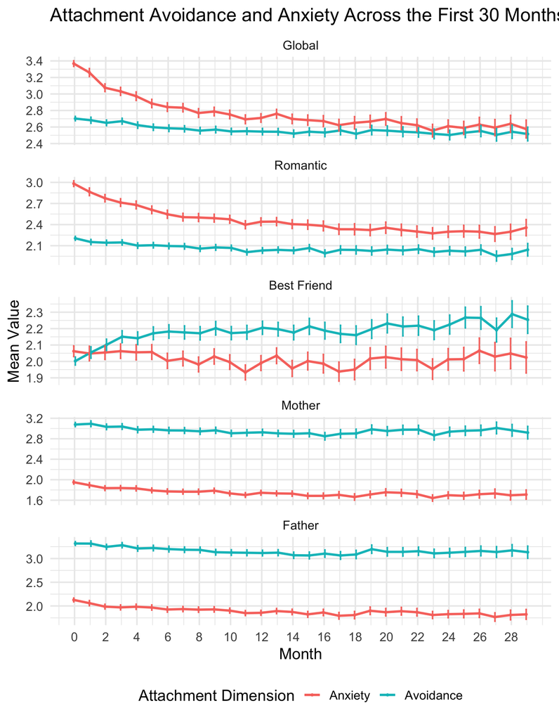

```r
ggplot(summary_attach,
       aes(x = time_month_rd, y = mean_val, color = type, group = type)) +
  geom_line(size = 1, position = position_dodge(width = 0.2)) +
  geom_point(size = 0.5, position = position_dodge(width = 0.2)) +
  geom_errorbar(aes(ymin = ci_lower, ymax = ci_upper), width = 0.2, position = position_dodge(width = 0.2)) +
  facet_wrap(~ construct, ncol = 1, scales = "free_y") +
  scale_x_continuous(breaks = seq(0, 29, 2)) +
  labs(
    title = "Attachment Avoidance and Anxiety Across the First 30 Months",
    x = "Month",
    y = "Mean Value",
    color = "Attachment Dimension"
  ) +
  theme_minimal(base_size = 14) +
  theme(legend.position = "bottom") +
  guides(color = guide_legend(ncol = 2))
```

Confidence intervals are difficult to see in this view but they are there…

#### 3.2.6.1 Group comparisons

But now separately for avoidance and anxiety (otherwise too difficult to see)

Show plot - avoidance:

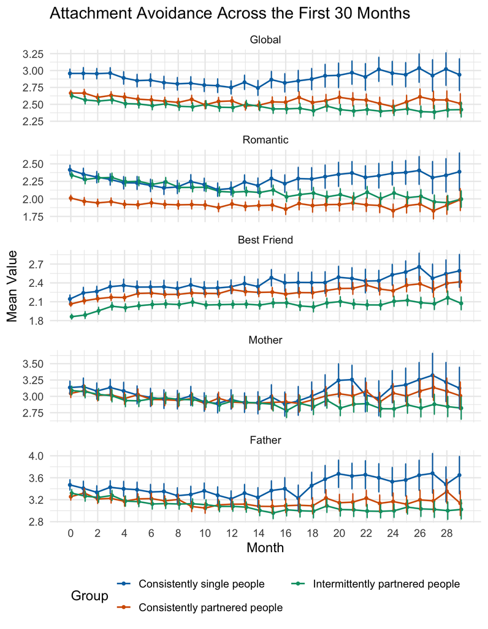

```r
ggplot(summary_attach_group %>% filter(type=="Avoidance"),
       aes(x = time_month_rd, y = mean_val, color = group_fct, group = group_fct)) +
  geom_line(size = 0.75, position = position_dodge(width = 0.2)) +
  geom_point(size = 1.1, position = position_dodge(width = 0.2)) +
  geom_errorbar(aes(ymin = ci_lower, ymax = ci_upper), width = 0.2, position = position_dodge(width = 0.2)) +
  facet_wrap(~ construct, ncol = 1, scales = "free_y") +
  scale_x_continuous(breaks = seq(0, 29, 2)) +
  scale_color_manual(values = c("#0072B2", "#D55E00", "#009E73", "#CC79A7", "#56B4E9", "#E69F00")) +
  labs(
    title = "Attachment Avoidance Across the First 30 Months",
    x = "Month",
    y = "Mean Value",
    color = "Group"
  ) +
  theme_minimal(base_size = 14) +
  theme(legend.position = "bottom") +
  guides(color = guide_legend(ncol = 2))
```

Show plot - anxiety:

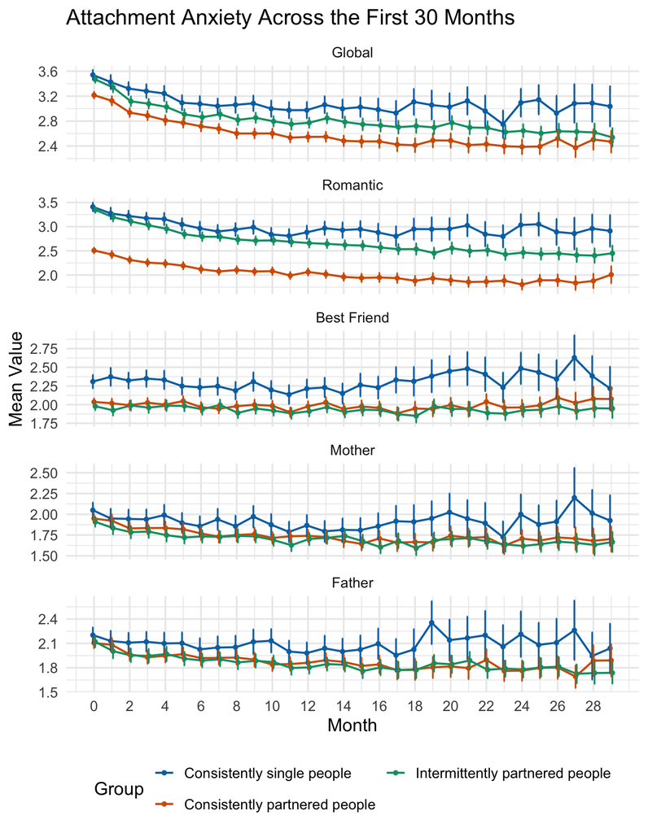

```r
ggplot(summary_attach_group %>% filter(type=="Anxiety"),
       aes(x = time_month_rd, y = mean_val, color = group_fct, group = group_fct)) +
  geom_line(size = 0.75, position = position_dodge(width = 0.2)) +
  geom_point(size = 1.1, position = position_dodge(width = 0.2)) +
  geom_errorbar(aes(ymin = ci_lower, ymax = ci_upper), width = 0.2, position = position_dodge(width = 0.2)) +
  facet_wrap(~ construct, ncol = 1, scales = "free_y") +
  scale_x_continuous(breaks = seq(0, 29, 2)) +
  scale_color_manual(values = c("#0072B2", "#D55E00", "#009E73", "#CC79A7", "#56B4E9", "#E69F00")) +
  labs(
    title = "Attachment Anxiety Across the First 30 Months",
    x = "Month",
    y = "Mean Value",
    color = "Group"
  ) +
  theme_minimal(base_size = 14) +
  theme(legend.position = "bottom") +
  guides(color = guide_legend(ncol = 2))
```

### 3.2.7 Attrition analyses

#### 3.2.7.1 Baseline predictors of study progress/completion

Reaching 12 / 24 months in the survey

Create df:

```r
df_completion <- df_atta %>%
  group_by(pid) %>%
  summarise(last_month = max(time_month_rd, na.rm = TRUE),
            completed_12m = as.integer(last_month >= 12),
            completed_24m = as.integer(last_month >= 24))

table(df_completion$completed_12m)
```

```
   0    1
 749 2793
```

```r
prop.table(table(df_completion$completed_12m))
```

```
        0         1
0.2114625 0.7885375
```

```r
table(df_completion$completed_24m)
```

```
   0    1
2370 1172
```

```r
prop.table(table(df_completion$completed_24m))
```

```
        0         1
0.6691135 0.3308865
```

```r
# Merge with baseline variables
df_baseline <- df_atta %>%
  filter(time_month_rd == 0) %>%
  left_join(df_completion, by = "pid")
```

Run models (12 months):

```r
preds <- c(
  "single_consist", "partner_consist",
  "age_base", "man",
  "avoi_glo", "avoi_mot", "avoi_fat", "avoi_rom", "avoi_fri",
  "anxi_glo", "anxi_mot", "anxi_fat", "anxi_rom", "anxi_fri",
  "swb"
)

# Fit all univariate models
uni_results_12 <- map_dfr(preds, function(x){

  fit <- glm(
    reformulate(x, response = "completed_12m"),
    family = binomial,
    data = df_baseline)

  tidy(fit, conf.int = TRUE, exponentiate = TRUE) %>%
    filter(term != "(Intercept)") %>%
    mutate(predictor = x)
})

# Fit the joint model
joint_fit_12 <- glm(
  reformulate(preds, response = "completed_12m"),
  family = binomial,
  data = df_baseline)

joint_results_12 <-
  tidy(joint_fit_12, conf.int = TRUE, exponentiate = TRUE) %>%
  filter(term != "(Intercept)")
```

Show results (12 months):

```r
results_12 <- uni_results_12 %>%
  select(predictor,
         uni_OR = estimate,
         uni_low = conf.low,
         uni_high = conf.high,
         uni_p = p.value) %>%
  left_join(
    joint_results_12 %>%
      select(term,
             joint_OR = estimate,
             joint_low = conf.low,
             joint_high = conf.high,
             joint_p = p.value),
    by = c("predictor" = "term"))

results_12 <- results_12 %>%
  mutate(
    `Univariate OR (95% CI)` =
      sprintf("%.2f (%.2f, %.2f)", uni_OR, uni_low, uni_high),

    `Joint OR (95% CI)` =
      sprintf("%.2f (%.2f, %.2f)", joint_OR, joint_low, joint_high),

    `Univariate p` = scales::pvalue(uni_p),
    `Joint p` = scales::pvalue(joint_p)) %>%
  select(
    Predictor = predictor,
    `Univariate OR (95% CI)`,
    `Univariate p`,
    `Joint OR (95% CI)`,
    `Joint p`)

knitr::kable(
  results_12,
  align = c("l", "c", "c", "c", "c"),
  caption = "Baseline predictors of completing the 12-month assessment."
)
```

Baseline predictors of completing the 12-month assessment.

| Predictor | Univariate OR (95% CI) | Univariate p | Joint OR (95% CI) | Joint p |
| --- | --- | --- | --- | --- |
| single_consist | 0.68 (0.56, 0.83) | <0.001 | 0.44 (0.33, 0.58) | <0.001 |
| partner_consist | 0.62 (0.52, 0.73) | <0.001 | 0.41 (0.32, 0.52) | <0.001 |
| age_base | 1.00 (0.99, 1.01) | 0.792 | 1.00 (0.99, 1.01) | 0.705 |
| man | 0.90 (0.73, 1.11) | 0.313 | 0.83 (0.65, 1.07) | 0.148 |
| avoi_glo | 0.96 (0.87, 1.05) | 0.362 | 0.92 (0.79, 1.08) | 0.311 |
| avoi_mot | 0.99 (0.92, 1.06) | 0.752 | 1.05 (0.94, 1.17) | 0.429 |
| avoi_fat | 1.01 (0.93, 1.10) | 0.776 | 1.05 (0.94, 1.18) | 0.394 |
| avoi_rom | 1.07 (0.97, 1.18) | 0.178 | 1.10 (0.95, 1.27) | 0.226 |
| avoi_fri | 0.96 (0.86, 1.07) | 0.464 | 1.07 (0.91, 1.26) | 0.420 |
| anxi_glo | 0.95 (0.88, 1.03) | 0.193 | 1.00 (0.88, 1.14) | 0.980 |
| anxi_mot | 0.91 (0.84, 0.98) | 0.016 | 0.87 (0.77, 0.99) | 0.037 |
| anxi_fat | 0.97 (0.90, 1.05) | 0.478 | 1.02 (0.90, 1.15) | 0.765 |
| anxi_rom | 1.01 (0.94, 1.07) | 0.853 | 0.93 (0.83, 1.04) | 0.213 |
| anxi_fri | 0.96 (0.89, 1.04) | 0.316 | 1.02 (0.90, 1.15) | 0.740 |
| swb | 1.10 (1.01, 1.21) | 0.037 | 1.14 (1.00, 1.29) | 0.048 |

Run models (24 months):

```r
# Fit all univariate models
uni_results_24 <- map_dfr(preds, function(x){

  fit <- glm(
    reformulate(x, response = "completed_24m"),
    family = binomial,
    data = df_baseline)

  tidy(fit, conf.int = TRUE, exponentiate = TRUE) %>%
    filter(term != "(Intercept)") %>%
    mutate(predictor = x)
})

# Fit the joint model
joint_fit_24 <- glm(
  reformulate(preds, response = "completed_24m"),
  family = binomial,
  data = df_baseline)

joint_results_24 <-
  tidy(joint_fit_24, conf.int = TRUE, exponentiate = TRUE) %>%
  filter(term != "(Intercept)")
```

Show results (24 months):

```r
results_24 <- uni_results_24 %>%
  select(predictor,
         uni_OR = estimate,
         uni_low = conf.low,
         uni_high = conf.high,
         uni_p = p.value) %>%
  left_join(
    joint_results_24 %>%
      select(term,
             joint_OR = estimate,
             joint_low = conf.low,
             joint_high = conf.high,
             joint_p = p.value),
    by = c("predictor" = "term"))

results_24 <- results_24 %>%
  mutate(
    `Univariate OR (95% CI)` =
      sprintf("%.2f (%.2f, %.2f)", uni_OR, uni_low, uni_high),

    `Joint OR (95% CI)` =
      sprintf("%.2f (%.2f, %.2f)", joint_OR, joint_low, joint_high),

    `Univariate p` = scales::pvalue(uni_p),
    `Joint p` = scales::pvalue(joint_p)) %>%
  select(
    Predictor = predictor,
    `Univariate OR (95% CI)`,
    `Univariate p`,
    `Joint OR (95% CI)`,
    `Joint p`)

knitr::kable(
  results_24,
  align = c("l", "c", "c", "c", "c"),
  caption = "Baseline predictors of completing the 24-month assessment."
)
```

Baseline predictors of completing the 24-month assessment.

| Predictor | Univariate OR (95% CI) | Univariate p | Joint OR (95% CI) | Joint p |
| --- | --- | --- | --- | --- |
| single_consist | 0.56 (0.46, 0.69) | <0.001 | 0.39 (0.30, 0.50) | <0.001 |
| partner_consist | 0.69 (0.60, 0.80) | <0.001 | 0.49 (0.40, 0.60) | <0.001 |
| age_base | 1.00 (1.00, 1.01) | 0.462 | 0.99 (0.98, 1.00) | 0.283 |
| man | 0.91 (0.76, 1.10) | 0.343 | 0.89 (0.71, 1.11) | 0.305 |
| avoi_glo | 1.02 (0.93, 1.11) | 0.702 | 1.04 (0.91, 1.19) | 0.578 |
| avoi_mot | 1.02 (0.95, 1.08) | 0.636 | 0.98 (0.90, 1.08) | 0.746 |
| avoi_fat | 0.99 (0.93, 1.06) | 0.834 | 0.99 (0.90, 1.10) | 0.859 |
| avoi_rom | 1.09 (1.00, 1.19) | 0.042 | 1.05 (0.93, 1.19) | 0.452 |
| avoi_fri | 1.04 (0.95, 1.14) | 0.407 | 1.15 (1.00, 1.33) | 0.050 |
| anxi_glo | 0.95 (0.89, 1.02) | 0.141 | 1.00 (0.89, 1.12) | 0.991 |
| anxi_mot | 0.99 (0.92, 1.06) | 0.745 | 1.02 (0.91, 1.14) | 0.717 |
| anxi_fat | 0.97 (0.91, 1.04) | 0.475 | 0.97 (0.87, 1.08) | 0.548 |
| anxi_rom | 0.96 (0.91, 1.02) | 0.179 | 0.91 (0.83, 1.00) | 0.045 |
| anxi_fri | 0.97 (0.90, 1.04) | 0.415 | 0.99 (0.89, 1.10) | 0.848 |
| swb | 1.03 (0.95, 1.11) | 0.518 | 0.99 (0.89, 1.11) | 0.885 |

Comparison/reference group here are the intermittently partnered people (who have a much higher likelihood of study completion!). Other variables don’t seem to matter much.

#### 3.2.7.2 Number of completed assessments

Create df:

```r
# number of completed assessments
df_nassess <- df_atta %>%
  group_by(pid) %>%
  summarise(n_assess = n(),
            .groups = "drop")

# Merge with baseline
df_baseline_compl <- df_atta %>%
  filter(time_month_rd == 0) %>%
  left_join(df_nassess, by = "pid")
```

Run models:

```r
# univariate models
uni_results_compl <- map_dfr(preds, \(x){

  fit <- lm(
    reformulate(x, response = "n_assess"),
    data = df_baseline_compl
  )

  tidy(fit, conf.int = TRUE) %>%
    filter(term != "(Intercept)") %>%
    mutate(predictor = x)
})

# Joint model
joint_fit_compl <- lm(
  reformulate(preds, response = "n_assess"),
  data = df_baseline_compl
)

joint_results_compl <- tidy(joint_fit_compl, conf.int = TRUE) %>%
  filter(term != "(Intercept)")
```

Merge and show as table:

```r
results_compl <- uni_results_compl %>%
  select(predictor,
         uni_b = estimate,
         uni_low = conf.low,
         uni_high = conf.high,
         uni_p = p.value) %>%
  left_join(
    joint_results_compl %>%
      select(term,
             joint_b = estimate,
             joint_low = conf.low,
             joint_high = conf.high,
             joint_p = p.value),
    by = c("predictor" = "term")
  )

results_compl <- results_compl %>%
  mutate(
    `Univariate b (95% CI)` =
      sprintf("%.2f (%.2f, %.2f)", uni_b, uni_low, uni_high),

    `Joint b (95% CI)` =
      sprintf("%.2f (%.2f, %.2f)", joint_b, joint_low, joint_high),

    `Univariate p` = scales::pvalue(uni_p),
    `Joint p` = scales::pvalue(joint_p)
  ) %>%
  select(
    Predictor = predictor,
    `Univariate b (95% CI)`,
    `Univariate p`,
    `Joint b (95% CI)`,
    `Joint p`
  )

knitr::kable(results_compl)
```

| Predictor | Univariate b (95% CI) | Univariate p | Joint b (95% CI) | Joint p |
| --- | --- | --- | --- | --- |
| single_consist | -0.99 (-1.47, -0.50) | <0.001 | -2.32 (-2.94, -1.71) | <0.001 |
| partner_consist | -1.62 (-1.98, -1.25) | <0.001 | -2.60 (-3.11, -2.10) | <0.001 |
| age_base | -0.02 (-0.04, -0.01) | 0.009 | -0.03 (-0.06, -0.01) | 0.007 |
| man | -0.08 (-0.57, 0.40) | 0.738 | -0.42 (-0.99, 0.15) | 0.148 |
| avoi_glo | 0.08 (-0.15, 0.31) | 0.487 | -0.05 (-0.39, 0.30) | 0.795 |
| avoi_mot | 0.11 (-0.06, 0.28) | 0.189 | 0.27 (0.03, 0.51) | 0.027 |
| avoi_fat | 0.04 (-0.15, 0.22) | 0.692 | 0.00 (-0.25, 0.26) | 0.989 |
| avoi_rom | 0.14 (-0.08, 0.36) | 0.213 | 0.08 (-0.24, 0.40) | 0.634 |
| avoi_fri | 0.23 (-0.02, 0.47) | 0.074 | 0.50 (0.14, 0.86) | 0.006 |
| anxi_glo | -0.11 (-0.28, 0.07) | 0.235 | 0.08 (-0.21, 0.37) | 0.602 |
| anxi_mot | -0.23 (-0.42, -0.04) | 0.016 | -0.36 (-0.65, -0.07) | 0.015 |
| anxi_fat | -0.14 (-0.32, 0.05) | 0.142 | 0.03 (-0.24, 0.29) | 0.834 |
| anxi_rom | -0.08 (-0.23, 0.07) | 0.301 | -0.33 (-0.57, -0.09) | 0.008 |
| anxi_fri | -0.07 (-0.26, 0.12) | 0.473 | -0.07 (-0.34, 0.20) | 0.593 |
| swb | 0.17 (-0.04, 0.39) | 0.105 | 0.14 (-0.14, 0.42) | 0.329 |

Comparison/reference group here are the intermittently partnered people (who completed more waves!). Similar picture here compared to reaching 12/24 month mark. In addition, younger people seemed to have completed more total waves.

#### 3.2.7.3 Proportion of missingness over time

Check missingness proportions over time:

(These are very similar across the different outcomes - doesn’t really matter which one I look at!)

```r
df_attrition <- df_atta_wide %>%
  select(starts_with("avoi_glo_t")) %>%
  pivot_longer(
    cols = everything(),
    names_to = "month",
    names_pattern = "avoi_glo_t(\\d+)",
    values_to = "value"
  ) %>%
  mutate(month = as.integer(month))

missing_summary <- df_attrition %>%
  group_by(month) %>%
  summarise(
    prop_missing = mean(is.na(value)),
    n_available = sum(!is.na(value)),
    n_total = n(),
    .groups = "drop"
  )
```

Show plot:

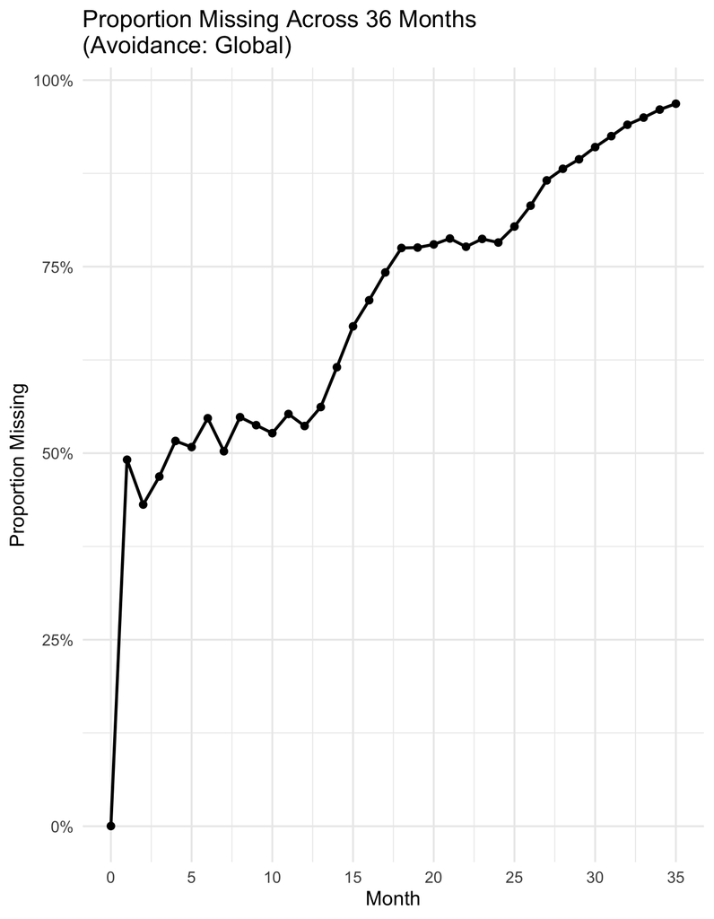

```r
ggplot(missing_summary, aes(x = month, y = prop_missing)) +
  geom_line(size = 1) +
  geom_point(size = 2) +
  scale_y_continuous(labels = scales::percent) +
  scale_x_continuous(breaks = seq(0, 35, 5)) +
  labs(
    title = "Proportion Missing Across 36 Months\n(Avoidance: Global)",
    x = "Month",
    y = "Proportion Missing"
  ) +
  theme_minimal(base_size = 14)
```

This proportion doesn’t increase consistently because this reflects the underlying time rounded to the next full month. Some participants delayed their responses and did not fully follow the once-per-month 24-month schedule.

# 4 Confirmatory analyses

## 4.1 RQ1: Prospective Selection Effects

From prereg: “In the sample of single people at baseline, we will run logistic regression models (with a logit link function) with consistent singlehood (0 = no, initially single but later find partner, 1 = yes, consistently single) as the outcome and both attachment anxiety and avoidance as predictors, which will be z-standardized. We will also include age and gender as control variables. Thus, we will run joint models for anxiety and avoidance but separate models for global attachment and each domain of attachment (i.e., in total 5 models with different attachment domains).”

Logistic regression = pure between-person comparison

```r
table(df_atta_rq1$single_consist, useNA = "always")
```

```
   0    1 <NA>
 730  623    0
```

```r
# few more missings in gender & age:
summary(df_atta_rq1$age_base)
```

```
   Min. 1st Qu.  Median    Mean 3rd Qu.    Max.     NAs
  14.00   24.00   30.00   32.79   40.00   82.00       1
```

```r
table(df_atta_rq1$man, useNA = "always")
```

```
   0    1 <NA>
1083  267    3
```

### 4.1.1 Global attachment

```r
formula_sel_glo <- as.formula(
  paste("single_consist", "~", paste(c("avoi_glo_z", "anxi_glo_z", "age_base", "man"), collapse = " + ")))

print(formula_sel_glo)
```

```
single_consist ~ avoi_glo_z + anxi_glo_z + age_base + man
```

```r
sel_glo <- glm(formula_sel_glo,
                   family = binomial(link='logit'), data = df_atta_rq1)
summary(sel_glo)
```

```
Call:
glm(formula = formula_sel_glo, family = binomial(link = "logit"),
    data = df_atta_rq1)

Coefficients:
             Estimate Std. Error z value Pr(>|z|)
(Intercept) -0.962734   0.172610  -5.578 2.44e-08 ***
avoi_glo_z   0.430681   0.059458   7.243 4.37e-13 ***
anxi_glo_z   0.012976   0.058125   0.223    0.823
age_base     0.023601   0.004876   4.841 1.30e-06 ***
man          0.108415   0.141866   0.764    0.445
---
Signif. codes:  0 '***' 0.001 '**' 0.01 '*' 0.05 '.' 0.1 ' ' 1

(Dispersion parameter for binomial family taken to be 1)

    Null deviance: 1861.6  on 1348  degrees of freedom
Residual deviance: 1783.7  on 1344  degrees of freedom
  (4 observations deleted due to missingness)
AIC: 1793.7

Number of Fisher Scoring iterations: 4
```

### 4.1.2 Romantic attachment

```r
formula_sel_rom <- as.formula(
  paste("single_consist", "~", paste(c("avoi_rom_z", "anxi_rom_z", "age_base", "man"), collapse = " + ")))

print(formula_sel_rom)
```

```
single_consist ~ avoi_rom_z + anxi_rom_z + age_base + man
```

```r
sel_rom <- glm(formula_sel_rom,
                   family = binomial(link='logit'), data = df_atta_rq1)
summary(sel_rom)
```

```
Call:
glm(formula = formula_sel_rom, family = binomial(link = "logit"),
    data = df_atta_rq1)

Coefficients:
             Estimate Std. Error z value Pr(>|z|)
(Intercept) -0.808093   0.168452  -4.797 1.61e-06 ***
avoi_rom_z   0.161394   0.059153   2.728  0.00636 **
anxi_rom_z  -0.035455   0.058970  -0.601  0.54768
age_base     0.019057   0.004764   4.000 6.32e-05 ***
man          0.110333   0.138955   0.794  0.42718
---
Signif. codes:  0 '***' 0.001 '**' 0.01 '*' 0.05 '.' 0.1 ' ' 1

(Dispersion parameter for binomial family taken to be 1)

    Null deviance: 1861.6  on 1348  degrees of freedom
Residual deviance: 1834.7  on 1344  degrees of freedom
  (4 observations deleted due to missingness)
AIC: 1844.7

Number of Fisher Scoring iterations: 4
```

### 4.1.3 (Best) Friend-specific attachment

```r
formula_sel_fri <- as.formula(
  paste("single_consist", "~", paste(c("avoi_fri_z", "anxi_fri_z", "age_base", "man"), collapse = " + ")))

print(formula_sel_fri)
```

```
single_consist ~ avoi_fri_z + anxi_fri_z + age_base + man
```

```r
sel_fri <- glm(formula_sel_fri,
                   family = binomial(link='logit'), data = df_atta_rq1)
summary(sel_fri)
```

```
Call:
glm(formula = formula_sel_fri, family = binomial(link = "logit"),
    data = df_atta_rq1)

Coefficients:
             Estimate Std. Error z value Pr(>|z|)
(Intercept) -0.909997   0.172369  -5.279 1.30e-07 ***
avoi_fri_z   0.317602   0.067023   4.739 2.15e-06 ***
anxi_fri_z   0.196619   0.065880   2.984  0.00284 **
age_base     0.022577   0.004887   4.620 3.84e-06 ***
man          0.050923   0.143061   0.356  0.72188
---
Signif. codes:  0 '***' 0.001 '**' 0.01 '*' 0.05 '.' 0.1 ' ' 1

(Dispersion parameter for binomial family taken to be 1)

    Null deviance: 1860.4  on 1347  degrees of freedom
Residual deviance: 1777.7  on 1343  degrees of freedom
  (5 observations deleted due to missingness)
AIC: 1787.7

Number of Fisher Scoring iterations: 4
```

### 4.1.4 Mother-specific attachment

```r
formula_sel_mot <- as.formula(
  paste("single_consist", "~", paste(c("avoi_mot_z", "anxi_mot_z", "age_base", "man"), collapse = " + ")))

print(formula_sel_mot)
```

```
single_consist ~ avoi_mot_z + anxi_mot_z + age_base + man
```

```r
sel_mot <- glm(formula_sel_mot,
                   family = binomial(link='logit'), data = df_atta_rq1)
summary(sel_mot)
```

```
Call:
glm(formula = formula_sel_mot, family = binomial(link = "logit"),
    data = df_atta_rq1)

Coefficients:
             Estimate Std. Error z value Pr(>|z|)
(Intercept) -0.463349   0.193061  -2.400  0.01639 *
avoi_mot_z  -0.086146   0.071592  -1.203  0.22887
anxi_mot_z   0.223209   0.072628   3.073  0.00212 **
age_base     0.006764   0.005853   1.156  0.24782
man          0.188334   0.146571   1.285  0.19882
---
Signif. codes:  0 '***' 0.001 '**' 0.01 '*' 0.05 '.' 0.1 ' ' 1

(Dispersion parameter for binomial family taken to be 1)

    Null deviance: 1671.8  on 1215  degrees of freedom
Residual deviance: 1658.6  on 1211  degrees of freedom
  (137 observations deleted due to missingness)
AIC: 1668.6

Number of Fisher Scoring iterations: 4
```

### 4.1.5 Father-specific attachment

```r
formula_sel_fat <- as.formula(
  paste("single_consist", "~", paste(c("avoi_fat_z", "anxi_fat_z", "age_base", "man"), collapse = " + ")))

print(formula_sel_fat)
```

```
single_consist ~ avoi_fat_z + anxi_fat_z + age_base + man
```

```r
sel_fat <- glm(formula_sel_fat,
                   family = binomial(link='logit'), data = df_atta_rq1)
summary(sel_fat)
```

```
Call:
glm(formula = formula_sel_fat, family = binomial(link = "logit"),
    data = df_atta_rq1)

Coefficients:
             Estimate Std. Error z value Pr(>|z|)
(Intercept) -0.570740   0.212942  -2.680  0.00736 **
avoi_fat_z   0.114691   0.072817   1.575  0.11524
anxi_fat_z   0.081424   0.072674   1.120  0.26254
age_base     0.008671   0.006654   1.303  0.19248
man          0.312719   0.155314   2.013  0.04407 *
---
Signif. codes:  0 '***' 0.001 '**' 0.01 '*' 0.05 '.' 0.1 ' ' 1

(Dispersion parameter for binomial family taken to be 1)

    Null deviance: 1510.9  on 1101  degrees of freedom
Residual deviance: 1498.0  on 1097  degrees of freedom
  (251 observations deleted due to missingness)
AIC: 1508

Number of Fisher Scoring iterations: 4
```

Note: In this case, the predictors are both significant in separate models (avoidance / anxiety).

### 4.1.6 Results table

Gather estimates:

```r
df_summa_sel_logist <- bind_rows(
  broom::tidy(sel_glo, conf.int = T, conf.level = .95, exponentiate = TRUE) %>% mutate(domain = "Global", n_obs = nobs(sel_glo)),
  broom::tidy(sel_rom, conf.int = T, conf.level = .95, exponentiate = TRUE) %>% mutate(domain = "Romantic", n_obs = nobs(sel_rom)),
  broom::tidy(sel_fri, conf.int = T, conf.level = .95, exponentiate = TRUE) %>% mutate(domain = "Best Friend", n_obs = nobs(sel_fri)),
  broom::tidy(sel_mot, conf.int = T, conf.level = .95, exponentiate = TRUE) %>% mutate(domain = "Mother", n_obs = nobs(sel_mot)),
  broom::tidy(sel_fat, conf.int = T, conf.level = .95, exponentiate = TRUE) %>% mutate(domain = "Father", n_obs = nobs(sel_fat)))

df_summa_sel_logist <- df_summa_sel_logist %>%
  mutate(domain_fct = factor(domain,
                             levels = c("Global", "Romantic", "Best Friend", "Mother", "Father"),
                             labels = c("Global", "Romantic", "Best Friend", "Mother", "Father"), ordered = TRUE))
```

```r
df_summa_sel_logist %>%
  filter(term %in% c("avoi_glo_z", "anxi_glo_z",
                     "avoi_rom_z", "anxi_rom_z",
                     "avoi_fri_z", "anxi_fri_z",
                     "avoi_mot_z", "anxi_mot_z",
                     "avoi_fat_z", "anxi_fat_z")) %>%
  mutate(OR = estimate,
    CI_low = conf.low,
    CI_high = conf.high,
    pred = case_when(
      grepl("avoi", term) ~ "Avoidance",
      grepl("anxi", term) ~ "Anxiety"),
    `OR (95% CI)` = sprintf("%.2f (%.2f, %.2f)", OR, CI_low, CI_high),
    p = format.pval(p.value, digits = 3, eps = .001)) %>%
  select(domain, pred, `OR (95% CI)`, p, n_obs) %>%
  arrange(factor(domain, levels = c("Global", "Romantic", "Best Friend", "Mother", "Father")),
          pred) %>%
  kable()
```

| domain | pred | OR (95% CI) | p | n_obs |
| --- | --- | --- | --- | --- |
| Global | Anxiety | 1.01 (0.90, 1.14) | 0.823 | 1349 |
| Global | Avoidance | 1.54 (1.37, 1.73) | <0.001 | 1349 |
| Romantic | Anxiety | 0.97 (0.86, 1.08) | 0.548 | 1349 |
| Romantic | Avoidance | 1.18 (1.05, 1.32) | 0.006 | 1349 |
| Best Friend | Anxiety | 1.22 (1.07, 1.39) | 0.003 | 1348 |
| Best Friend | Avoidance | 1.37 (1.21, 1.57) | <0.001 | 1348 |
| Mother | Anxiety | 1.25 (1.08, 1.44) | 0.002 | 1216 |
| Mother | Avoidance | 0.92 (0.80, 1.06) | 0.229 | 1216 |
| Father | Anxiety | 1.08 (0.94, 1.25) | 0.263 | 1102 |
| Father | Avoidance | 1.12 (0.97, 1.29) | 0.115 | 1102 |

### 4.1.7 Summary plot

Create plots for manuscript: start with extracting the parameters

```r
# Prepare RQ1 forest-plot df
rq1_plot_df <- df_summa_sel_logist %>%
  filter(term %in% c("anxi_glo_z", "avoi_glo_z", "anxi_rom_z", "avoi_rom_z",
                     "anxi_fri_z", "avoi_fri_z", "anxi_mot_z", "avoi_mot_z",
                     "anxi_fat_z", "avoi_fat_z")) %>%
  mutate(pred_fct = factor(if_else(str_detect(term, "^anxi"), "Anxiety", "Avoidance"),
                           levels = c("Avoidance", "Anxiety"), labels = c("Avoidance", "Anxiety"), ordered = T))
```

Create and save plot:

```r
# for alternating background color:
bg_df_rq1 <- data.frame(
  ymin = seq(0.5, 4.5, by = 1),
  ymax = seq(1.5, 5.5, by = 1),
  fill = rep(c("white", "grey90"), length.out = 5))

# Forest plot with reversed display order
plot_rq1_or <- ggplot(rq1_plot_df, aes(x = estimate,
                                                y = forcats::fct_rev(domain_fct),
                                                colour = forcats::fct_rev(pred_fct),
                                                shape = forcats::fct_rev(pred_fct))) +
  geom_rect(data = bg_df_rq1,
            aes(xmin = -Inf, xmax = Inf, ymin = ymin, ymax = ymax),
            inherit.aes = FALSE,
            fill = bg_df_rq1$fill,
            alpha = 0.5) +
  geom_vline(xintercept = 1, colour = "black") +
  geom_point(size = 2.5, position = position_dodge(width = 0.6)) +
  geom_errorbarh(aes(xmin = conf.low, xmax = conf.high),
                 height = 0.3, position = position_dodge(width = 0.6),
                 linewidth = 0.3, alpha = 0.85) +
  scale_colour_manual(values = c("Avoidance" = "#D55E00", "Anxiety" = "#0072B2"),
                      breaks = c("Avoidance", "Anxiety")) +
  scale_shape_manual(values = c("Avoidance" = 17, "Anxiety" = 16),
                     breaks = c("Avoidance", "Anxiety")) +
  scale_x_continuous(limits = c(0.75, 1.80), breaks = seq(0.75, 1.75, by = 0.25), oob = scales::oob_keep) +
  labs(x = "Odds Ratio (95% CI)", y = NULL, colour = NULL, shape = NULL) +
  theme_bw() +
  theme(legend.position = "bottom",
        legend.key.width = unit(1.3, "cm"),
        panel.grid.major.y = element_blank(), panel.grid.minor.y = element_blank(),
        panel.grid.major.x = element_line(color = "grey80", linewidth = 0.3), panel.grid.minor.x = element_blank()) +
  guides(colour = guide_legend(title = "Predictor"),
         shape = guide_legend(title = "Predictor"))

# save as pdf
pdf(width = 6, height = 4.5, "figures/rq1_plot_or.pdf")
plot_rq1_or
dev.off()
```

Show plot:

```
`height` was translated to `width`.
```

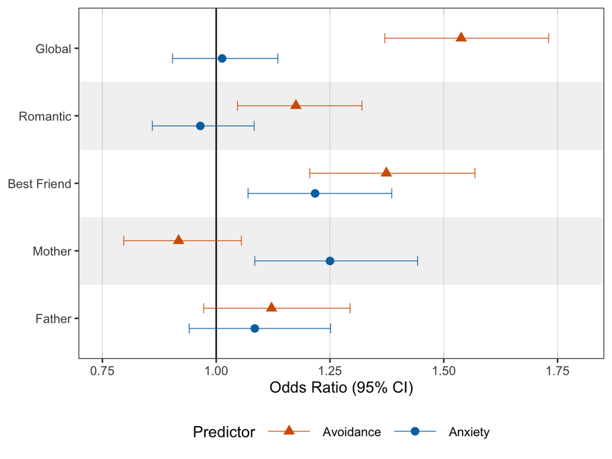

```r
plot_rq1_or
```

Hypothesis confirmed for global and romantic avoidance, but n.s. for anxiety (which is also the case in single-predictor models): With higher global and romantic attachment avoidance, single people (at baseline) were more likely to remain single consistently throughout the observation period.  
In addition:  
- With higher friend-specific avoidance and anxiety, people were more likely to remain single.  
- With higher mother-specific anxiety, people were more likely to remain single (but n.s. for avoidance).

## 4.2 RQ2: Changes in Attachment Models

From prereg: “To trace mean-level change in attachment across time, we will run univariate latent growth curve models based on manifest mean scale scores. We will start with separate models in each analysis group (consistently single, consistently partnered, intermittently partnered) and then extend those to multi-group models comparing consistently single people to each of the partnered groups.”

“The linear growth variable will be time at assessment (i.e., months centered at study entry). We run separate models for attachment anxiety and avoidance and for global attachment and each domain (2 x 5 attachment outcomes for each group comparison).”

I’m doing the main models for all attachment domains in this section even though we only investigate global and romantic as confirmatory and the rest as exploratory. However, the entirely exploratory comparison of consistently single people and intermittently partnered individuals will follow below in the next section (5).

### 4.2.1 Example model

I’m first creating a template and show this with an example model of global avoidance (in singles, and then extended to single-partnered comparison). Below, I loop through all outcomes using the template.

#### 4.2.1.1 Single-group models

Specify model template, and show example model output:

```r
# latent growth curve model: only 1 group
# Define number of assessment waves
n_waves <- 30  # t00 to t29

# Create variable names
times <- sprintf("%02d", 0:(n_waves - 1))
outcome_vars <- paste0("outcome_t", times)

# Intercept loadings
i_loadings <- paste0("1*", outcome_vars, collapse = " + ")

# Slope loadings (scaled 0 to 1)
s_values <- seq(0, 1, length.out = n_waves)
s_loadings <- paste0(round(s_values, 5), "*", outcome_vars, collapse = " + ")

# Residual variance labels
residuals <- paste0(outcome_vars, " ~~ res_", times, "*", outcome_vars, collapse = "\n")

# For plotting: Model-implied trajectory parameters (assuming age_base_z = 0, i.e., sample-average baseline age)
trajectory_estimates <- paste0("pred_t", times, " := a0 + a1*", round(s_values, 5), collapse = "\n")

# LGCM template
rq2_template <- paste0('
# Define intercept and slope factors
i =~ ', i_loadings, '

s =~ ', s_loadings, '

# Regress latent growth factors on baseline age
i ~ bi*age_base_z
s ~ bs*age_base_z

# Mean structure
i ~ a0*1
s ~ a1*1

# Variance structure
i ~~ vi*i
s ~~ vs*s
i ~~ cis*s

# Model-implied trajectories (for plotting)
', trajectory_estimates, '

# Residual variances
', residuals, '
')

# show the template:
cat(rq2_template)
```

```
# Define intercept and slope factors
i =~ 1*outcome_t00 + 1*outcome_t01 + 1*outcome_t02 + 1*outcome_t03 + 1*outcome_t04 + 1*outcome_t05 + 1*outcome_t06 + 1*outcome_t07 + 1*outcome_t08 + 1*outcome_t09 + 1*outcome_t10 + 1*outcome_t11 + 1*outcome_t12 + 1*outcome_t13 + 1*outcome_t14 + 1*outcome_t15 + 1*outcome_t16 + 1*outcome_t17 + 1*outco…

s =~ 0*outcome_t00 + 0.03448*outcome_t01 + 0.06897*outcome_t02 + 0.10345*outcome_t03 + 0.13793*outcome_t04 + 0.17241*outcome_t05 + 0.2069*outcome_t06 + 0.24138*outcome_t07 + 0.27586*outcome_t08 + 0.31034*outcome_t09 + 0.34483*outcome_t10 + 0.37931*outcome_t11 + 0.41379*outcome_t12 + 0.44828*outcome_…

# Regress latent growth factors on baseline age
i ~ bi*age_base_z
s ~ bs*age_base_z

# Mean structure
i ~ a0*1
s ~ a1*1

# Variance structure
i ~~ vi*i
s ~~ vs*s
i ~~ cis*s

# Model-implied trajectories (for plotting)
pred_t00 := a0 + a1*0
pred_t01 := a0 + a1*0.03448
pred_t02 := a0 + a1*0.06897
pred_t03 := a0 + a1*0.10345
pred_t04 := a0 + a1*0.13793
pred_t05 := a0 + a1*0.17241
pred_t06 := a0 + a1*0.2069
pred_t07 := a0 + a1*0.24138
pred_t08 := a0 + a1*0.27586
pred_t09 := a0 + a1*0.31034
pred_t10 := a0 + a1*0.34483
pred_t11 := a0 + a1*0.37931
pred_t12 := a0 + a1*0.41379
pred_t13 := a0 + a1*0.44828
pred_t14 := a0 + a1*0.48276
pred_t15 := a0 + a1*0.51724
pred_t16 := a0 + a1*0.55172
pred_t17 := a0 + a1*0.58621
pred_t18 := a0 + a1*0.62069
pred_t19 := a0 + a1*0.65517
pred_t20 := a0 + a1*0.68966
```

[output cut: 26 more lines]

```
outcome_t15 ~~ res_15*outcome_t15
outcome_t16 ~~ res_16*outcome_t16
outcome_t17 ~~ res_17*outcome_t17
outcome_t18 ~~ res_18*outcome_t18
outcome_t19 ~~ res_19*outcome_t19
outcome_t20 ~~ res_20*outcome_t20
outcome_t21 ~~ res_21*outcome_t21
outcome_t22 ~~ res_22*outcome_t22
outcome_t23 ~~ res_23*outcome_t23
outcome_t24 ~~ res_24*outcome_t24
outcome_t25 ~~ res_25*outcome_t25
outcome_t26 ~~ res_26*outcome_t26
outcome_t27 ~~ res_27*outcome_t27
outcome_t28 ~~ res_28*outcome_t28
outcome_t29 ~~ res_29*outcome_t29
```

```r
# example model with global avoidance
model_rq2_avoi_glo_example <- stringr::str_replace_all(rq2_template, "outcome", "avoi_glo")

# fit the models - 1 model for single, 1 for partnered
fit_rq2_avoi_glo_example <- lavaan::growth(model_rq2_avoi_glo_example, data = df_atta_wide_single_c,
                                           missing = "fiml",
                                           em.h1.args = list(max_iter = 5000), # to increase chance that H1 EM algorithm converges properly
                                           verbose = FALSE)
summary(fit_rq2_avoi_glo_example, fit.measures = TRUE, standardized = TRUE, ci = FALSE)
```

```
Warning in pchisq(x2, df = df, ncp = ncp): NaNs produced
```

```
Warning in pchisq(x2, df = df, ncp = ncp): NaNs produced
```

```
lavaan 0.7-2 ended normally after 53 iterations

  Estimator                                         ML
  Optimization method                           NLMINB
  Number of model parameters                        37

                                                  Used       Total
  Number of observations                           622         623
  Number of missing patterns                       544

Model Test User Model:

  Test statistic                              1136.972
  Degrees of freedom                               488
  P-value (Chi-square)                           0.000

Model Test Baseline Model:

  Test statistic                              8884.860
  Degrees of freedom                               465
  P-value                                        0.000

User Model versus Baseline Model:

  Comparative Fit Index (CFI)                    0.923
  Tucker-Lewis Index (TLI)                       0.927

  Robust Comparative Fit Index (CFI)             0.000
  Robust Tucker-Lewis Index (TLI)               -0.095

Loglikelihood and Information Criteria:

  Loglikelihood user model (H0)              -3899.912
  Loglikelihood unrestricted model (H1)      -3331.426

  Akaike (AIC)                                7873.824
  Bayesian (BIC)                              8037.842
  Sample-size adjusted Bayesian (SABIC)       7920.373

Root Mean Square Error of Approximation:
```

[output cut: 167 more lines]

```
    pred_t15          2.767    0.033   84.593    0.000    3.907    3.907
    pred_t16          2.755    0.033   82.439    0.000    3.891    3.891
    pred_t17          2.743    0.034   80.257    0.000    3.875    3.875
    pred_t18          2.731    0.035   78.068    0.000    3.860    3.860
    pred_t19          2.720    0.036   75.886    0.000    3.844    3.844
    pred_t20          2.708    0.037   73.723    0.000    3.828    3.828
    pred_t21          2.696    0.038   71.593    0.000    3.812    3.812
    pred_t22          2.685    0.039   69.503    0.000    3.797    3.797
    pred_t23          2.673    0.040   67.459    0.000    3.781    3.781
    pred_t24          2.661    0.041   65.468    0.000    3.765    3.765
    pred_t25          2.649    0.042   63.533    0.000    3.749    3.749
    pred_t26          2.638    0.043   61.656    0.000    3.733    3.733
    pred_t27          2.626    0.044   59.840    0.000    3.718    3.718
    pred_t28          2.614    0.045   58.083    0.000    3.702    3.702
    pred_t29          2.602    0.046   56.388    0.000    3.686    3.686
```

A few warning messages appear:  
- 1 case is dropped because of a missing value in age. This is no problem -> N = 622 now. (as an exogenous variable, missingness in age is not handled with FIML)  
- Low coverage at later time points: this was to be expected, with increased dropout and up to 30 months of data (e.g., 84% missingness at t20, and 93% at t29). I think it’s no big issue here, given that the model still converged, produced no implausible estimates, and resulted in decent fit indices (at least in the traditional ones; some of the “robust” ones could not be estimated properly…)  
- EM estimated variance-covariance matrix (Sigma) is (near) singular: also not surprising given the data structure and missingness -> lavInspect(fit_rq2_avoi_glo_example, “post.check”) indicates TRUE, meaning that the final fitted model covariance structure is admissible  
- In pchisq(x2, df = df, ncp = ncp) : NaNs produced -> This may relate to some of the (robust) chi-square based fit statistics.

–> Models were estimated using FIML to account for missing observations. Due to the longitudinal design and increasing attrition at later waves, some covariance estimates were based on limited pairwise coverage. All models converged and yielded admissible solutions.  
–> Below, we provide more details on all models in “Model fit” and “Model diagnostics”.

Now show results for partnered:

```r
fit_rq2_avoi_glo_partn_c_example <- lavaan::growth(model_rq2_avoi_glo_example, data = df_atta_wide_partn_c,
                                           missing = "fiml",
                                           em.h1.args = list(max_iter = 5000), # to increase chance that H1 EM algorithm converges properly
                                           verbose = FALSE)
```

```
Warning: lavaan->lav_data_full():
   2 cases were deleted due to missing values in exogenous variable(s), while
   fixed.x = TRUE.
```

```r
summary(fit_rq2_avoi_glo_partn_c_example, fit.measures = TRUE, standardized = TRUE, ci = FALSE)
```

```
lavaan 0.7-2 ended normally after 60 iterations

  Estimator                                         ML
  Optimization method                           NLMINB
  Number of model parameters                        37

                                                  Used       Total
  Number of observations                          1588        1590
  Number of missing patterns                      1373

Model Test User Model:

  Test statistic                              1053.619
  Degrees of freedom                               488
  P-value (Chi-square)                           0.000

Model Test Baseline Model:

  Test statistic                             20506.634
  Degrees of freedom                               465
  P-value                                        0.000

User Model versus Baseline Model:

  Comparative Fit Index (CFI)                    0.972
  Tucker-Lewis Index (TLI)                       0.973

  Robust Comparative Fit Index (CFI)             1.000
  Robust Tucker-Lewis Index (TLI)                1.502

Loglikelihood and Information Criteria:

  Loglikelihood user model (H0)              -9436.820
  Loglikelihood unrestricted model (H1)      -8910.010

  Akaike (AIC)                               18947.639
  Bayesian (BIC)                             19146.338
  Sample-size adjusted Bayesian (SABIC)      19028.797

Root Mean Square Error of Approximation:
```

[output cut: 167 more lines]

```
    pred_t15          2.513    0.020  126.398    0.000    3.455    3.455
    pred_t16          2.505    0.020  123.821    0.000    3.444    3.444
    pred_t17          2.497    0.021  121.135    0.000    3.432    3.432
    pred_t18          2.488    0.021  118.370    0.000    3.420    3.420
    pred_t19          2.480    0.021  115.552    0.000    3.408    3.408
    pred_t20          2.471    0.022  112.703    0.000    3.396    3.396
    pred_t21          2.463    0.022  109.847    0.000    3.384    3.384
    pred_t22          2.455    0.023  107.000    0.000    3.372    3.372
    pred_t23          2.446    0.023  104.178    0.000    3.361    3.361
    pred_t24          2.438    0.024  101.393    0.000    3.349    3.349
    pred_t25          2.430    0.025   98.657    0.000    3.337    3.337
    pred_t26          2.421    0.025   95.977    0.000    3.325    3.325
    pred_t27          2.413    0.026   93.360    0.000    3.313    3.313
    pred_t28          2.405    0.026   90.810    0.000    3.301    3.301
    pred_t29          2.396    0.027   88.332    0.000    3.290    3.290
```

Quick summary of main results:

Global avoidance decreases over time in both groups, with slightly more pronounced decreases in single people. No significant age moderation (but good that we control for age differences).

No strong support for our hypothesis of differential change (on the descriptive level) - next, we test these slope differences formally in a multi-group model.

#### 4.2.1.2 Multi-group model

Extend to multi-group model to compare single (“_s”) vs. partnered people (“_p”)

Freely estimated group differences by default; group-specific age effects; group-specific intercept/slope means; group-specific variances; group-specific residual variances; same time metric across groups (0 -> 1 scaling over 29 months)

```r
# latent growth curve model: multi-group
# ... I dont repeat the parts here that stay the same: n_waves, times, outcome_vars, etc.

# Residual variance labels (group-specific)
residuals_multi <- paste0(outcome_vars, " ~~ c(\"r", times, "_s\", \"r", times, "_p\")*", outcome_vars, collapse = "\n")

# For plotting: Model-implied trajectory parameters (assuming age_base_z = 0, i.e., sample-average baseline age)
trajectory_estimates_multi <- paste0("pred_t", times, "_s := a0_s + a1_s*", round(s_values, 5),
                                     "\n",
                                     "pred_t", times, "_p := a0_p + a1_p*", round(s_values, 5), collapse = "\n")

# Multi-group LGCM template
rq2_template_multi <- paste0('
# Define intercept and slope factors
i =~ ', i_loadings, '

s =~ ', s_loadings, '

# Regress latent growth factors on baseline age
i ~ c("bi_s", "bi_p")*age_base_z
s ~ c("bs_s", "bs_p")*age_base_z

# Mean structure
i ~ c("a0_s", "a0_p")*1
s ~ c("a1_s", "a1_p")*1

# Variance structure
i ~~ c("vi_s", "vi_p")*i
s ~~ c("vs_s", "vs_p")*s
i ~~ c("cis_s", "cis_p")*s

# Model-implied trajectories (for plotting)
', trajectory_estimates_multi, '

# Residual variances
', residuals_multi, '

')

# show the template:
cat(rq2_template_multi)
```

```
# Define intercept and slope factors
i =~ 1*outcome_t00 + 1*outcome_t01 + 1*outcome_t02 + 1*outcome_t03 + 1*outcome_t04 + 1*outcome_t05 + 1*outcome_t06 + 1*outcome_t07 + 1*outcome_t08 + 1*outcome_t09 + 1*outcome_t10 + 1*outcome_t11 + 1*outcome_t12 + 1*outcome_t13 + 1*outcome_t14 + 1*outcome_t15 + 1*outcome_t16 + 1*outcome_t17 + 1*outco…

s =~ 0*outcome_t00 + 0.03448*outcome_t01 + 0.06897*outcome_t02 + 0.10345*outcome_t03 + 0.13793*outcome_t04 + 0.17241*outcome_t05 + 0.2069*outcome_t06 + 0.24138*outcome_t07 + 0.27586*outcome_t08 + 0.31034*outcome_t09 + 0.34483*outcome_t10 + 0.37931*outcome_t11 + 0.41379*outcome_t12 + 0.44828*outcome_…

# Regress latent growth factors on baseline age
i ~ c("bi_s", "bi_p")*age_base_z
s ~ c("bs_s", "bs_p")*age_base_z

# Mean structure
i ~ c("a0_s", "a0_p")*1
s ~ c("a1_s", "a1_p")*1

# Variance structure
i ~~ c("vi_s", "vi_p")*i
s ~~ c("vs_s", "vs_p")*s
i ~~ c("cis_s", "cis_p")*s

# Model-implied trajectories (for plotting)
pred_t00_s := a0_s + a1_s*0
pred_t00_p := a0_p + a1_p*0
pred_t01_s := a0_s + a1_s*0.03448
pred_t01_p := a0_p + a1_p*0.03448
pred_t02_s := a0_s + a1_s*0.06897
pred_t02_p := a0_p + a1_p*0.06897
pred_t03_s := a0_s + a1_s*0.10345
pred_t03_p := a0_p + a1_p*0.10345
pred_t04_s := a0_s + a1_s*0.13793
pred_t04_p := a0_p + a1_p*0.13793
pred_t05_s := a0_s + a1_s*0.17241
pred_t05_p := a0_p + a1_p*0.17241
pred_t06_s := a0_s + a1_s*0.2069
pred_t06_p := a0_p + a1_p*0.2069
pred_t07_s := a0_s + a1_s*0.24138
pred_t07_p := a0_p + a1_p*0.24138
pred_t08_s := a0_s + a1_s*0.27586
pred_t08_p := a0_p + a1_p*0.27586
pred_t09_s := a0_s + a1_s*0.31034
pred_t09_p := a0_p + a1_p*0.31034
pred_t10_s := a0_s + a1_s*0.34483
```

[output cut: 56 more lines]

```
outcome_t15 ~~ c("r15_s", "r15_p")*outcome_t15
outcome_t16 ~~ c("r16_s", "r16_p")*outcome_t16
outcome_t17 ~~ c("r17_s", "r17_p")*outcome_t17
outcome_t18 ~~ c("r18_s", "r18_p")*outcome_t18
outcome_t19 ~~ c("r19_s", "r19_p")*outcome_t19
outcome_t20 ~~ c("r20_s", "r20_p")*outcome_t20
outcome_t21 ~~ c("r21_s", "r21_p")*outcome_t21
outcome_t22 ~~ c("r22_s", "r22_p")*outcome_t22
outcome_t23 ~~ c("r23_s", "r23_p")*outcome_t23
outcome_t24 ~~ c("r24_s", "r24_p")*outcome_t24
outcome_t25 ~~ c("r25_s", "r25_p")*outcome_t25
outcome_t26 ~~ c("r26_s", "r26_p")*outcome_t26
outcome_t27 ~~ c("r27_s", "r27_p")*outcome_t27
outcome_t28 ~~ c("r28_s", "r28_p")*outcome_t28
outcome_t29 ~~ c("r29_s", "r29_p")*outcome_t29
```

```r
# Example model with global avoidance
model_rq2_mg_avoi_glo_example <- stringr::str_replace_all(rq2_template_multi, "outcome", "avoi_glo")

# Fit model
fit_rq2_mg_avoi_glo_example <- lavaan::growth(model_rq2_mg_avoi_glo_example,
                                      data = df_atta_wide_single_partn_c %>% arrange(group_fct),
                                      group = "group_fct",
                                      missing = "fiml",
                                      em.h1.args = list(max_iter = 5000), # to increase chance that H1 EM algorithm converges properly
                                      verbose = FALSE)
```

```
Warning: lavaan->lav_data_full():
   due to missing values, some pairwise combinations have less than 10%
   coverage; use lavInspect(fit, "coverage") to investigate.
```

```
Warning: lavaan->lav_data_full():
   2 cases were deleted in group Consistently partnered people due to missing
   values in exogenous variable(s), while fixed.x = TRUE.
```

```
Warning: lavaan->lav_data_full():
   due to missing values, some pairwise combinations have less than 10%
   coverage; use lavInspect(fit, "coverage") to investigate.
```

```
Warning: lavaan->lav_mvn_mi_h1_est_moments():
   The EM estimated variance-covariance matrix (Sigma) is (near) singular:
   its smallest eigenvalue is smaller than 1e-05. This may cause numerical
   instabilities; interpret the results with caution.
```

Similar warning messages as above. See my explanation there.

Show results:

```r
summary(fit_rq2_mg_avoi_glo_example, fit.measures = TRUE, standardized = TRUE, ci = FALSE)
```

```
Warning in pchisq(x2, df = df, ncp = ncp): NaNs produced
Warning in pchisq(x2, df = df, ncp = ncp): NaNs produced
```

```
lavaan 0.7-2 ended normally after 70 iterations

  Estimator                                         ML
  Optimization method                           NLMINB
  Number of model parameters                        74

  Number of observations per group:               Used       Total
    Consistently single people                     622         623
    Consistently partnered people                 1588        1590
  Number of missing patterns per group:
    Consistently single people                     544
    Consistently partnered people                 1373

Model Test User Model:

  Test statistic                              2190.591
  Degrees of freedom                               976
  P-value (Chi-square)                           0.000
  Test statistic for each group:
    Consistently single people                1136.972
    Consistently partnered people             1053.619

Model Test Baseline Model:

  Test statistic                             29391.494
  Degrees of freedom                               930
  P-value                                        0.000

User Model versus Baseline Model:

  Comparative Fit Index (CFI)                    0.957
  Tucker-Lewis Index (TLI)                       0.959

  Robust Comparative Fit Index (CFI)             0.000
  Robust Tucker-Lewis Index (TLI)               -0.093

Loglikelihood and Information Criteria:

  Loglikelihood user model (H0)             -13336.732
  Loglikelihood unrestricted model (H1)     -12241.436
```

[output cut: 326 more lines]

```
    pred_t22_p        2.455    0.023  107.000    0.000    3.372    3.372
    pred_t23_s        2.673    0.040   67.459    0.000    3.781    3.781
    pred_t23_p        2.446    0.023  104.178    0.000    3.361    3.361
    pred_t24_s        2.661    0.041   65.468    0.000    3.765    3.765
    pred_t24_p        2.438    0.024  101.393    0.000    3.349    3.349
    pred_t25_s        2.649    0.042   63.533    0.000    3.749    3.749
    pred_t25_p        2.430    0.025   98.657    0.000    3.337    3.337
    pred_t26_s        2.638    0.043   61.656    0.000    3.733    3.733
    pred_t26_p        2.421    0.025   95.977    0.000    3.325    3.325
    pred_t27_s        2.626    0.044   59.840    0.000    3.718    3.718
    pred_t27_p        2.413    0.026   93.360    0.000    3.313    3.313
    pred_t28_s        2.614    0.045   58.083    0.000    3.702    3.702
    pred_t28_p        2.405    0.026   90.810    0.000    3.301    3.301
    pred_t29_s        2.602    0.046   56.388    0.000    3.686    3.686
    pred_t29_p        2.396    0.027   88.332    0.000    3.290    3.290
```

Descriptively, the global avoidance decreases are somewhat more pronounced in single people compared to partnered people. Single people also start with higher avoidance at baseline. The difference in slopes is not sufficient, though, to “offset” this initial intercept difference. No significant age moderation in either group.

Formal test of group differences: Likelihood ratio tests to assess whether constraining the latent slope parameters to be equal across groups significantly worsens model fit relative to a model with freely estimated slopes.

(same warning messages here as above - I suppress them here)

```r
# latent growth curve model: multi-group
# -> create an intermediate model where the latent slope parameter is constrained to be equal across groups

rq2_template_multi_constr <- stringr::str_replace(rq2_template_multi,
                                                  's ~ c\\("a1_s", "a1_p"\\)\\*1', 's ~ a1*1')
rq2_template_multi_constr <- stringr::str_replace_all(rq2_template_multi_constr, 'a1_s', 'a1')
rq2_template_multi_constr <- stringr::str_replace_all(rq2_template_multi_constr, 'a1_p', 'a1')

model_rq2_mg_avoi_glo_constr <- stringr::str_replace_all(rq2_template_multi_constr, "outcome", "avoi_glo")

fit_rq2_mg_avoi_glo_constr <- lavaan::growth(model_rq2_mg_avoi_glo_constr,
                                                  data = df_atta_wide_single_partn_c %>% arrange(group_fct),
                                                  group = "group_fct",
                                                  missing = "fiml",
                                             em.h1.args = list(max_iter = 5000), # to increase chance that H1 EM algorithm converges properly
                                                  verbose = FALSE)
```

LRT:

```r
anova(fit_rq2_mg_avoi_glo_example, fit_rq2_mg_avoi_glo_constr)
```

```
Chi-Squared Difference Test

                             Df   AIC   BIC  Chisq Chisq diff Df diff
fit_rq2_mg_avoi_glo_example 976 26822 27243 2190.6
fit_rq2_mg_avoi_glo_constr  977 26823 27239 2194.4     3.7813       1
                            Pr(>Chisq)
fit_rq2_mg_avoi_glo_example
fit_rq2_mg_avoi_glo_constr     0.05183 .
---
Signif. codes:  0 '***' 0.001 '**' 0.01 '*' 0.05 '.' 0.1 ' ' 1
```

No significant group differences in the slopes according to LRT: Constraining the latent slopes to be equal across groups did not significantly worsen model fit, providing no evidence that the groups differed in their rates of attachment change.

### 4.2.2 Template loop & extraction

Run loop over all 5 X 2 outcomes

(Here in the loop I suppress lavaan warnings in the html output, but they are pretty much the same ones as shown above for the example model. In the sections below, I go into model fit and diagnostics more systematically.)

```r
if (params$run_models) { # we can toggle this on/off in the YAML heading

# loop across all attachment outcomes
for (i in 1:length(outcomes$short)) {
#for (i in 1:2) {
  print(paste0("Running outcome: ", outcomes$maj[i]))

  # Outcome-specific missingness indicator -> added this mostly for parent-specific attachment
  missi_var <- paste0(outcomes$short[i], "_missi")

  # Step 1: fill single-group model template (2x, 1 for single, 1 for partnered)
  print("-> Step 1")
  model_rq2 <- stringr::str_replace_all(rq2_template, "outcome", outcomes$short[i])
  fit_rq2 <- lavaan::growth(model_rq2,
                            data = df_atta_wide_single_c %>% filter(.data[[missi_var]] == 0),
                            missing = "fiml",
                            em.h1.args = list(max_iter = 5000), # to increase chance that H1 EM algorithm converges properly
                            verbose = FALSE)
  eval(call("<-", as.name(paste0("fit_rq2_", outcomes$short[i])), fit_rq2))
  saveRDS(fit_rq2, file = paste0("models/fit_rq2_", outcomes$short[i], ".rds"))

  fit_rq2_partn_c <- lavaan::growth(model_rq2,
                            data = df_atta_wide_partn_c %>% filter(.data[[missi_var]] == 0),
                            missing = "fiml",
                            em.h1.args = list(max_iter = 5000), # to increase chance that H1 EM algorithm converges properly
                            verbose = FALSE)
  eval(call("<-", as.name(paste0("fit_rq2_", outcomes$short[i], "_partn_c")), fit_rq2_partn_c))
  saveRDS(fit_rq2_partn_c, file = paste0("models/fit_rq2_", outcomes$short[i], "_partn_c.rds"))

  # Step 2: fill free multigroup model template
  print("-> Step 2")
  model_rq2_multi <- stringr::str_replace_all(rq2_template_multi, "outcome", outcomes$short[i])
  fit_rq2_multi <- lavaan::growth(model_rq2_multi,
                                  data = df_atta_wide_single_partn_c  %>% filter(.data[[missi_var]] == 0) %>%
                                    arrange(group_fct),
                                  group = "group_fct",
                                  missing = "fiml",
                                  em.h1.args = list(max_iter = 5000), # to increase chance that H1 EM algorithm converges properly
                                  verbose = FALSE)
  eval(call("<-", as.name(paste0("fit_rq2_mg_", outcomes$short[i])), fit_rq2_multi))
  saveRDS(fit_rq2_multi, file = paste0("models/fit_rq2_mg_", outcomes$short[i], ".rds"))

  # Step 3: fill constrained multigroup model template
  print("-> Step 3")
  model_rq2_multi_constr <- stringr::str_replace_all(rq2_template_multi_constr, "outcome", outcomes$short[i])
  fit_rq2_multi_constr <- lavaan::growth(model_rq2_multi_constr,
                                         data = df_atta_wide_single_partn_c  %>% filter(.data[[missi_var]] == 0) %>%
                                           arrange(group_fct),
                                         group = "group_fct",
                                         missing = "fiml",
                                         em.h1.args = list(max_iter = 5000), # to increase chance that H1 EM algorithm converges properly
                                         verbose = FALSE)
  eval(call("<-", as.name(paste0("fit_rq2_mg_", outcomes$short[i], "_constr")), fit_rq2_multi_constr))
  saveRDS(fit_rq2_multi_constr, file = paste0("models/fit_rq2_mg_", outcomes$short[i], "_constr.rds"))

  # Step 4: likelihood ratio test: free vs constrained slopes
  print("-> Step 4")
  lrt <- anova(fit_rq2_multi, fit_rq2_multi_constr)
  eval(call("<-", as.name(paste0("lrt_rq2_mg_", outcomes$short[i])), lrt))
  saveRDS(lrt, file = paste0("models/lrt_rq2_mg_", outcomes$short[i], ".rds"))
}
}
```

Create summary table of all effects of interest by using a parameter extraction function with broom::tidy():

```r
# Load the saved models when run_models = FALSE
if (!params$run_models) {
  for (x in outcomes$short) {
    assign(paste0("fit_rq2_", x), readRDS(paste0("models/fit_rq2_", x, ".rds")))
    assign(paste0("fit_rq2_", x, "_partn_c"), readRDS(paste0("models/fit_rq2_", x, "_partn_c.rds")))
    assign(paste0("fit_rq2_mg_", x), readRDS(paste0("models/fit_rq2_mg_", x, ".rds")))
    assign(paste0("fit_rq2_mg_", x, "_constr"), readRDS(paste0("models/fit_rq2_mg_", x, "_constr.rds")))
    assign(paste0("lrt_rq2_mg_", x), readRDS(paste0("models/lrt_rq2_mg_", x, ".rds")))
  }
}

### single-group lavaan models:
# custom function for parameter extraction
extract_lav_rq2 <- function(fit_obj) {
  name_obj <- as.character(substitute(fit_obj))
  name_outc <- name_obj %>%
    str_remove("fit_rq2_") %>%
    str_remove("_partn_c$")
  group_lab <- ifelse(str_detect(name_obj, "partn_c$"),
                      "Consistently partnered",
                      "Consistently single")
  # use tidy() for extraction
  broom::tidy(fit_obj, conf.int = TRUE, conf.level = 0.95) %>%
    filter(label %in% c("a0", "a1", "cis", "bi", "bs", "vi", "vs")) %>%
    mutate(outc = name_outc,
           group_fct = factor(group_lab,
                            levels = c("Consistently single", "Consistently partnered",
                                       "Intermittently partnered"),
                            labels = c("Consistently single", "Consistently partnered",
                                       "Intermittently partnered"), ordered = TRUE)) %>%
    select(outc, group_fct, term = label, est = estimate, ci_lo = conf.low, ci_hi = conf.high,
           z_value = statistic, p_value = p.value, est_std = std.all)
}

# bind all model outputs together
rq2_summary_single <- bind_rows(
  extract_lav_rq2(fit_rq2_avoi_glo),
  extract_lav_rq2(fit_rq2_avoi_rom),
  extract_lav_rq2(fit_rq2_avoi_fri),
  extract_lav_rq2(fit_rq2_avoi_mot),
  extract_lav_rq2(fit_rq2_avoi_fat),
  extract_lav_rq2(fit_rq2_anxi_glo),
  extract_lav_rq2(fit_rq2_anxi_rom),
  extract_lav_rq2(fit_rq2_anxi_fri),
  extract_lav_rq2(fit_rq2_anxi_mot),
  extract_lav_rq2(fit_rq2_anxi_fat),
  extract_lav_rq2(fit_rq2_avoi_glo_partn_c),
  extract_lav_rq2(fit_rq2_avoi_rom_partn_c),
  extract_lav_rq2(fit_rq2_avoi_fri_partn_c),
  extract_lav_rq2(fit_rq2_avoi_mot_partn_c),
  extract_lav_rq2(fit_rq2_avoi_fat_partn_c),
  extract_lav_rq2(fit_rq2_anxi_glo_partn_c),
  extract_lav_rq2(fit_rq2_anxi_rom_partn_c),
  extract_lav_rq2(fit_rq2_anxi_fri_partn_c),
  extract_lav_rq2(fit_rq2_anxi_mot_partn_c),
  extract_lav_rq2(fit_rq2_anxi_fat_partn_c)
)

# Add labels
rq2_summary_single <- rq2_summary_single %>%
  mutate(outc_fct = factor(outc, levels = outcomes$short, labels = outcomes$maj, ordered = TRUE))#

### multi-group lavaan models
# custom function for parameter extraction
extract_lav_rq2_mg <- function(fit_obj, lrt_obj) {
  name_obj <- as.character(substitute(fit_obj))
  name_outc <- str_remove(name_obj, "fit_rq2_mg_")

  # extract LRT information
  lrt_tab <- as.data.frame(lrt_obj)
  lrt_chi <- lrt_tab$`Chisq diff`[2]
  lrt_df <- lrt_tab$`Df diff`[2]
  lrt_p <- lrt_tab$`Pr(>Chisq)`[2]

  # extract model parameters
  broom::tidy(fit_obj, conf.int = TRUE, conf.level = 0.95) %>%
    filter(label %in% c("a0_s", "a0_p", "a1_s", "a1_p", "cis_s", "cis_p",
                        "bi_s", "bi_p", "bs_s", "bs_p", "vi_s", "vi_p", "vs_s", "vs_p")) %>%
    mutate(outc = name_outc,
           group_fct = case_when(str_detect(label, "_s$") ~ "Consistently single",
                                 str_detect(label, "_p$") ~ "Consistently partnered",
                                 TRUE ~ NA_character_),
      group_fct = factor(group_fct, levels = c("Consistently single", "Consistently partnered",
                                    "Intermittently partnered"), ordered = TRUE),
      lrt_chi = ifelse(str_detect(label, "^a1_"), lrt_chi, NA),
      lrt_df = ifelse(str_detect(label, "^a1_"), lrt_df, NA),
      lrt_p = ifelse(str_detect(label, "^a1_"), lrt_p, NA)) %>%
    select(outc, group_fct, term = label,
           est = estimate, ci_lo = conf.low, ci_hi = conf.high,
           z_value = statistic, p_value = p.value, est_std = std.all,
           lrt_chi, lrt_df, lrt_p)
}

# bind all model outputs together
rq2_summary_mg <- bind_rows(
  extract_lav_rq2_mg(fit_rq2_mg_avoi_glo, lrt_rq2_mg_avoi_glo),
  extract_lav_rq2_mg(fit_rq2_mg_avoi_rom, lrt_rq2_mg_avoi_rom),
  extract_lav_rq2_mg(fit_rq2_mg_avoi_fri, lrt_rq2_mg_avoi_fri),
  extract_lav_rq2_mg(fit_rq2_mg_avoi_mot, lrt_rq2_mg_avoi_mot),
  extract_lav_rq2_mg(fit_rq2_mg_avoi_fat, lrt_rq2_mg_avoi_fat),
  extract_lav_rq2_mg(fit_rq2_mg_anxi_glo, lrt_rq2_mg_anxi_glo),
  extract_lav_rq2_mg(fit_rq2_mg_anxi_rom, lrt_rq2_mg_anxi_rom),
  extract_lav_rq2_mg(fit_rq2_mg_anxi_fri, lrt_rq2_mg_anxi_fri),
  extract_lav_rq2_mg(fit_rq2_mg_anxi_mot, lrt_rq2_mg_anxi_mot),
  extract_lav_rq2_mg(fit_rq2_mg_anxi_fat, lrt_rq2_mg_anxi_fat)
)

# Add labels
rq2_summary_mg <- rq2_summary_mg %>%
  mutate(outc_fct = factor(outc, levels = outcomes$short, labels = outcomes$maj, ordered = TRUE))
```

### 4.2.3 Model fit

Fit statistics: single-group models  
-> These fit indices are very computationally expensive. I put them in a conditional chunk and load them as an RDS object in the next chunk.

```r
if (params$run_expensive) { # only run when we allow this in YAML heading

# model fit statistics: single-group models
rq2_fit_single <- outcomes$short %>%
  purrr::map_dfr(function(x) {
    bind_rows(
      broom::glance(get(paste0("fit_rq2_", x))) %>%
        mutate(outc = x, group_fct = "Consistently single"),
      broom::glance(get(paste0("fit_rq2_", x, "_partn_c"))) %>%
        mutate(outc = x, group_fct = "Consistently partnered"))
  }) %>%
  select(outc, group_fct, nobs, npar, AIC, BIC, cfi, rmsea, srmr) %>%
  mutate(
    outc_fct = factor(outc, levels = outcomes$short, labels = outcomes$maj, ordered = TRUE),
    group_fct = factor(group_fct,
                       levels = c("Consistently single",
                                  "Consistently partnered",
                                  "Intermittently partnered"),
                       ordered = TRUE))

# save externally:
saveRDS(rq2_fit_single, "model_fit/rq2_fit_single.rds")
}
```

Show fit indices table:

```r
rq2_fit_single <- readRDS("model_fit/rq2_fit_single.rds")

rq2_fit_single %>% select(-outc) %>%
  select(outc_fct, group_fct, everything()) %>%
  kable(digits = 3)
```

| outc_fct | group_fct | nobs | npar | AIC | BIC | cfi | rmsea | srmr |
| --- | --- | --- | --- | --- | --- | --- | --- | --- |
| Avoidance: Global | Consistently single | 622 | 37 | 7873.824 | 8037.842 | 0.923 | 0.046 | 0.101 |
| Avoidance: Global | Consistently partnered | 1588 | 37 | 18947.639 | 19146.338 | 0.972 | 0.027 | 0.091 |
| Avoidance: Romantic | Consistently single | 622 | 37 | 9158.156 | 9322.174 | 0.880 | 0.053 | 0.116 |
| Avoidance: Romantic | Consistently partnered | 1588 | 37 | 19447.494 | 19646.193 | 0.956 | 0.034 | 0.094 |
| Avoidance: Best Friend | Consistently single | 622 | 37 | 10344.042 | 10508.061 | 0.820 | 0.065 | 0.259 |
| Avoidance: Best Friend | Consistently partnered | 1587 | 37 | 21672.708 | 21871.383 | 0.924 | 0.042 | 0.248 |
| Avoidance: Mother | Consistently single | 544 | 37 | 8013.627 | 8172.688 | 0.898 | 0.063 | 0.134 |
| Avoidance: Mother | Consistently partnered | 1367 | 37 | 18075.682 | 18268.836 | 0.964 | 0.037 | 0.095 |
| Avoidance: Father | Consistently single | 484 | 37 | 6140.884 | 6295.621 | 0.879 | 0.069 | 0.085 |
| Avoidance: Father | Consistently partnered | 1246 | 37 | 16094.148 | 16283.873 | 0.960 | 0.039 | 0.121 |
| Anxiety: Global | Consistently single | 622 | 37 | 12404.179 | 12568.197 | 0.882 | 0.054 | 0.149 |
| Anxiety: Global | Consistently partnered | 1588 | 37 | 30919.038 | 31117.736 | 0.927 | 0.040 | 0.124 |
| Anxiety: Romantic | Consistently single | 622 | 37 | 12977.234 | 13141.253 | 0.875 | 0.056 | 0.172 |
| Anxiety: Romantic | Consistently partnered | 1588 | 37 | 30137.546 | 30336.245 | 0.931 | 0.039 | 0.128 |
| Anxiety: Best Friend | Consistently single | 622 | 37 | 12627.316 | 12791.335 | 0.886 | 0.051 | 0.151 |
| Anxiety: Best Friend | Consistently partnered | 1587 | 37 | 27153.964 | 27352.639 | 0.935 | 0.036 | 0.197 |
| Anxiety: Mother | Consistently single | 544 | 37 | 8970.274 | 9129.335 | 0.839 | 0.071 | 0.088 |
| Anxiety: Mother | Consistently partnered | 1367 | 37 | 20555.086 | 20748.239 | 0.939 | 0.040 | 0.070 |
| Anxiety: Father | Consistently single | 484 | 37 | 8237.590 | 8392.327 | 0.846 | 0.067 | 0.116 |
| Anxiety: Father | Consistently partnered | 1246 | 37 | 19711.988 | 19901.713 | 0.930 | 0.044 | 0.100 |

Fit statistics: multi-group models (of consistently single & consistently partnered)

```r
if (params$run_expensive) { # only run when we allow this in YAML heading

# model fit statistics: multi-group models
rq2_fit_mg <- outcomes$short %>%
  purrr::map_dfr(function(x) {
    broom::glance(get(paste0("fit_rq2_mg_", x))) %>%
      mutate(outc = x)
  }) %>%
  select(outc, nobs, npar, AIC, BIC, cfi, rmsea, srmr) %>%
  mutate(outc_fct = factor(outc, levels = outcomes$short, labels = outcomes$maj, ordered = TRUE))

# save externally:
saveRDS(rq2_fit_mg, "model_fit/rq2_fit_mg.rds")
}
```

Show fit indices table:

```r
rq2_fit_mg <- readRDS("model_fit/rq2_fit_mg.rds")

rq2_fit_mg %>%
  select(-outc) %>% select(outc_fct, everything()) %>%
  kable(digits = 3)
```

| outc_fct | nobs | npar | AIC | BIC | cfi | rmsea | srmr |
| --- | --- | --- | --- | --- | --- | --- | --- |
| Avoidance: Global | 2210 | 74 | 26821.46 | 27243.32 | 0.957 | 0.034 | 0.094 |
| Avoidance: Romantic | 2210 | 74 | 28605.65 | 29027.51 | 0.936 | 0.040 | 0.100 |
| Avoidance: Best Friend | 2209 | 74 | 32016.75 | 32438.57 | 0.894 | 0.049 | 0.251 |
| Avoidance: Mother | 1911 | 74 | 26089.31 | 26500.41 | 0.945 | 0.046 | 0.106 |
| Avoidance: Father | 1730 | 74 | 22235.03 | 22638.77 | 0.936 | 0.049 | 0.111 |
| Anxiety: Global | 2210 | 74 | 43323.22 | 43745.07 | 0.913 | 0.044 | 0.131 |
| Anxiety: Romantic | 2210 | 74 | 43114.78 | 43536.64 | 0.914 | 0.044 | 0.141 |
| Anxiety: Best Friend | 2209 | 74 | 39781.28 | 40203.10 | 0.920 | 0.041 | 0.184 |
| Anxiety: Mother | 1911 | 74 | 29525.36 | 29936.46 | 0.907 | 0.051 | 0.075 |
| Anxiety: Father | 1730 | 74 | 27949.58 | 28353.31 | 0.905 | 0.051 | 0.104 |

Slightly reduced sample sizes for the mother/father attachment models. These question were only asked if the parent was still alive.

Overall, RMSEA indicates good fit, while CFI is mostly acceptable but somewhat lower in some models. SRMR is elevated for several outcomes, particularly Best Friend attachment. Given the highly parameterized 30-wave longitudinal models and use of manifest scale scores, fit indices are treated as more descriptive and are not the primary focus here.

### 4.2.4 Model diagnostics

- Did the model converge?
- Did lavaan’s internal check pass?
- Are there inadmissible negative variances?

#### 4.2.4.1 Single-group models

```r
# diagnostics for all single-group and partnered RQ2 models
rq2_models <- c("fit_rq2_avoi_glo", "fit_rq2_avoi_rom",
                "fit_rq2_avoi_fri", "fit_rq2_avoi_mot",
                "fit_rq2_avoi_fat", "fit_rq2_anxi_glo",
                "fit_rq2_anxi_rom", "fit_rq2_anxi_fri",
                "fit_rq2_anxi_mot", "fit_rq2_anxi_fat",
                "fit_rq2_avoi_glo_partn_c", "fit_rq2_avoi_rom_partn_c",
                "fit_rq2_avoi_fri_partn_c", "fit_rq2_avoi_mot_partn_c",
                "fit_rq2_avoi_fat_partn_c", "fit_rq2_anxi_glo_partn_c",
                "fit_rq2_anxi_rom_partn_c", "fit_rq2_anxi_fri_partn_c",
                "fit_rq2_anxi_mot_partn_c", "fit_rq2_anxi_fat_partn_c")

rq2_diagnostics <- purrr::map_dfr(rq2_models, function(x) {
  fit <- get(x)
  tibble(
    model = x,
    converged = lavInspect(fit, "converged"),
    post_check = lavInspect(fit, "post.check"),
    neg_variances = any(parameterEstimates(fit)$op == "~~" &
                          parameterEstimates(fit)$lhs == parameterEstimates(fit)$rhs &
                          parameterEstimates(fit)$est < 0))
})

rq2_diagnostics %>% kable(digits = 3)
```

| model | converged | post_check | neg_variances |
| --- | --- | --- | --- |
| fit_rq2_avoi_glo | TRUE | TRUE | FALSE |
| fit_rq2_avoi_rom | TRUE | TRUE | FALSE |
| fit_rq2_avoi_fri | TRUE | TRUE | FALSE |
| fit_rq2_avoi_mot | TRUE | TRUE | FALSE |
| fit_rq2_avoi_fat | TRUE | TRUE | FALSE |
| fit_rq2_anxi_glo | TRUE | TRUE | FALSE |
| fit_rq2_anxi_rom | TRUE | TRUE | FALSE |
| fit_rq2_anxi_fri | TRUE | TRUE | FALSE |
| fit_rq2_anxi_mot | TRUE | TRUE | FALSE |
| fit_rq2_anxi_fat | TRUE | TRUE | FALSE |
| fit_rq2_avoi_glo_partn_c | TRUE | TRUE | FALSE |
| fit_rq2_avoi_rom_partn_c | TRUE | TRUE | FALSE |
| fit_rq2_avoi_fri_partn_c | TRUE | TRUE | FALSE |
| fit_rq2_avoi_mot_partn_c | TRUE | TRUE | FALSE |
| fit_rq2_avoi_fat_partn_c | TRUE | TRUE | FALSE |
| fit_rq2_anxi_glo_partn_c | TRUE | TRUE | FALSE |
| fit_rq2_anxi_rom_partn_c | TRUE | TRUE | FALSE |
| fit_rq2_anxi_fri_partn_c | TRUE | TRUE | FALSE |
| fit_rq2_anxi_mot_partn_c | TRUE | TRUE | FALSE |
| fit_rq2_anxi_fat_partn_c | TRUE | TRUE | FALSE |

These diagnostics all look good.

#### 4.2.4.2 Multi-group models

```r
rq2_mg_models <- c("fit_rq2_mg_avoi_glo", "fit_rq2_mg_avoi_rom",
                   "fit_rq2_mg_avoi_fri", "fit_rq2_mg_avoi_mot",
                   "fit_rq2_mg_avoi_fat", "fit_rq2_mg_anxi_glo",
                   "fit_rq2_mg_anxi_rom", "fit_rq2_mg_anxi_fri",
                   "fit_rq2_mg_anxi_mot", "fit_rq2_mg_anxi_fat")

rq2_mg_diagnostics <- purrr::map_dfr(rq2_mg_models, function(x) {
  fit <- get(x)
  pe <- parameterEstimates(fit)
  tibble(
    model = x,
    converged = lavInspect(fit, "converged"),
    post_check = lavInspect(fit, "post.check"),
    neg_variances = any(pe$op == "~~" &
                          pe$lhs == pe$rhs &
                          pe$est < 0))
})

rq2_mg_diagnostics %>% kable(digits = 3)
```

| model | converged | post_check | neg_variances |
| --- | --- | --- | --- |
| fit_rq2_mg_avoi_glo | TRUE | TRUE | FALSE |
| fit_rq2_mg_avoi_rom | TRUE | TRUE | FALSE |
| fit_rq2_mg_avoi_fri | TRUE | TRUE | FALSE |
| fit_rq2_mg_avoi_mot | TRUE | TRUE | FALSE |
| fit_rq2_mg_avoi_fat | TRUE | TRUE | FALSE |
| fit_rq2_mg_anxi_glo | TRUE | TRUE | FALSE |
| fit_rq2_mg_anxi_rom | TRUE | TRUE | FALSE |
| fit_rq2_mg_anxi_fri | TRUE | TRUE | FALSE |
| fit_rq2_mg_anxi_mot | TRUE | TRUE | FALSE |
| fit_rq2_mg_anxi_fat | TRUE | TRUE | FALSE |

Nothing suspicious in these diagnostics.

### 4.2.5 Summary tables

#### 4.2.5.1 Single-group models

Latent intercept and slope factors: “alpha0” (a0) & “alpha1” (a1):

```r
rq2_table_a <- rq2_summary_single %>%
  filter(term=="a0" | term=="a1") %>%
  arrange(outc_fct, group_fct, term) %>%
  mutate(sig = case_when(p_value < .001 ~ "***", p_value < .01 ~ "**", p_value < .05 ~ "*", TRUE ~ "")) %>%
  select(outc_fct, group_fct, term, est, ci_lo, ci_hi, p_value, sig, est_std)

rq2_table_a %>%
  knitr::kable(digits = 3, format = "html") %>%
  kableExtra::kable_styling(full_width = FALSE, bootstrap_options = c("bordered")) %>%
  kableExtra::row_spec(which(rep(c(TRUE, FALSE), each = 4, length.out = nrow(rq2_table_a))),
                       background = "lightgrey")
```

| outc_fct | group_fct | term | est | ci_lo | ci_hi | p_value | sig | est_std |
| --- | --- | --- | --- | --- | --- | --- | --- | --- |
| Avoidance: Global | Consistently single | a0 | 2.943 | 2.884 | 3.001 | 0.000 | *** | 4.143 |
| Avoidance: Global | Consistently single | a1 | -0.340 | -0.425 | -0.256 | 0.000 | *** | -0.457 |
| Avoidance: Global | Consistently partnered | a0 | 2.639 | 2.601 | 2.677 | 0.000 | *** | 3.633 |
| Avoidance: Global | Consistently partnered | a1 | -0.243 | -0.294 | -0.192 | 0.000 | *** | -0.344 |
| Avoidance: Romantic | Consistently single | a0 | 2.309 | 2.253 | 2.365 | 0.000 | *** | 3.462 |
| Avoidance: Romantic | Consistently single | a1 | -0.222 | -0.314 | -0.131 | 0.000 | *** | -0.286 |
| Avoidance: Romantic | Consistently partnered | a0 | 1.935 | 1.898 | 1.972 | 0.000 | *** | 2.666 |
| Avoidance: Romantic | Consistently partnered | a1 | -0.116 | -0.168 | -0.064 | 0.000 | *** | -0.159 |
| Avoidance: Best Friend | Consistently single | a0 | 2.229 | 2.168 | 2.289 | 0.000 | *** | 3.119 |
| Avoidance: Best Friend | Consistently single | a1 | 0.300 | 0.188 | 0.412 | 0.000 | *** | 0.290 |
| Avoidance: Best Friend | Consistently partnered | a0 | 2.123 | 2.086 | 2.159 | 0.000 | *** | 3.099 |
| Avoidance: Best Friend | Consistently partnered | a1 | 0.340 | 0.271 | 0.409 | 0.000 | *** | 0.319 |
| Avoidance: Mother | Consistently single | a0 | 3.163 | 3.065 | 3.261 | 0.000 | *** | 2.883 |
| Avoidance: Mother | Consistently single | a1 | -0.454 | -0.582 | -0.326 | 0.000 | *** | -0.400 |
| Avoidance: Mother | Consistently partnered | a0 | 3.031 | 2.970 | 3.091 | 0.000 | *** | 2.684 |
| Avoidance: Mother | Consistently partnered | a1 | -0.200 | -0.265 | -0.135 | 0.000 | *** | -0.214 |
| Avoidance: Father | Consistently single | a0 | 3.423 | 3.323 | 3.523 | 0.000 | *** | 3.416 |
| Avoidance: Father | Consistently single | a1 | -0.300 | -0.423 | -0.177 | 0.000 | *** | -0.318 |
| Avoidance: Father | Consistently partnered | a0 | 3.248 | 3.187 | 3.309 | 0.000 | *** | 3.028 |
| Avoidance: Father | Consistently partnered | a1 | -0.231 | -0.300 | -0.162 | 0.000 | *** | -0.249 |
| Anxiety: Global | Consistently single | a0 | 3.415 | 3.339 | 3.492 | 0.000 | *** | 3.735 |
| Anxiety: Global | Consistently single | a1 | -0.905 | -1.030 | -0.779 | 0.000 | *** | -0.811 |
| Anxiety: Global | Consistently partnered | a0 | 3.072 | 3.021 | 3.122 | 0.000 | *** | 3.218 |
| Anxiety: Global | Consistently partnered | a1 | -0.993 | -1.069 | -0.917 | 0.000 | *** | -0.962 |
| Anxiety: Romantic | Consistently single | a0 | 3.285 | 3.204 | 3.366 | 0.000 | *** | 3.397 |
| Anxiety: Romantic | Consistently single | a1 | -0.783 | -0.922 | -0.645 | 0.000 | *** | -0.618 |
| Anxiety: Romantic | Consistently partnered | a0 | 2.379 | 2.326 | 2.432 | 0.000 | *** | 2.382 |
| Anxiety: Romantic | Consistently partnered | a1 | -0.675 | -0.753 | -0.597 | 0.000 | *** | -0.601 |
| Anxiety: Best Friend | Consistently single | a0 | 2.324 | 2.244 | 2.405 | 0.000 | *** | 2.397 |
| Anxiety: Best Friend | Consistently single | a1 | -0.213 | -0.346 | -0.080 | 0.002 | ** | -0.171 |
| Anxiety: Best Friend | Consistently partnered | a0 | 2.036 | 1.993 | 2.080 | 0.000 | *** | 2.490 |
| Anxiety: Best Friend | Consistently partnered | a1 | -0.044 | -0.119 | 0.032 | 0.258 |  | -0.039 |
| Anxiety: Mother | Consistently single | a0 | 2.054 | 1.966 | 2.141 | 0.000 | *** | 2.105 |
| Anxiety: Mother | Consistently single | a1 | -0.314 | -0.434 | -0.194 | 0.000 | *** | -0.320 |
| Anxiety: Mother | Consistently partnered | a0 | 1.902 | 1.849 | 1.955 | 0.000 | *** | 1.963 |
| Anxiety: Mother | Consistently partnered | a1 | -0.293 | -0.359 | -0.226 | 0.000 | *** | -0.316 |
| Anxiety: Father | Consistently single | a0 | 2.180 | 2.084 | 2.277 | 0.000 | *** | 2.297 |
| Anxiety: Father | Consistently single | a1 | -0.334 | -0.470 | -0.198 | 0.000 | *** | -0.337 |
| Anxiety: Father | Consistently partnered | a0 | 2.042 | 1.984 | 2.100 | 0.000 | *** | 2.033 |
| Anxiety: Father | Consistently partnered | a1 | -0.284 | -0.358 | -0.210 | 0.000 | *** | -0.301 |

Descriptively, there are some slope differences across groups, for example, Avoidance (Romantic), Anxiety (Best Friend), and Avoidance (Mother). We test these diffs below for significance.

Latent intercept-slope covariance: (cis)

```r
rq2_table_cis <- rq2_summary_single %>%
  filter(term=="cis") %>%
  arrange(outc_fct, group_fct) %>%
  mutate(sig = case_when(p_value < .001 ~ "***", p_value < .01 ~ "**", p_value < .05 ~ "*", TRUE ~ "")) %>%
  select(outc_fct, group_fct, term, est, ci_lo, ci_hi, p_value, sig, est_std)

rq2_table_cis %>%
  knitr::kable(digits = 3, format = "html") %>%
  kableExtra::kable_styling(full_width = FALSE, bootstrap_options = c("bordered")) %>%
  kableExtra::row_spec(which(rep(c(TRUE, FALSE), each = 2, length.out = nrow(rq2_table_cis))),
                       background = "lightgrey")
```

| outc_fct | group_fct | term | est | ci_lo | ci_hi | p_value | sig | est_std |
| --- | --- | --- | --- | --- | --- | --- | --- | --- |
| Avoidance: Global | Consistently single | cis | -0.062 | -0.127 | 0.002 | 0.059 |  | -0.118 |
| Avoidance: Global | Consistently partnered | cis | -0.119 | -0.158 | -0.080 | 0.000 | *** | -0.231 |
| Avoidance: Romantic | Consistently single | cis | -0.048 | -0.116 | 0.020 | 0.163 |  | -0.094 |
| Avoidance: Romantic | Consistently partnered | cis | -0.126 | -0.165 | -0.087 | 0.000 | *** | -0.247 |
| Avoidance: Best Friend | Consistently single | cis | -0.099 | -0.186 | -0.011 | 0.027 | * | -0.135 |
| Avoidance: Best Friend | Consistently partnered | cis | -0.181 | -0.232 | -0.130 | 0.000 | *** | -0.249 |
| Avoidance: Mother | Consistently single | cis | -0.327 | -0.470 | -0.185 | 0.000 | *** | -0.267 |
| Avoidance: Mother | Consistently partnered | cis | -0.261 | -0.338 | -0.184 | 0.000 | *** | -0.251 |
| Avoidance: Father | Consistently single | cis | -0.134 | -0.252 | -0.017 | 0.025 | * | -0.142 |
| Avoidance: Father | Consistently partnered | cis | -0.208 | -0.285 | -0.130 | 0.000 | *** | -0.210 |
| Anxiety: Global | Consistently single | cis | -0.136 | -0.260 | -0.012 | 0.032 | * | -0.134 |
| Anxiety: Global | Consistently partnered | cis | -0.293 | -0.370 | -0.216 | 0.000 | *** | -0.303 |
| Anxiety: Romantic | Consistently single | cis | -0.175 | -0.318 | -0.032 | 0.017 | * | -0.143 |
| Anxiety: Romantic | Consistently partnered | cis | -0.523 | -0.613 | -0.433 | 0.000 | *** | -0.469 |
| Anxiety: Best Friend | Consistently single | cis | -0.506 | -0.658 | -0.355 | 0.000 | *** | -0.419 |
| Anxiety: Best Friend | Consistently partnered | cis | -0.344 | -0.413 | -0.275 | 0.000 | *** | -0.374 |
| Anxiety: Mother | Consistently single | cis | -0.377 | -0.503 | -0.250 | 0.000 | *** | -0.411 |
| Anxiety: Mother | Consistently partnered | cis | -0.454 | -0.531 | -0.377 | 0.000 | *** | -0.510 |
| Anxiety: Father | Consistently single | cis | -0.221 | -0.349 | -0.092 | 0.001 | *** | -0.242 |
| Anxiety: Father | Consistently partnered | cis | -0.385 | -0.468 | -0.301 | 0.000 | *** | -0.410 |

Generally, with higher avoidance/anxiety, people decreased more over time. Across groups, these intercept-slope covariances differ slightly in some case. For example, for global avoidance and anxiety, it is stronger among partnered people. However, for Avoidance: Mother and Anxiety: Best Friend it is stronger among single people.

Variances of the latent intercept and slope factors: (vi) & (vs)

```r
rq2_table_v <- rq2_summary_single %>%
  filter(stringr::str_starts(term, "v")) %>%
  arrange(outc_fct, group_fct, term) %>%
  mutate(sig = case_when(p_value < .001 ~ "***", p_value < .01 ~ "**", p_value < .05 ~ "*", TRUE ~ "")) %>%
  select(outc_fct, group_fct, term, est, ci_lo, ci_hi)

rq2_table_v %>%
  knitr::kable(digits = 3, format = "html") %>%
  kableExtra::kable_styling(full_width = FALSE, bootstrap_options = c("bordered")) %>%
  kableExtra::row_spec(which(rep(c(TRUE, FALSE), each = 4, length.out = nrow(rq2_table_v))),
                       background = "lightgrey")
```

| outc_fct | group_fct | term | est | ci_lo | ci_hi |
| --- | --- | --- | --- | --- | --- |
| Avoidance: Global | Consistently single | vi | 0.502 | 0.440 | 0.563 |
| Avoidance: Global | Consistently single | vs | 0.554 | 0.431 | 0.677 |
| Avoidance: Global | Consistently partnered | vi | 0.528 | 0.487 | 0.568 |
| Avoidance: Global | Consistently partnered | vs | 0.499 | 0.431 | 0.567 |
| Avoidance: Romantic | Consistently single | vi | 0.439 | 0.383 | 0.496 |
| Avoidance: Romantic | Consistently single | vs | 0.597 | 0.450 | 0.743 |
| Avoidance: Romantic | Consistently partnered | vi | 0.493 | 0.455 | 0.531 |
| Avoidance: Romantic | Consistently partnered | vs | 0.529 | 0.454 | 0.604 |
| Avoidance: Best Friend | Consistently single | vi | 0.509 | 0.444 | 0.573 |
| Avoidance: Best Friend | Consistently single | vs | 1.060 | 0.811 | 1.308 |
| Avoidance: Best Friend | Consistently partnered | vi | 0.469 | 0.432 | 0.506 |
| Avoidance: Best Friend | Consistently partnered | vs | 1.129 | 0.998 | 1.259 |
| Avoidance: Mother | Consistently single | vi | 1.176 | 1.028 | 1.323 |
| Avoidance: Mother | Consistently single | vs | 1.275 | 1.024 | 1.527 |
| Avoidance: Mother | Consistently partnered | vi | 1.248 | 1.150 | 1.346 |
| Avoidance: Mother | Consistently partnered | vs | 0.868 | 0.754 | 0.983 |
| Avoidance: Father | Consistently single | vi | 1.003 | 0.870 | 1.136 |
| Avoidance: Father | Consistently single | vs | 0.890 | 0.692 | 1.088 |
| Avoidance: Father | Consistently partnered | vi | 1.144 | 1.049 | 1.238 |
| Avoidance: Father | Consistently partnered | vs | 0.850 | 0.732 | 0.969 |
| Anxiety: Global | Consistently single | vi | 0.836 | 0.731 | 0.941 |
| Anxiety: Global | Consistently single | vs | 1.238 | 0.980 | 1.497 |
| Anxiety: Global | Consistently partnered | vi | 0.886 | 0.816 | 0.956 |
| Anxiety: Global | Consistently partnered | vs | 1.055 | 0.906 | 1.203 |
| Anxiety: Romantic | Consistently single | vi | 0.935 | 0.817 | 1.052 |
| Anxiety: Romantic | Consistently single | vs | 1.588 | 1.265 | 1.910 |
| Anxiety: Romantic | Consistently partnered | vi | 0.996 | 0.918 | 1.074 |
| Anxiety: Romantic | Consistently partnered | vs | 1.247 | 1.076 | 1.418 |
| Anxiety: Best Friend | Consistently single | vi | 0.940 | 0.823 | 1.057 |
| Anxiety: Best Friend | Consistently single | vs | 1.553 | 1.236 | 1.869 |
| Anxiety: Best Friend | Consistently partnered | vi | 0.667 | 0.614 | 0.719 |
| Anxiety: Best Friend | Consistently partnered | vs | 1.268 | 1.107 | 1.429 |
| Anxiety: Mother | Consistently single | vi | 0.903 | 0.785 | 1.021 |
| Anxiety: Mother | Consistently single | vs | 0.932 | 0.719 | 1.145 |
| Anxiety: Mother | Consistently partnered | vi | 0.931 | 0.855 | 1.007 |
| Anxiety: Mother | Consistently partnered | vs | 0.851 | 0.734 | 0.968 |
| Anxiety: Father | Consistently single | vi | 0.894 | 0.770 | 1.018 |
| Anxiety: Father | Consistently single | vs | 0.929 | 0.704 | 1.153 |
| Anxiety: Father | Consistently partnered | vi | 0.995 | 0.910 | 1.081 |
| Anxiety: Father | Consistently partnered | vs | 0.883 | 0.746 | 1.020 |

Substantial heterogeneity in change (“vs”). This heterogeneity is especially pronounced for Avoidance: Best Friend, Avoidance: Mother, Avoidance: Father, Anxiety: Global, Anxiety: Romantic, and Anxiety: Best Friend. Some group differences but nothing systematic, as far as I can see.

Age moderation of latent intercept and slope factors: (bi) & (bs)

```r
rq2_table_b <- rq2_summary_single %>%
  filter(term=="bi" | term=="bs") %>%
  arrange(outc_fct, group_fct, term) %>%
  mutate(sig = case_when(p_value < .001 ~ "***", p_value < .01 ~ "**", p_value < .05 ~ "*", TRUE ~ "")) %>%
  select(outc_fct, group_fct, term, est, ci_lo, ci_hi, p_value, sig, est_std)

rq2_table_b %>%
  knitr::kable(digits = 3, format = "html") %>%
  kableExtra::kable_styling(full_width = FALSE, bootstrap_options = c("bordered")) %>%
  kableExtra::row_spec(which(rep(c(TRUE, FALSE), each = 4, length.out = nrow(rq2_table_b))),
                       background = "lightgrey")
```

| outc_fct | group_fct | term | est | ci_lo | ci_hi | p_value | sig | est_std |
| --- | --- | --- | --- | --- | --- | --- | --- | --- |
| Avoidance: Global | Consistently single | bi | -0.045 | -0.098 | 0.007 | 0.093 |  | -0.071 |
| Avoidance: Global | Consistently single | bs | 0.029 | -0.045 | 0.104 | 0.440 |  | 0.044 |
| Avoidance: Global | Consistently partnered | bi | -0.005 | -0.042 | 0.033 | 0.799 |  | -0.007 |
| Avoidance: Global | Consistently partnered | bs | 0.004 | -0.045 | 0.052 | 0.880 |  | 0.005 |
| Avoidance: Romantic | Consistently single | bi | 0.066 | 0.016 | 0.117 | 0.010 | * | 0.110 |
| Avoidance: Romantic | Consistently single | bs | -0.082 | -0.163 | -0.002 | 0.045 | * | -0.117 |
| Avoidance: Romantic | Consistently partnered | bi | 0.184 | 0.147 | 0.220 | 0.000 | *** | 0.253 |
| Avoidance: Romantic | Consistently partnered | bs | 0.021 | -0.029 | 0.070 | 0.409 |  | 0.029 |
| Avoidance: Best Friend | Consistently single | bi | -0.037 | -0.091 | 0.017 | 0.184 |  | -0.057 |
| Avoidance: Best Friend | Consistently single | bs | -0.075 | -0.174 | 0.024 | 0.138 |  | -0.081 |
| Avoidance: Best Friend | Consistently partnered | bi | 0.014 | -0.021 | 0.050 | 0.434 |  | 0.021 |
| Avoidance: Best Friend | Consistently partnered | bs | -0.059 | -0.125 | 0.006 | 0.077 |  | -0.056 |
| Avoidance: Mother | Consistently single | bi | 0.186 | 0.083 | 0.290 | 0.000 | *** | 0.153 |
| Avoidance: Mother | Consistently single | bs | -0.139 | -0.275 | -0.004 | 0.044 | * | -0.110 |
| Avoidance: Mother | Consistently partnered | bi | 0.193 | 0.122 | 0.265 | 0.000 | *** | 0.145 |
| Avoidance: Mother | Consistently partnered | bs | 0.032 | -0.044 | 0.108 | 0.411 |  | 0.029 |
| Avoidance: Father | Consistently single | bi | 0.035 | -0.073 | 0.143 | 0.530 |  | 0.029 |
| Avoidance: Father | Consistently single | bs | -0.005 | -0.139 | 0.129 | 0.939 |  | -0.005 |
| Avoidance: Father | Consistently partnered | bi | 0.106 | 0.028 | 0.184 | 0.008 | ** | 0.077 |
| Avoidance: Father | Consistently partnered | bs | 0.114 | 0.026 | 0.202 | 0.012 | * | 0.096 |
| Anxiety: Global | Consistently single | bi | 0.000 | -0.069 | 0.068 | 0.993 |  | 0.000 |
| Anxiety: Global | Consistently single | bs | -0.072 | -0.182 | 0.038 | 0.198 |  | -0.072 |
| Anxiety: Global | Consistently partnered | bi | -0.159 | -0.209 | -0.110 | 0.000 | *** | -0.167 |
| Anxiety: Global | Consistently partnered | bs | 0.109 | 0.038 | 0.180 | 0.003 | ** | 0.105 |
| Anxiety: Romantic | Consistently single | bi | 0.008 | -0.065 | 0.081 | 0.836 |  | 0.009 |
| Anxiety: Romantic | Consistently single | bs | -0.123 | -0.245 | -0.001 | 0.047 | * | -0.108 |
| Anxiety: Romantic | Consistently partnered | bi | -0.030 | -0.082 | 0.021 | 0.251 |  | -0.030 |
| Anxiety: Romantic | Consistently partnered | bs | 0.103 | 0.029 | 0.177 | 0.006 | ** | 0.092 |
| Anxiety: Best Friend | Consistently single | bi | 0.009 | -0.063 | 0.082 | 0.800 |  | 0.011 |
| Anxiety: Best Friend | Consistently single | bs | -0.088 | -0.206 | 0.030 | 0.146 |  | -0.078 |
| Anxiety: Best Friend | Consistently partnered | bi | -0.045 | -0.088 | -0.002 | 0.038 | * | -0.055 |
| Anxiety: Best Friend | Consistently partnered | bs | -0.014 | -0.086 | 0.058 | 0.703 |  | -0.012 |
| Anxiety: Mother | Consistently single | bi | 0.245 | 0.153 | 0.338 | 0.000 | *** | 0.227 |
| Anxiety: Mother | Consistently single | bs | -0.189 | -0.315 | -0.062 | 0.003 | ** | -0.174 |
| Anxiety: Mother | Consistently partnered | bi | 0.103 | 0.041 | 0.166 | 0.001 | ** | 0.090 |
| Anxiety: Mother | Consistently partnered | bs | -0.088 | -0.166 | -0.011 | 0.026 | * | -0.081 |
| Anxiety: Father | Consistently single | bi | 0.100 | -0.005 | 0.204 | 0.061 |  | 0.089 |
| Anxiety: Father | Consistently single | bs | -0.273 | -0.421 | -0.124 | 0.000 | *** | -0.233 |
| Anxiety: Father | Consistently partnered | bi | 0.149 | 0.075 | 0.223 | 0.000 | *** | 0.116 |
| Anxiety: Father | Consistently partnered | bs | -0.098 | -0.193 | -0.003 | 0.043 | * | -0.081 |

Rather inconsistent evidence for age moderation but a few significant effects emerge:  
- Anxiety: Global and Anxiety: Romantic decreases (see slopes above…) in consistently partnered people are less pronounced with older age.  
- Anxiety: Mother and Anxiety: Father decreases in consistently single people (and to a lesser extent, partnered people) are more pronounced with older age.

#### 4.2.5.2 Multi-group models

Latent intercept and slope factors: “alpha0” (a0) & “alpha1” (a1)

–> “_s” for single, “_p” for partnered

```r
rq2_table_mg_a <- rq2_summary_mg %>%
  filter(stringr::str_starts(term, "a")) %>%
  arrange(outc_fct, group_fct, term) %>%
  mutate(sig = case_when(p_value < .001 ~ "***", p_value < .01 ~ "**", p_value < .05 ~ "*", TRUE ~ "")) %>%
  select(outc_fct, group_fct, term, est, ci_lo, ci_hi, p_value, sig, lrt_chi, lrt_p)

rq2_table_mg_a %>%
  knitr::kable(digits = 3, format = "html") %>%
  kableExtra::kable_styling(full_width = FALSE, bootstrap_options = c("bordered")) %>%
  kableExtra::row_spec(which(rep(c(TRUE, FALSE), each = 4, length.out = nrow(rq2_table_mg_a))),
                       background = "lightgrey")
```

| outc_fct | group_fct | term | est | ci_lo | ci_hi | p_value | sig | lrt_chi | lrt_p |
| --- | --- | --- | --- | --- | --- | --- | --- | --- | --- |
| Avoidance: Global | Consistently single | a0_s | 2.943 | 2.884 | 3.001 | 0.000 | *** | NA | NA |
| Avoidance: Global | Consistently single | a1_s | -0.340 | -0.425 | -0.256 | 0.000 | *** | 3.781 | 0.052 |
| Avoidance: Global | Consistently partnered | a0_p | 2.639 | 2.601 | 2.677 | 0.000 | *** | NA | NA |
| Avoidance: Global | Consistently partnered | a1_p | -0.243 | -0.294 | -0.192 | 0.000 | *** | 3.781 | 0.052 |
| Avoidance: Romantic | Consistently single | a0_s | 2.309 | 2.253 | 2.365 | 0.000 | *** | NA | NA |
| Avoidance: Romantic | Consistently single | a1_s | -0.222 | -0.314 | -0.131 | 0.000 | *** | 3.913 | 0.048 |
| Avoidance: Romantic | Consistently partnered | a0_p | 1.935 | 1.898 | 1.972 | 0.000 | *** | NA | NA |
| Avoidance: Romantic | Consistently partnered | a1_p | -0.116 | -0.168 | -0.064 | 0.000 | *** | 3.913 | 0.048 |
| Avoidance: Best Friend | Consistently single | a0_s | 2.229 | 2.168 | 2.289 | 0.000 | *** | NA | NA |
| Avoidance: Best Friend | Consistently single | a1_s | 0.300 | 0.188 | 0.412 | 0.000 | *** | 0.353 | 0.553 |
| Avoidance: Best Friend | Consistently partnered | a0_p | 2.123 | 2.086 | 2.159 | 0.000 | *** | NA | NA |
| Avoidance: Best Friend | Consistently partnered | a1_p | 0.340 | 0.271 | 0.409 | 0.000 | *** | 0.353 | 0.553 |
| Avoidance: Mother | Consistently single | a0_s | 3.163 | 3.065 | 3.261 | 0.000 | *** | NA | NA |
| Avoidance: Mother | Consistently single | a1_s | -0.454 | -0.582 | -0.326 | 0.000 | *** | 12.028 | 0.001 |
| Avoidance: Mother | Consistently partnered | a0_p | 3.031 | 2.970 | 3.091 | 0.000 | *** | NA | NA |
| Avoidance: Mother | Consistently partnered | a1_p | -0.200 | -0.265 | -0.135 | 0.000 | *** | 12.028 | 0.001 |
| Avoidance: Father | Consistently single | a0_s | 3.423 | 3.323 | 3.523 | 0.000 | *** | NA | NA |
| Avoidance: Father | Consistently single | a1_s | -0.300 | -0.423 | -0.177 | 0.000 | *** | 0.924 | 0.337 |
| Avoidance: Father | Consistently partnered | a0_p | 3.248 | 3.187 | 3.309 | 0.000 | *** | NA | NA |
| Avoidance: Father | Consistently partnered | a1_p | -0.231 | -0.300 | -0.162 | 0.000 | *** | 0.924 | 0.337 |
| Anxiety: Global | Consistently single | a0_s | 3.415 | 3.339 | 3.492 | 0.000 | *** | NA | NA |
| Anxiety: Global | Consistently single | a1_s | -0.905 | -1.030 | -0.779 | 0.000 | *** | 1.384 | 0.239 |
| Anxiety: Global | Consistently partnered | a0_p | 3.072 | 3.021 | 3.122 | 0.000 | *** | NA | NA |
| Anxiety: Global | Consistently partnered | a1_p | -0.993 | -1.069 | -0.917 | 0.000 | *** | 1.384 | 0.239 |
| Anxiety: Romantic | Consistently single | a0_s | 3.285 | 3.204 | 3.366 | 0.000 | *** | NA | NA |
| Anxiety: Romantic | Consistently single | a1_s | -0.783 | -0.922 | -0.645 | 0.000 | *** | 1.810 | 0.178 |
| Anxiety: Romantic | Consistently partnered | a0_p | 2.379 | 2.326 | 2.432 | 0.000 | *** | NA | NA |
| Anxiety: Romantic | Consistently partnered | a1_p | -0.675 | -0.753 | -0.597 | 0.000 | *** | 1.810 | 0.178 |
| Anxiety: Best Friend | Consistently single | a0_s | 2.324 | 2.244 | 2.405 | 0.000 | *** | NA | NA |
| Anxiety: Best Friend | Consistently single | a1_s | -0.213 | -0.346 | -0.080 | 0.002 | ** | 4.706 | 0.030 |
| Anxiety: Best Friend | Consistently partnered | a0_p | 2.036 | 1.993 | 2.080 | 0.000 | *** | NA | NA |
| Anxiety: Best Friend | Consistently partnered | a1_p | -0.044 | -0.119 | 0.032 | 0.258 |  | 4.706 | 0.030 |
| Anxiety: Mother | Consistently single | a0_s | 2.054 | 1.966 | 2.141 | 0.000 | *** | NA | NA |
| Anxiety: Mother | Consistently single | a1_s | -0.314 | -0.434 | -0.194 | 0.000 | *** | 0.090 | 0.764 |
| Anxiety: Mother | Consistently partnered | a0_p | 1.902 | 1.849 | 1.955 | 0.000 | *** | NA | NA |
| Anxiety: Mother | Consistently partnered | a1_p | -0.293 | -0.359 | -0.226 | 0.000 | *** | 0.090 | 0.764 |
| Anxiety: Father | Consistently single | a0_s | 2.180 | 2.084 | 2.277 | 0.000 | *** | NA | NA |
| Anxiety: Father | Consistently single | a1_s | -0.334 | -0.470 | -0.198 | 0.000 | *** | 0.399 | 0.528 |
| Anxiety: Father | Consistently partnered | a0_p | 2.042 | 1.984 | 2.100 | 0.000 | *** | NA | NA |
| Anxiety: Father | Consistently partnered | a1_p | -0.284 | -0.358 | -0.210 | 0.000 | *** | 0.399 | 0.528 |

Very similar slope estimates compared to the single-group models above.

A few slope differences emerge as significant (at *p* < .05):  
- For Avoidance (Mother), consistently single people decrease more strongly than partnered people.  
- For Avoidance (Romantic), it’s in the opposite direction as we expected (… but very close to the signif. threshold). Over time, singles decreased more than partnered people in their romantic avoidance, and they also started out higher.  
- For Anxiety (Best Friend), singles decreased more than partnered people over time (again, pretty close to .05 threshold). Partnered people are mostly stable but singles decrease.

Latent intercept-slope covariance: (cis)

–> “_s” for single, “_p” for partnered

```r
rq2_table_mg_cis <- rq2_summary_mg %>%
  filter(stringr::str_starts(term, "cis")) %>%
  arrange(outc_fct, group_fct, term) %>%
  mutate(sig = case_when(p_value < .001 ~ "***", p_value < .01 ~ "**", p_value < .05 ~ "*", TRUE ~ "")) %>%
  select(outc_fct, group_fct, term, est, ci_lo, ci_hi, p_value, sig, est_std)

rq2_table_mg_cis %>%
  knitr::kable(digits = 3, format = "html") %>%
  kableExtra::kable_styling(full_width = FALSE, bootstrap_options = c("bordered")) %>%
  kableExtra::row_spec(which(rep(c(TRUE, FALSE), each = 2, length.out = nrow(rq2_table_mg_cis))),
                       background = "lightgrey")
```

| outc_fct | group_fct | term | est | ci_lo | ci_hi | p_value | sig | est_std |
| --- | --- | --- | --- | --- | --- | --- | --- | --- |
| Avoidance: Global | Consistently single | cis_s | -0.062 | -0.127 | 0.002 | 0.059 |  | -0.118 |
| Avoidance: Global | Consistently partnered | cis_p | -0.119 | -0.158 | -0.080 | 0.000 | *** | -0.231 |
| Avoidance: Romantic | Consistently single | cis_s | -0.048 | -0.116 | 0.020 | 0.163 |  | -0.094 |
| Avoidance: Romantic | Consistently partnered | cis_p | -0.126 | -0.165 | -0.087 | 0.000 | *** | -0.247 |
| Avoidance: Best Friend | Consistently single | cis_s | -0.099 | -0.186 | -0.011 | 0.027 | * | -0.135 |
| Avoidance: Best Friend | Consistently partnered | cis_p | -0.181 | -0.232 | -0.130 | 0.000 | *** | -0.249 |
| Avoidance: Mother | Consistently single | cis_s | -0.327 | -0.470 | -0.185 | 0.000 | *** | -0.267 |
| Avoidance: Mother | Consistently partnered | cis_p | -0.261 | -0.338 | -0.184 | 0.000 | *** | -0.251 |
| Avoidance: Father | Consistently single | cis_s | -0.134 | -0.252 | -0.017 | 0.025 | * | -0.142 |
| Avoidance: Father | Consistently partnered | cis_p | -0.208 | -0.285 | -0.130 | 0.000 | *** | -0.210 |
| Anxiety: Global | Consistently single | cis_s | -0.136 | -0.260 | -0.012 | 0.032 | * | -0.134 |
| Anxiety: Global | Consistently partnered | cis_p | -0.293 | -0.370 | -0.216 | 0.000 | *** | -0.303 |
| Anxiety: Romantic | Consistently single | cis_s | -0.175 | -0.318 | -0.032 | 0.017 | * | -0.143 |
| Anxiety: Romantic | Consistently partnered | cis_p | -0.523 | -0.613 | -0.433 | 0.000 | *** | -0.469 |
| Anxiety: Best Friend | Consistently single | cis_s | -0.506 | -0.658 | -0.355 | 0.000 | *** | -0.419 |
| Anxiety: Best Friend | Consistently partnered | cis_p | -0.344 | -0.413 | -0.275 | 0.000 | *** | -0.374 |
| Anxiety: Mother | Consistently single | cis_s | -0.377 | -0.503 | -0.250 | 0.000 | *** | -0.411 |
| Anxiety: Mother | Consistently partnered | cis_p | -0.454 | -0.531 | -0.377 | 0.000 | *** | -0.510 |
| Anxiety: Father | Consistently single | cis_s | -0.221 | -0.349 | -0.092 | 0.001 | *** | -0.242 |
| Anxiety: Father | Consistently partnered | cis_p | -0.385 | -0.468 | -0.301 | 0.000 | *** | -0.410 |

Highly similar to what is estimated in the single-group models.

Variances of the latent intercept and slope factors: (vi) & (vs)

–> “_s” for single, “_p” for partnered

```r
rq2_table_mg_v <- rq2_summary_mg %>%
  filter(stringr::str_starts(term, "v")) %>%
  arrange(outc_fct, group_fct, term) %>%
  mutate(sig = case_when(p_value < .001 ~ "***", p_value < .01 ~ "**", p_value < .05 ~ "*", TRUE ~ "")) %>%
  select(outc_fct, group_fct, term, est, ci_lo, ci_hi)

rq2_table_mg_v %>%
  knitr::kable(digits = 3, format = "html") %>%
  kableExtra::kable_styling(full_width = FALSE, bootstrap_options = c("bordered")) %>%
  kableExtra::row_spec(which(rep(c(TRUE, FALSE), each = 4, length.out = nrow(rq2_table_mg_v))),
                       background = "lightgrey")
```

| outc_fct | group_fct | term | est | ci_lo | ci_hi |
| --- | --- | --- | --- | --- | --- |
| Avoidance: Global | Consistently single | vi_s | 0.502 | 0.440 | 0.564 |
| Avoidance: Global | Consistently single | vs_s | 0.554 | 0.431 | 0.677 |
| Avoidance: Global | Consistently partnered | vi_p | 0.528 | 0.487 | 0.568 |
| Avoidance: Global | Consistently partnered | vs_p | 0.499 | 0.431 | 0.567 |
| Avoidance: Romantic | Consistently single | vi_s | 0.439 | 0.383 | 0.496 |
| Avoidance: Romantic | Consistently single | vs_s | 0.597 | 0.450 | 0.743 |
| Avoidance: Romantic | Consistently partnered | vi_p | 0.493 | 0.455 | 0.531 |
| Avoidance: Romantic | Consistently partnered | vs_p | 0.529 | 0.454 | 0.604 |
| Avoidance: Best Friend | Consistently single | vi_s | 0.509 | 0.444 | 0.573 |
| Avoidance: Best Friend | Consistently single | vs_s | 1.060 | 0.811 | 1.308 |
| Avoidance: Best Friend | Consistently partnered | vi_p | 0.469 | 0.432 | 0.506 |
| Avoidance: Best Friend | Consistently partnered | vs_p | 1.129 | 0.998 | 1.259 |
| Avoidance: Mother | Consistently single | vi_s | 1.176 | 1.028 | 1.324 |
| Avoidance: Mother | Consistently single | vs_s | 1.276 | 1.024 | 1.527 |
| Avoidance: Mother | Consistently partnered | vi_p | 1.248 | 1.150 | 1.346 |
| Avoidance: Mother | Consistently partnered | vs_p | 0.868 | 0.754 | 0.983 |
| Avoidance: Father | Consistently single | vi_s | 1.003 | 0.870 | 1.136 |
| Avoidance: Father | Consistently single | vs_s | 0.890 | 0.692 | 1.088 |
| Avoidance: Father | Consistently partnered | vi_p | 1.144 | 1.049 | 1.238 |
| Avoidance: Father | Consistently partnered | vs_p | 0.850 | 0.732 | 0.969 |
| Anxiety: Global | Consistently single | vi_s | 0.836 | 0.731 | 0.941 |
| Anxiety: Global | Consistently single | vs_s | 1.238 | 0.980 | 1.497 |
| Anxiety: Global | Consistently partnered | vi_p | 0.886 | 0.816 | 0.956 |
| Anxiety: Global | Consistently partnered | vs_p | 1.055 | 0.906 | 1.203 |
| Anxiety: Romantic | Consistently single | vi_s | 0.935 | 0.817 | 1.052 |
| Anxiety: Romantic | Consistently single | vs_s | 1.588 | 1.265 | 1.910 |
| Anxiety: Romantic | Consistently partnered | vi_p | 0.996 | 0.918 | 1.074 |
| Anxiety: Romantic | Consistently partnered | vs_p | 1.247 | 1.076 | 1.418 |
| Anxiety: Best Friend | Consistently single | vi_s | 0.940 | 0.823 | 1.057 |
| Anxiety: Best Friend | Consistently single | vs_s | 1.553 | 1.236 | 1.869 |
| Anxiety: Best Friend | Consistently partnered | vi_p | 0.667 | 0.614 | 0.719 |
| Anxiety: Best Friend | Consistently partnered | vs_p | 1.268 | 1.107 | 1.429 |
| Anxiety: Mother | Consistently single | vi_s | 0.903 | 0.785 | 1.021 |
| Anxiety: Mother | Consistently single | vs_s | 0.932 | 0.719 | 1.145 |
| Anxiety: Mother | Consistently partnered | vi_p | 0.931 | 0.855 | 1.007 |
| Anxiety: Mother | Consistently partnered | vs_p | 0.851 | 0.734 | 0.968 |
| Anxiety: Father | Consistently single | vi_s | 0.894 | 0.770 | 1.018 |
| Anxiety: Father | Consistently single | vs_s | 0.929 | 0.704 | 1.154 |
| Anxiety: Father | Consistently partnered | vi_p | 0.995 | 0.910 | 1.081 |
| Anxiety: Father | Consistently partnered | vs_p | 0.883 | 0.746 | 1.020 |

Highly similar to what is estimated in the single-group models.

Age moderation of latent intercept and slope factors: (bi) & (bs)

–> “_s” for single, “_p” for partnered

```r
rq2_table_mg_b <- rq2_summary_mg %>%
  filter(stringr::str_starts(term, "b")) %>%
  arrange(outc_fct, group_fct, term) %>%
  mutate(sig = case_when(p_value < .001 ~ "***", p_value < .01 ~ "**", p_value < .05 ~ "*", TRUE ~ "")) %>%
  select(outc_fct, group_fct, term, est, ci_lo, ci_hi, p_value, sig, est_std)

rq2_table_mg_b %>%
  knitr::kable(digits = 3, format = "html") %>%
  kableExtra::kable_styling(full_width = FALSE, bootstrap_options = c("bordered")) %>%
  kableExtra::row_spec(which(rep(c(TRUE, FALSE), each = 4, length.out = nrow(rq2_table_mg_b))),
                       background = "lightgrey")
```

| outc_fct | group_fct | term | est | ci_lo | ci_hi | p_value | sig | est_std |
| --- | --- | --- | --- | --- | --- | --- | --- | --- |
| Avoidance: Global | Consistently single | bi_s | -0.045 | -0.098 | 0.007 | 0.093 |  | -0.071 |
| Avoidance: Global | Consistently single | bs_s | 0.029 | -0.045 | 0.104 | 0.440 |  | 0.044 |
| Avoidance: Global | Consistently partnered | bi_p | -0.005 | -0.042 | 0.033 | 0.799 |  | -0.007 |
| Avoidance: Global | Consistently partnered | bs_p | 0.004 | -0.045 | 0.052 | 0.880 |  | 0.005 |
| Avoidance: Romantic | Consistently single | bi_s | 0.066 | 0.016 | 0.117 | 0.010 | * | 0.110 |
| Avoidance: Romantic | Consistently single | bs_s | -0.082 | -0.163 | -0.002 | 0.045 | * | -0.117 |
| Avoidance: Romantic | Consistently partnered | bi_p | 0.184 | 0.147 | 0.220 | 0.000 | *** | 0.253 |
| Avoidance: Romantic | Consistently partnered | bs_p | 0.021 | -0.029 | 0.070 | 0.409 |  | 0.029 |
| Avoidance: Best Friend | Consistently single | bi_s | -0.037 | -0.091 | 0.017 | 0.184 |  | -0.057 |
| Avoidance: Best Friend | Consistently single | bs_s | -0.075 | -0.174 | 0.024 | 0.138 |  | -0.081 |
| Avoidance: Best Friend | Consistently partnered | bi_p | 0.014 | -0.021 | 0.050 | 0.434 |  | 0.021 |
| Avoidance: Best Friend | Consistently partnered | bs_p | -0.059 | -0.125 | 0.006 | 0.077 |  | -0.056 |
| Avoidance: Mother | Consistently single | bi_s | 0.186 | 0.083 | 0.290 | 0.000 | *** | 0.153 |
| Avoidance: Mother | Consistently single | bs_s | -0.139 | -0.275 | -0.004 | 0.044 | * | -0.110 |
| Avoidance: Mother | Consistently partnered | bi_p | 0.193 | 0.122 | 0.265 | 0.000 | *** | 0.145 |
| Avoidance: Mother | Consistently partnered | bs_p | 0.032 | -0.044 | 0.108 | 0.411 |  | 0.029 |
| Avoidance: Father | Consistently single | bi_s | 0.035 | -0.073 | 0.143 | 0.530 |  | 0.029 |
| Avoidance: Father | Consistently single | bs_s | -0.005 | -0.139 | 0.129 | 0.938 |  | -0.005 |
| Avoidance: Father | Consistently partnered | bi_p | 0.106 | 0.028 | 0.184 | 0.008 | ** | 0.077 |
| Avoidance: Father | Consistently partnered | bs_p | 0.114 | 0.026 | 0.202 | 0.012 | * | 0.096 |
| Anxiety: Global | Consistently single | bi_s | 0.000 | -0.069 | 0.068 | 0.993 |  | 0.000 |
| Anxiety: Global | Consistently single | bs_s | -0.072 | -0.182 | 0.038 | 0.198 |  | -0.072 |
| Anxiety: Global | Consistently partnered | bi_p | -0.159 | -0.209 | -0.110 | 0.000 | *** | -0.167 |
| Anxiety: Global | Consistently partnered | bs_p | 0.109 | 0.038 | 0.180 | 0.003 | ** | 0.105 |
| Anxiety: Romantic | Consistently single | bi_s | 0.008 | -0.065 | 0.081 | 0.836 |  | 0.009 |
| Anxiety: Romantic | Consistently single | bs_s | -0.123 | -0.245 | -0.001 | 0.047 | * | -0.108 |
| Anxiety: Romantic | Consistently partnered | bi_p | -0.030 | -0.082 | 0.021 | 0.251 |  | -0.030 |
| Anxiety: Romantic | Consistently partnered | bs_p | 0.103 | 0.029 | 0.177 | 0.006 | ** | 0.092 |
| Anxiety: Best Friend | Consistently single | bi_s | 0.009 | -0.063 | 0.082 | 0.800 |  | 0.011 |
| Anxiety: Best Friend | Consistently single | bs_s | -0.088 | -0.206 | 0.030 | 0.146 |  | -0.078 |
| Anxiety: Best Friend | Consistently partnered | bi_p | -0.045 | -0.088 | -0.002 | 0.038 | * | -0.055 |
| Anxiety: Best Friend | Consistently partnered | bs_p | -0.014 | -0.086 | 0.058 | 0.703 |  | -0.012 |
| Anxiety: Mother | Consistently single | bi_s | 0.245 | 0.153 | 0.338 | 0.000 | *** | 0.227 |
| Anxiety: Mother | Consistently single | bs_s | -0.189 | -0.315 | -0.062 | 0.003 | ** | -0.174 |
| Anxiety: Mother | Consistently partnered | bi_p | 0.103 | 0.041 | 0.166 | 0.001 | ** | 0.090 |
| Anxiety: Mother | Consistently partnered | bs_p | -0.088 | -0.166 | -0.011 | 0.026 | * | -0.081 |
| Anxiety: Father | Consistently single | bi_s | 0.100 | -0.005 | 0.204 | 0.061 |  | 0.089 |
| Anxiety: Father | Consistently single | bs_s | -0.273 | -0.422 | -0.124 | 0.000 | *** | -0.233 |
| Anxiety: Father | Consistently partnered | bi_p | 0.149 | 0.075 | 0.223 | 0.000 | *** | 0.116 |
| Anxiety: Father | Consistently partnered | bs_p | -0.098 | -0.193 | -0.003 | 0.043 | * | -0.081 |

Highly similar to what is estimated in the single-group models.

### 4.2.6 Summary plot

Create plots for manuscript: start with extracting the parameters

```r
# Custom function to extract model-implied trajectories from lavaan defined parameters
extract_rq2_plot_traject <- function(fit, outcome_label) {
  parameterEstimates(fit, ci = TRUE) %>%
    as_tibble() %>%
    filter(op == ":=") %>%
    mutate(group = case_when(str_detect(lhs, "_s$") ~ "Consistently single",
                             str_detect(lhs, "_p$") ~ "Consistently partnered"),
           month = as.numeric(str_extract(lhs, "(?<=t)\\d+")),
           time_years = month / 12,
           outcome = outcome_label) %>%
    select(outcome, group, month, time_years, estimate = est, ci_low = ci.lower, ci_high = ci.upper)
}

# Extract trajectories from all multi-group RQ2 models
plot_traject_list_rq2 <- list()
for (i in 1:length(outcomes$short)) {
  fit <- readRDS(paste0("models/fit_rq2_mg_", outcomes$short[i], ".rds"))
  plot_traject_list_rq2[[i]] <- extract_rq2_plot_traject(fit, outcomes$maj[i])
}
plot_traject_df_rq2 <- bind_rows(plot_traject_list_rq2)

# Check extracted plotting dataframe
head(plot_traject_df_rq2)
table(plot_traject_df_rq2$outcome, plot_traject_df_rq2$group)

# create factor variables:
plot_traject_df_rq2 <- plot_traject_df_rq2 %>%
  mutate(outc_fct = factor(outcome, levels = outcomes$maj, labels = outcomes$maj, ordered = TRUE),
         group_fct = factor(group, levels = c("Consistently single", "Consistently partnered"), ordered = TRUE))

# a bit tricky: handling variable y-axis ranges...
# Define common y-axis width across facets
y_range_rq2 <- 1.7
# Calculate facet-specific y-axis limits with equal zoom
plot_traject_limits_rq2 <- plot_traject_df_rq2 %>%
  group_by(outc_fct) %>%
  summarise(y_mid = mean(range(c(ci_low, ci_high)))) %>%
  mutate(y_lower = y_mid - y_range_rq2 / 2,
         y_upper = y_mid + y_range_rq2 / 2)
# Create facet-specific y-axis scales with half-point breaks
y_scales_rq2 <- lapply(1:nrow(plot_traject_limits_rq2), function(i) {
  scale_y_continuous(limits = c(plot_traject_limits_rq2$y_lower[i],
                                plot_traject_limits_rq2$y_upper[i]),
                     breaks = seq(floor(plot_traject_limits_rq2$y_lower[i] * 2) / 2,
                                  ceiling(plot_traject_limits_rq2$y_upper[i] * 2) / 2,
                                  by = 0.5),
                     labels = scales::label_number(accuracy = 0.1))
})

# Create significance labels from LRT p-values
rq2_sig_labels <- rq2_table_mg_a %>%
  filter(term == "a1_s") %>%
  mutate(sig = case_when(lrt_p < .001 ~ "***",
                         lrt_p < .01 ~ "**",
                         lrt_p < .05 ~ "*",
                         TRUE ~ "")) %>%
  select(outc_fct, sig) %>%
  mutate(outc_label = ifelse(sig == "", as.character(outc_fct), paste0(as.character(outc_fct), " (", sig, ")")))
# Add labelled outcome factor for plotting
plot_traject_df_rq2 <- plot_traject_df_rq2 %>%
  left_join(rq2_sig_labels %>% select(outc_fct, outc_label), by = "outc_fct") %>%
  mutate(outc_fct_label = factor(outc_label, levels = unique(outc_label))) %>%
  mutate(outc_fct_label = factor(outc_fct_label, levels = unique(outc_fct_label), ordered = TRUE))
```

Create and save plot:

```r
# Define custom group colours and linetypes
group_colors <- c("Consistently single" = "#008837", "Consistently partnered" = "#A23E48")
group_linetypes <- c("Consistently single" = "solid", "Consistently partnered" = "longdash")

# Plot RQ2 model-implied trajectories with 95% confidence bands
plot_rq2_traject <- ggplot(plot_traject_df_rq2, aes(x = time_years, y = estimate,
                                                     colour = group_fct, fill = group_fct,
                                                     linetype = group_fct)) +
  geom_ribbon(aes(ymin = ci_low, ymax = ci_high), alpha = .20, colour = NA) +
  geom_line(linewidth = 1) +
  scale_colour_manual(values = group_colors) +
  scale_fill_manual(values = group_colors) +
  scale_linetype_manual(values = group_linetypes) +
  facet_wrap(~outc_fct_label, ncol = 2, nrow = 5, scales = "free_y", dir = "v") +
  ggh4x::facetted_pos_scales(y = y_scales_rq2) +
  labs(x = "Years since baseline", y = "Attachment domain (model-implied; 95% CI-band)",
       colour = NULL, fill = NULL, linetype = NULL) +
  guides(colour = guide_legend(title = "Group"),
         fill = guide_legend(title = "Group"),
         linetype = guide_legend(title = "Group")) +
  theme_bw() +
  theme(strip.text = element_text(size = 10),
        strip.background = element_rect(fill = "grey95"),
        legend.position = "bottom",
        legend.key.width = unit(1.3, "cm"),
        panel.grid.major.y = element_line(color = "grey80", linewidth = 0.3),
        panel.grid.minor.y = element_blank(),
        panel.grid.major.x = element_blank(),
        panel.grid.minor.x = element_blank())

# save as pdf
pdf(width = 6.5, height = 7.5, "figures/rq2_traject.pdf")
plot_rq2_traject
dev.off()
```

Show plot:

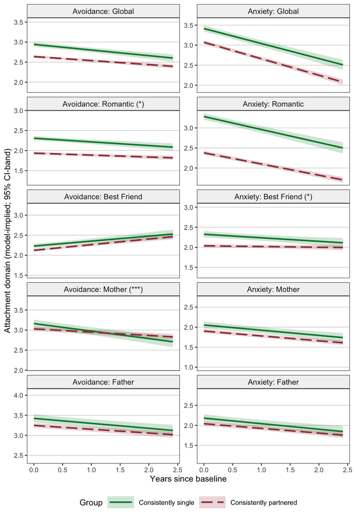

```r
plot_rq2_traject
```

No support for our hypothesis. Overall, only limited evidence that consistently single vs. partnered people change differently in their attachment over time. Some of the gaps are still quite sizeable, reflecting baseline differences and potentially selection effects - especially for global avoidance and anxiety as well as romantic avoidance and anxiety.

However, there are a few significant differences in change:  
- romantic avoidance  
- mother-specific avoidance  
- friend-specific anxiety  
Here, single people generally decreased slightly more strongly in attachment insecurity. For romantic avoidance a sizable gap remains but for friend-specific anxiety single and partnered people become more similar, almost closing the gap.

(Mother-specific avoidance is a bit different: although the slopes differ the most here, both groups are still quite similar across the intervention period if we take the confidence bands into account…).

### 4.2.7 Full model results

#### 4.2.7.1 Single-group models

##### 4.2.7.1.1 Avoidance: Global

Full model results for avoidance (global) (in the consistently single people):

```r
broom::tidy(get(paste0("fit_rq2_", outcomes$short[1])), conf.int = TRUE, conf.level = 0.95) %>%
  filter(label != "") %>%
  arrange(label) %>%
  select(term = label, est = estimate, ci_lo = conf.low, ci_hi = conf.high, p_value = p.value, est_std = std.all) %>%
  knitr::kable(digits = 3)
```

| term | est | ci_lo | ci_hi | p_value | est_std |
| --- | --- | --- | --- | --- | --- |
| a0 | 2.943 | 2.884 | 3.001 | 0.000 | 4.143 |
| a1 | -0.340 | -0.425 | -0.256 | 0.000 | -0.457 |
| bi | -0.045 | -0.098 | 0.007 | 0.093 | -0.071 |
| bs | 0.029 | -0.045 | 0.104 | 0.440 | 0.044 |
| cis | -0.062 | -0.127 | 0.002 | 0.059 | -0.118 |
| pred_t00 | 2.943 | 2.884 | 3.001 | 0.000 | 4.143 |
| pred_t01 | 2.931 | 2.873 | 2.989 | 0.000 | 4.127 |
| pred_t02 | 2.919 | 2.862 | 2.977 | 0.000 | 4.112 |
| pred_t03 | 2.908 | 2.850 | 2.965 | 0.000 | 4.096 |
| pred_t04 | 2.896 | 2.839 | 2.953 | 0.000 | 4.080 |
| pred_t05 | 2.884 | 2.827 | 2.941 | 0.000 | 4.064 |
| pred_t06 | 2.872 | 2.815 | 2.929 | 0.000 | 4.049 |
| pred_t07 | 2.861 | 2.803 | 2.918 | 0.000 | 4.033 |
| pred_t08 | 2.849 | 2.791 | 2.906 | 0.000 | 4.017 |
| pred_t09 | 2.837 | 2.779 | 2.895 | 0.000 | 4.001 |
| pred_t10 | 2.825 | 2.767 | 2.884 | 0.000 | 3.986 |
| pred_t11 | 2.814 | 2.754 | 2.873 | 0.000 | 3.970 |
| pred_t12 | 2.802 | 2.741 | 2.862 | 0.000 | 3.954 |
| pred_t13 | 2.790 | 2.729 | 2.852 | 0.000 | 3.938 |
| pred_t14 | 2.778 | 2.716 | 2.841 | 0.000 | 3.923 |
| pred_t15 | 2.767 | 2.703 | 2.831 | 0.000 | 3.907 |
| pred_t16 | 2.755 | 2.689 | 2.820 | 0.000 | 3.891 |
| pred_t17 | 2.743 | 2.676 | 2.810 | 0.000 | 3.875 |
| pred_t18 | 2.731 | 2.663 | 2.800 | 0.000 | 3.860 |
| pred_t19 | 2.720 | 2.649 | 2.790 | 0.000 | 3.844 |
| pred_t20 | 2.708 | 2.636 | 2.780 | 0.000 | 3.828 |
| pred_t21 | 2.696 | 2.622 | 2.770 | 0.000 | 3.812 |
| pred_t22 | 2.685 | 2.609 | 2.760 | 0.000 | 3.797 |
| pred_t23 | 2.673 | 2.595 | 2.750 | 0.000 | 3.781 |
| pred_t24 | 2.661 | 2.581 | 2.741 | 0.000 | 3.765 |
| pred_t25 | 2.649 | 2.568 | 2.731 | 0.000 | 3.749 |
| pred_t26 | 2.638 | 2.554 | 2.721 | 0.000 | 3.733 |
| pred_t27 | 2.626 | 2.540 | 2.712 | 0.000 | 3.718 |
| pred_t28 | 2.614 | 2.526 | 2.702 | 0.000 | 3.702 |
| pred_t29 | 2.602 | 2.512 | 2.693 | 0.000 | 3.686 |
| res_00 | 0.199 | 0.172 | 0.225 | 0.000 | 0.282 |
| res_01 | 0.143 | 0.116 | 0.170 | 0.000 | 0.222 |
| res_02 | 0.115 | 0.095 | 0.136 | 0.000 | 0.188 |
| res_03 | 0.134 | 0.110 | 0.157 | 0.000 | 0.212 |
| res_04 | 0.153 | 0.126 | 0.181 | 0.000 | 0.236 |
| res_05 | 0.152 | 0.126 | 0.179 | 0.000 | 0.234 |
| res_06 | 0.151 | 0.124 | 0.178 | 0.000 | 0.231 |
| res_07 | 0.145 | 0.119 | 0.171 | 0.000 | 0.223 |
| res_08 | 0.118 | 0.096 | 0.141 | 0.000 | 0.188 |
| res_09 | 0.113 | 0.091 | 0.134 | 0.000 | 0.179 |
| res_10 | 0.141 | 0.116 | 0.166 | 0.000 | 0.211 |
| res_11 | 0.115 | 0.093 | 0.138 | 0.000 | 0.177 |
| res_12 | 0.107 | 0.085 | 0.128 | 0.000 | 0.163 |
| res_13 | 0.124 | 0.098 | 0.150 | 0.000 | 0.182 |
| res_14 | 0.106 | 0.082 | 0.129 | 0.000 | 0.156 |
| res_15 | 0.101 | 0.076 | 0.126 | 0.000 | 0.147 |
| res_16 | 0.102 | 0.076 | 0.128 | 0.000 | 0.145 |
| res_17 | 0.126 | 0.088 | 0.163 | 0.000 | 0.168 |
| res_18 | 0.126 | 0.089 | 0.163 | 0.000 | 0.164 |
| res_19 | 0.115 | 0.080 | 0.150 | 0.000 | 0.148 |
| res_20 | 0.138 | 0.096 | 0.180 | 0.000 | 0.169 |
| res_21 | 0.105 | 0.072 | 0.138 | 0.000 | 0.130 |
| res_22 | 0.142 | 0.097 | 0.186 | 0.000 | 0.163 |
| res_23 | 0.115 | 0.078 | 0.152 | 0.000 | 0.132 |
| res_24 | 0.092 | 0.062 | 0.123 | 0.000 | 0.106 |
| res_25 | 0.088 | 0.054 | 0.122 | 0.000 | 0.098 |
| res_26 | 0.127 | 0.079 | 0.175 | 0.000 | 0.132 |
| res_27 | 0.167 | 0.094 | 0.240 | 0.000 | 0.161 |
| res_28 | 0.117 | 0.060 | 0.174 | 0.000 | 0.115 |
| res_29 | 0.152 | 0.077 | 0.228 | 0.000 | 0.140 |
| vi | 0.502 | 0.440 | 0.563 | 0.000 | 0.995 |
| vs | 0.554 | 0.431 | 0.677 | 0.000 | 0.998 |

Full model results for avoidance (global) (in the consistently partnered people):

```r
broom::tidy(get(paste0("fit_rq2_", outcomes$short[1], "_partn_c")), conf.int = TRUE, conf.level = 0.95) %>%
  filter(label != "") %>%
  arrange(label) %>%
  select(term = label, est = estimate, ci_lo = conf.low, ci_hi = conf.high, p_value = p.value, est_std = std.all) %>%
  knitr::kable(digits = 3)
```

| term | est | ci_lo | ci_hi | p_value | est_std |
| --- | --- | --- | --- | --- | --- |
| a0 | 2.639 | 2.601 | 2.677 | 0.000 | 3.633 |
| a1 | -0.243 | -0.294 | -0.192 | 0.000 | -0.344 |
| bi | -0.005 | -0.042 | 0.033 | 0.799 | -0.007 |
| bs | 0.004 | -0.045 | 0.052 | 0.880 | 0.005 |
| cis | -0.119 | -0.158 | -0.080 | 0.000 | -0.231 |
| pred_t00 | 2.639 | 2.601 | 2.677 | 0.000 | 3.633 |
| pred_t01 | 2.630 | 2.593 | 2.668 | 0.000 | 3.621 |
| pred_t02 | 2.622 | 2.585 | 2.659 | 0.000 | 3.609 |
| pred_t03 | 2.614 | 2.577 | 2.651 | 0.000 | 3.598 |
| pred_t04 | 2.605 | 2.569 | 2.642 | 0.000 | 3.586 |
| pred_t05 | 2.597 | 2.561 | 2.633 | 0.000 | 3.574 |
| pred_t06 | 2.589 | 2.552 | 2.625 | 0.000 | 3.562 |
| pred_t07 | 2.580 | 2.544 | 2.617 | 0.000 | 3.550 |
| pred_t08 | 2.572 | 2.536 | 2.608 | 0.000 | 3.538 |
| pred_t09 | 2.564 | 2.527 | 2.600 | 0.000 | 3.527 |
| pred_t10 | 2.555 | 2.518 | 2.592 | 0.000 | 3.515 |
| pred_t11 | 2.547 | 2.510 | 2.584 | 0.000 | 3.503 |
| pred_t12 | 2.538 | 2.501 | 2.576 | 0.000 | 3.491 |
| pred_t13 | 2.530 | 2.492 | 2.568 | 0.000 | 3.479 |
| pred_t14 | 2.522 | 2.483 | 2.560 | 0.000 | 3.467 |
| pred_t15 | 2.513 | 2.474 | 2.552 | 0.000 | 3.455 |
| pred_t16 | 2.505 | 2.465 | 2.545 | 0.000 | 3.444 |
| pred_t17 | 2.497 | 2.456 | 2.537 | 0.000 | 3.432 |
| pred_t18 | 2.488 | 2.447 | 2.529 | 0.000 | 3.420 |
| pred_t19 | 2.480 | 2.438 | 2.522 | 0.000 | 3.408 |
| pred_t20 | 2.471 | 2.428 | 2.514 | 0.000 | 3.396 |
| pred_t21 | 2.463 | 2.419 | 2.507 | 0.000 | 3.384 |
| pred_t22 | 2.455 | 2.410 | 2.500 | 0.000 | 3.372 |
| pred_t23 | 2.446 | 2.400 | 2.492 | 0.000 | 3.361 |
| pred_t24 | 2.438 | 2.391 | 2.485 | 0.000 | 3.349 |
| pred_t25 | 2.430 | 2.381 | 2.478 | 0.000 | 3.337 |
| pred_t26 | 2.421 | 2.372 | 2.471 | 0.000 | 3.325 |
| pred_t27 | 2.413 | 2.362 | 2.464 | 0.000 | 3.313 |
| pred_t28 | 2.405 | 2.353 | 2.456 | 0.000 | 3.301 |
| pred_t29 | 2.396 | 2.343 | 2.449 | 0.000 | 3.290 |
| res_00 | 0.195 | 0.178 | 0.212 | 0.000 | 0.270 |
| res_01 | 0.165 | 0.146 | 0.184 | 0.000 | 0.241 |
| res_02 | 0.125 | 0.111 | 0.140 | 0.000 | 0.196 |
| res_03 | 0.127 | 0.112 | 0.141 | 0.000 | 0.199 |
| res_04 | 0.115 | 0.101 | 0.129 | 0.000 | 0.186 |
| res_05 | 0.130 | 0.115 | 0.146 | 0.000 | 0.206 |
| res_06 | 0.149 | 0.131 | 0.167 | 0.000 | 0.229 |
| res_07 | 0.121 | 0.107 | 0.136 | 0.000 | 0.196 |
| res_08 | 0.123 | 0.109 | 0.138 | 0.000 | 0.198 |
| res_09 | 0.119 | 0.105 | 0.134 | 0.000 | 0.192 |
| res_10 | 0.103 | 0.090 | 0.115 | 0.000 | 0.169 |
| res_11 | 0.120 | 0.106 | 0.135 | 0.000 | 0.191 |
| res_12 | 0.106 | 0.093 | 0.119 | 0.000 | 0.171 |
| res_13 | 0.111 | 0.097 | 0.125 | 0.000 | 0.175 |
| res_14 | 0.114 | 0.099 | 0.130 | 0.000 | 0.177 |
| res_15 | 0.100 | 0.085 | 0.115 | 0.000 | 0.156 |
| res_16 | 0.111 | 0.094 | 0.129 | 0.000 | 0.168 |
| res_17 | 0.108 | 0.090 | 0.126 | 0.000 | 0.162 |
| res_18 | 0.091 | 0.074 | 0.107 | 0.000 | 0.137 |
| res_19 | 0.110 | 0.090 | 0.129 | 0.000 | 0.158 |
| res_20 | 0.109 | 0.090 | 0.128 | 0.000 | 0.154 |
| res_21 | 0.082 | 0.067 | 0.098 | 0.000 | 0.117 |
| res_22 | 0.121 | 0.099 | 0.142 | 0.000 | 0.160 |
| res_23 | 0.109 | 0.088 | 0.130 | 0.000 | 0.143 |
| res_24 | 0.103 | 0.083 | 0.123 | 0.000 | 0.133 |
| res_25 | 0.107 | 0.085 | 0.129 | 0.000 | 0.134 |
| res_26 | 0.126 | 0.099 | 0.154 | 0.000 | 0.150 |
| res_27 | 0.097 | 0.070 | 0.123 | 0.000 | 0.116 |
| res_28 | 0.115 | 0.083 | 0.147 | 0.000 | 0.131 |
| res_29 | 0.101 | 0.070 | 0.133 | 0.000 | 0.114 |
| vi | 0.528 | 0.487 | 0.568 | 0.000 | 1.000 |
| vs | 0.499 | 0.431 | 0.567 | 0.000 | 1.000 |

##### 4.2.7.1.2 Avoidance: Romantic

Full model results for avoidance (romantic) (in the consistently single people):

```r
broom::tidy(get(paste0("fit_rq2_", outcomes$short[2])), conf.int = TRUE, conf.level = 0.95) %>%
  filter(label != "") %>%
  arrange(label) %>%
  select(term = label, est = estimate, ci_lo = conf.low, ci_hi = conf.high, p_value = p.value, est_std = std.all) %>%
  knitr::kable(digits = 3)
```

| term | est | ci_lo | ci_hi | p_value | est_std |
| --- | --- | --- | --- | --- | --- |
| a0 | 2.309 | 2.253 | 2.365 | 0.000 | 3.462 |
| a1 | -0.222 | -0.314 | -0.131 | 0.000 | -0.286 |
| bi | 0.066 | 0.016 | 0.117 | 0.010 | 0.110 |
| bs | -0.082 | -0.163 | -0.002 | 0.045 | -0.117 |
| cis | -0.048 | -0.116 | 0.020 | 0.163 | -0.094 |
| pred_t00 | 2.309 | 2.253 | 2.365 | 0.000 | 3.462 |
| pred_t01 | 2.301 | 2.246 | 2.357 | 0.000 | 3.452 |
| pred_t02 | 2.294 | 2.239 | 2.349 | 0.000 | 3.442 |
| pred_t03 | 2.286 | 2.231 | 2.341 | 0.000 | 3.432 |
| pred_t04 | 2.278 | 2.224 | 2.333 | 0.000 | 3.422 |
| pred_t05 | 2.271 | 2.216 | 2.325 | 0.000 | 3.413 |
| pred_t06 | 2.263 | 2.209 | 2.317 | 0.000 | 3.403 |
| pred_t07 | 2.255 | 2.201 | 2.310 | 0.000 | 3.393 |
| pred_t08 | 2.248 | 2.192 | 2.303 | 0.000 | 3.383 |
| pred_t09 | 2.240 | 2.184 | 2.296 | 0.000 | 3.373 |
| pred_t10 | 2.232 | 2.176 | 2.289 | 0.000 | 3.363 |
| pred_t11 | 2.225 | 2.167 | 2.282 | 0.000 | 3.353 |
| pred_t12 | 2.217 | 2.158 | 2.276 | 0.000 | 3.344 |
| pred_t13 | 2.209 | 2.149 | 2.269 | 0.000 | 3.334 |
| pred_t14 | 2.202 | 2.140 | 2.263 | 0.000 | 3.324 |
| pred_t15 | 2.194 | 2.131 | 2.257 | 0.000 | 3.314 |
| pred_t16 | 2.186 | 2.122 | 2.251 | 0.000 | 3.304 |
| pred_t17 | 2.179 | 2.112 | 2.245 | 0.000 | 3.294 |
| pred_t18 | 2.171 | 2.103 | 2.239 | 0.000 | 3.284 |
| pred_t19 | 2.163 | 2.093 | 2.234 | 0.000 | 3.275 |
| pred_t20 | 2.156 | 2.083 | 2.228 | 0.000 | 3.265 |
| pred_t21 | 2.148 | 2.073 | 2.222 | 0.000 | 3.255 |
| pred_t22 | 2.140 | 2.064 | 2.217 | 0.000 | 3.245 |
| pred_t23 | 2.133 | 2.054 | 2.212 | 0.000 | 3.235 |
| pred_t24 | 2.125 | 2.044 | 2.206 | 0.000 | 3.225 |
| pred_t25 | 2.117 | 2.034 | 2.201 | 0.000 | 3.216 |
| pred_t26 | 2.110 | 2.024 | 2.196 | 0.000 | 3.206 |
| pred_t27 | 2.102 | 2.013 | 2.191 | 0.000 | 3.196 |
| pred_t28 | 2.094 | 2.003 | 2.185 | 0.000 | 3.186 |
| pred_t29 | 2.087 | 1.993 | 2.180 | 0.000 | 3.176 |
| res_00 | 0.345 | 0.301 | 0.390 | 0.000 | 0.437 |
| res_01 | 0.216 | 0.176 | 0.256 | 0.000 | 0.328 |
| res_02 | 0.192 | 0.159 | 0.225 | 0.000 | 0.304 |
| res_03 | 0.163 | 0.134 | 0.192 | 0.000 | 0.270 |
| res_04 | 0.171 | 0.139 | 0.202 | 0.000 | 0.279 |
| res_05 | 0.196 | 0.161 | 0.230 | 0.000 | 0.306 |
| res_06 | 0.175 | 0.143 | 0.207 | 0.000 | 0.281 |
| res_07 | 0.192 | 0.158 | 0.226 | 0.000 | 0.298 |
| res_08 | 0.158 | 0.129 | 0.187 | 0.000 | 0.255 |
| res_09 | 0.159 | 0.129 | 0.188 | 0.000 | 0.253 |
| res_10 | 0.133 | 0.108 | 0.158 | 0.000 | 0.217 |
| res_11 | 0.166 | 0.135 | 0.197 | 0.000 | 0.253 |
| res_12 | 0.154 | 0.124 | 0.184 | 0.000 | 0.234 |
| res_13 | 0.139 | 0.110 | 0.167 | 0.000 | 0.212 |
| res_14 | 0.129 | 0.101 | 0.157 | 0.000 | 0.195 |
| res_15 | 0.119 | 0.091 | 0.147 | 0.000 | 0.178 |
| res_16 | 0.124 | 0.092 | 0.156 | 0.000 | 0.179 |
| res_17 | 0.138 | 0.098 | 0.177 | 0.000 | 0.190 |
| res_18 | 0.087 | 0.060 | 0.114 | 0.000 | 0.125 |
| res_19 | 0.108 | 0.075 | 0.141 | 0.000 | 0.146 |
| res_20 | 0.120 | 0.083 | 0.158 | 0.000 | 0.155 |
| res_21 | 0.098 | 0.067 | 0.128 | 0.000 | 0.125 |
| res_22 | 0.095 | 0.063 | 0.128 | 0.000 | 0.118 |
| res_23 | 0.225 | 0.156 | 0.295 | 0.000 | 0.234 |
| res_24 | 0.238 | 0.167 | 0.308 | 0.000 | 0.236 |
| res_25 | 0.116 | 0.074 | 0.158 | 0.000 | 0.126 |
| res_26 | 0.096 | 0.058 | 0.134 | 0.000 | 0.103 |
| res_27 | 0.259 | 0.150 | 0.368 | 0.000 | 0.230 |
| res_28 | 0.066 | 0.030 | 0.102 | 0.000 | 0.068 |
| res_29 | 0.216 | 0.114 | 0.318 | 0.000 | 0.187 |
| vi | 0.439 | 0.383 | 0.496 | 0.000 | 0.988 |
| vs | 0.597 | 0.450 | 0.743 | 0.000 | 0.986 |

Full model results for avoidance (romantic) (in the consistently partnered people):

```r
broom::tidy(get(paste0("fit_rq2_", outcomes$short[2], "_partn_c")), conf.int = TRUE, conf.level = 0.95) %>%
  filter(label != "") %>%
  arrange(label) %>%
  select(term = label, est = estimate, ci_lo = conf.low, ci_hi = conf.high, p_value = p.value, est_std = std.all) %>%
  knitr::kable(digits = 3)
```

| term | est | ci_lo | ci_hi | p_value | est_std |
| --- | --- | --- | --- | --- | --- |
| a0 | 1.935 | 1.898 | 1.972 | 0.000 | 2.666 |
| a1 | -0.116 | -0.168 | -0.064 | 0.000 | -0.159 |
| bi | 0.184 | 0.147 | 0.220 | 0.000 | 0.253 |
| bs | 0.021 | -0.029 | 0.070 | 0.409 | 0.029 |
| cis | -0.126 | -0.165 | -0.087 | 0.000 | -0.247 |
| pred_t00 | 1.935 | 1.898 | 1.972 | 0.000 | 2.666 |
| pred_t01 | 1.931 | 1.895 | 1.968 | 0.000 | 2.660 |
| pred_t02 | 1.927 | 1.891 | 1.963 | 0.000 | 2.655 |
| pred_t03 | 1.923 | 1.888 | 1.959 | 0.000 | 2.649 |
| pred_t04 | 1.919 | 1.884 | 1.955 | 0.000 | 2.644 |
| pred_t05 | 1.915 | 1.880 | 1.950 | 0.000 | 2.638 |
| pred_t06 | 1.911 | 1.876 | 1.946 | 0.000 | 2.633 |
| pred_t07 | 1.907 | 1.872 | 1.942 | 0.000 | 2.627 |
| pred_t08 | 1.903 | 1.868 | 1.938 | 0.000 | 2.622 |
| pred_t09 | 1.899 | 1.864 | 1.934 | 0.000 | 2.616 |
| pred_t10 | 1.895 | 1.860 | 1.931 | 0.000 | 2.611 |
| pred_t11 | 1.891 | 1.855 | 1.927 | 0.000 | 2.605 |
| pred_t12 | 1.887 | 1.851 | 1.923 | 0.000 | 2.600 |
| pred_t13 | 1.883 | 1.847 | 1.920 | 0.000 | 2.594 |
| pred_t14 | 1.879 | 1.842 | 1.917 | 0.000 | 2.589 |
| pred_t15 | 1.875 | 1.837 | 1.913 | 0.000 | 2.583 |
| pred_t16 | 1.871 | 1.833 | 1.910 | 0.000 | 2.578 |
| pred_t17 | 1.867 | 1.828 | 1.907 | 0.000 | 2.572 |
| pred_t18 | 1.863 | 1.823 | 1.904 | 0.000 | 2.567 |
| pred_t19 | 1.859 | 1.818 | 1.900 | 0.000 | 2.561 |
| pred_t20 | 1.855 | 1.813 | 1.897 | 0.000 | 2.556 |
| pred_t21 | 1.851 | 1.808 | 1.894 | 0.000 | 2.551 |
| pred_t22 | 1.847 | 1.803 | 1.892 | 0.000 | 2.545 |
| pred_t23 | 1.843 | 1.798 | 1.889 | 0.000 | 2.540 |
| pred_t24 | 1.839 | 1.793 | 1.886 | 0.000 | 2.534 |
| pred_t25 | 1.835 | 1.787 | 1.883 | 0.000 | 2.529 |
| pred_t26 | 1.831 | 1.782 | 1.880 | 0.000 | 2.523 |
| pred_t27 | 1.827 | 1.777 | 1.878 | 0.000 | 2.518 |
| pred_t28 | 1.823 | 1.772 | 1.875 | 0.000 | 2.512 |
| pred_t29 | 1.819 | 1.766 | 1.872 | 0.000 | 2.507 |
| res_00 | 0.211 | 0.193 | 0.229 | 0.000 | 0.285 |
| res_01 | 0.147 | 0.129 | 0.165 | 0.000 | 0.221 |
| res_02 | 0.147 | 0.130 | 0.163 | 0.000 | 0.223 |
| res_03 | 0.130 | 0.115 | 0.145 | 0.000 | 0.204 |
| res_04 | 0.135 | 0.119 | 0.151 | 0.000 | 0.212 |
| res_05 | 0.138 | 0.122 | 0.155 | 0.000 | 0.217 |
| res_06 | 0.148 | 0.130 | 0.167 | 0.000 | 0.229 |
| res_07 | 0.118 | 0.104 | 0.132 | 0.000 | 0.192 |
| res_08 | 0.127 | 0.111 | 0.142 | 0.000 | 0.202 |
| res_09 | 0.129 | 0.114 | 0.144 | 0.000 | 0.204 |
| res_10 | 0.112 | 0.098 | 0.125 | 0.000 | 0.181 |
| res_11 | 0.112 | 0.098 | 0.125 | 0.000 | 0.180 |
| res_12 | 0.133 | 0.117 | 0.149 | 0.000 | 0.205 |
| res_13 | 0.096 | 0.084 | 0.109 | 0.000 | 0.155 |
| res_14 | 0.124 | 0.107 | 0.141 | 0.000 | 0.189 |
| res_15 | 0.104 | 0.087 | 0.120 | 0.000 | 0.160 |
| res_16 | 0.123 | 0.103 | 0.142 | 0.000 | 0.182 |
| res_17 | 0.152 | 0.127 | 0.176 | 0.000 | 0.211 |
| res_18 | 0.119 | 0.099 | 0.140 | 0.000 | 0.171 |
| res_19 | 0.102 | 0.084 | 0.120 | 0.000 | 0.146 |
| res_20 | 0.107 | 0.087 | 0.126 | 0.000 | 0.149 |
| res_21 | 0.090 | 0.073 | 0.108 | 0.000 | 0.126 |
| res_22 | 0.099 | 0.081 | 0.118 | 0.000 | 0.133 |
| res_23 | 0.083 | 0.066 | 0.100 | 0.000 | 0.111 |
| res_24 | 0.101 | 0.081 | 0.120 | 0.000 | 0.128 |
| res_25 | 0.103 | 0.082 | 0.124 | 0.000 | 0.127 |
| res_26 | 0.127 | 0.099 | 0.154 | 0.000 | 0.147 |
| res_27 | 0.093 | 0.067 | 0.119 | 0.000 | 0.110 |
| res_28 | 0.097 | 0.067 | 0.126 | 0.000 | 0.110 |
| res_29 | 0.143 | 0.101 | 0.185 | 0.000 | 0.150 |
| vi | 0.493 | 0.455 | 0.531 | 0.000 | 0.936 |
| vs | 0.529 | 0.454 | 0.604 | 0.000 | 0.999 |

##### 4.2.7.1.3 Avoidance: Best Friend

Full model results for avoidance (best friend) (in the consistently single people):

```r
broom::tidy(get(paste0("fit_rq2_", outcomes$short[3])), conf.int = TRUE, conf.level = 0.95) %>%
  filter(label != "") %>%
  arrange(label) %>%
  select(term = label, est = estimate, ci_lo = conf.low, ci_hi = conf.high, p_value = p.value, est_std = std.all) %>%
  knitr::kable(digits = 3)
```

| term | est | ci_lo | ci_hi | p_value | est_std |
| --- | --- | --- | --- | --- | --- |
| a0 | 2.229 | 2.168 | 2.289 | 0.000 | 3.119 |
| a1 | 0.300 | 0.188 | 0.412 | 0.000 | 0.290 |
| bi | -0.037 | -0.091 | 0.017 | 0.184 | -0.057 |
| bs | -0.075 | -0.174 | 0.024 | 0.138 | -0.081 |
| cis | -0.099 | -0.186 | -0.011 | 0.027 | -0.135 |
| pred_t00 | 2.229 | 2.168 | 2.289 | 0.000 | 3.119 |
| pred_t01 | 2.239 | 2.180 | 2.298 | 0.000 | 3.129 |
| pred_t02 | 2.249 | 2.191 | 2.308 | 0.000 | 3.139 |
| pred_t03 | 2.260 | 2.201 | 2.318 | 0.000 | 3.149 |
| pred_t04 | 2.270 | 2.212 | 2.328 | 0.000 | 3.159 |
| pred_t05 | 2.280 | 2.222 | 2.338 | 0.000 | 3.169 |
| pred_t06 | 2.291 | 2.232 | 2.349 | 0.000 | 3.179 |
| pred_t07 | 2.301 | 2.242 | 2.360 | 0.000 | 3.189 |
| pred_t08 | 2.311 | 2.252 | 2.371 | 0.000 | 3.199 |
| pred_t09 | 2.322 | 2.261 | 2.382 | 0.000 | 3.209 |
| pred_t10 | 2.332 | 2.270 | 2.394 | 0.000 | 3.219 |
| pred_t11 | 2.342 | 2.279 | 2.406 | 0.000 | 3.229 |
| pred_t12 | 2.353 | 2.287 | 2.418 | 0.000 | 3.239 |
| pred_t13 | 2.363 | 2.296 | 2.430 | 0.000 | 3.249 |
| pred_t14 | 2.373 | 2.304 | 2.442 | 0.000 | 3.259 |
| pred_t15 | 2.384 | 2.312 | 2.455 | 0.000 | 3.270 |
| pred_t16 | 2.394 | 2.320 | 2.468 | 0.000 | 3.280 |
| pred_t17 | 2.404 | 2.328 | 2.480 | 0.000 | 3.290 |
| pred_t18 | 2.415 | 2.336 | 2.493 | 0.000 | 3.300 |
| pred_t19 | 2.425 | 2.344 | 2.506 | 0.000 | 3.310 |
| pred_t20 | 2.435 | 2.351 | 2.519 | 0.000 | 3.320 |
| pred_t21 | 2.446 | 2.359 | 2.533 | 0.000 | 3.330 |
| pred_t22 | 2.456 | 2.366 | 2.546 | 0.000 | 3.340 |
| pred_t23 | 2.466 | 2.374 | 2.559 | 0.000 | 3.350 |
| pred_t24 | 2.477 | 2.381 | 2.573 | 0.000 | 3.360 |
| pred_t25 | 2.487 | 2.388 | 2.586 | 0.000 | 3.370 |
| pred_t26 | 2.497 | 2.395 | 2.599 | 0.000 | 3.380 |
| pred_t27 | 2.508 | 2.402 | 2.613 | 0.000 | 3.390 |
| pred_t28 | 2.518 | 2.409 | 2.627 | 0.000 | 3.400 |
| pred_t29 | 2.528 | 2.416 | 2.640 | 0.000 | 3.410 |
| res_00 | 0.290 | 0.250 | 0.329 | 0.000 | 0.362 |
| res_01 | 0.197 | 0.159 | 0.235 | 0.000 | 0.280 |
| res_02 | 0.155 | 0.127 | 0.184 | 0.000 | 0.236 |
| res_03 | 0.180 | 0.148 | 0.212 | 0.000 | 0.264 |
| res_04 | 0.230 | 0.188 | 0.273 | 0.000 | 0.313 |
| res_05 | 0.196 | 0.161 | 0.231 | 0.000 | 0.278 |
| res_06 | 0.189 | 0.154 | 0.224 | 0.000 | 0.268 |
| res_07 | 0.208 | 0.171 | 0.244 | 0.000 | 0.283 |
| res_08 | 0.210 | 0.172 | 0.249 | 0.000 | 0.281 |
| res_09 | 0.177 | 0.143 | 0.211 | 0.000 | 0.242 |
| res_10 | 0.149 | 0.121 | 0.177 | 0.000 | 0.206 |
| res_11 | 0.185 | 0.150 | 0.221 | 0.000 | 0.238 |
| res_12 | 0.192 | 0.155 | 0.230 | 0.000 | 0.238 |
| res_13 | 0.123 | 0.096 | 0.149 | 0.000 | 0.161 |
| res_14 | 0.206 | 0.162 | 0.250 | 0.000 | 0.236 |
| res_15 | 0.259 | 0.200 | 0.317 | 0.000 | 0.271 |
| res_16 | 0.211 | 0.159 | 0.262 | 0.000 | 0.224 |
| res_17 | 0.214 | 0.155 | 0.273 | 0.000 | 0.219 |
| res_18 | 0.223 | 0.159 | 0.288 | 0.000 | 0.218 |
| res_19 | 0.164 | 0.114 | 0.213 | 0.000 | 0.163 |
| res_20 | 0.211 | 0.147 | 0.275 | 0.000 | 0.192 |
| res_21 | 0.179 | 0.118 | 0.240 | 0.000 | 0.161 |
| res_22 | 0.329 | 0.226 | 0.431 | 0.000 | 0.251 |
| res_23 | 0.204 | 0.138 | 0.269 | 0.000 | 0.165 |
| res_24 | 0.180 | 0.120 | 0.239 | 0.000 | 0.142 |
| res_25 | 0.197 | 0.126 | 0.269 | 0.000 | 0.148 |
| res_26 | 0.213 | 0.134 | 0.292 | 0.000 | 0.151 |
| res_27 | 0.194 | 0.105 | 0.283 | 0.000 | 0.134 |
| res_28 | 0.238 | 0.129 | 0.347 | 0.000 | 0.153 |
| res_29 | 0.267 | 0.135 | 0.399 | 0.000 | 0.162 |
| vi | 0.509 | 0.444 | 0.573 | 0.000 | 0.997 |
| vs | 1.060 | 0.811 | 1.308 | 0.000 | 0.994 |

Full model results for avoidance (best friend) (in the consistently partnered people):

```r
broom::tidy(get(paste0("fit_rq2_", outcomes$short[3], "_partn_c")), conf.int = TRUE, conf.level = 0.95) %>%
  filter(label != "") %>%
  arrange(label) %>%
  select(term = label, est = estimate, ci_lo = conf.low, ci_hi = conf.high, p_value = p.value, est_std = std.all) %>%
  knitr::kable(digits = 3)
```

| term | est | ci_lo | ci_hi | p_value | est_std |
| --- | --- | --- | --- | --- | --- |
| a0 | 2.123 | 2.086 | 2.159 | 0.000 | 3.099 |
| a1 | 0.340 | 0.271 | 0.409 | 0.000 | 0.319 |
| bi | 0.014 | -0.021 | 0.050 | 0.434 | 0.021 |
| bs | -0.059 | -0.125 | 0.006 | 0.077 | -0.056 |
| cis | -0.181 | -0.232 | -0.130 | 0.000 | -0.249 |
| pred_t00 | 2.123 | 2.086 | 2.159 | 0.000 | 3.099 |
| pred_t01 | 2.134 | 2.099 | 2.170 | 0.000 | 3.110 |
| pred_t02 | 2.146 | 2.111 | 2.181 | 0.000 | 3.121 |
| pred_t03 | 2.158 | 2.123 | 2.193 | 0.000 | 3.132 |
| pred_t04 | 2.170 | 2.135 | 2.204 | 0.000 | 3.143 |
| pred_t05 | 2.181 | 2.147 | 2.216 | 0.000 | 3.154 |
| pred_t06 | 2.193 | 2.159 | 2.227 | 0.000 | 3.165 |
| pred_t07 | 2.205 | 2.170 | 2.239 | 0.000 | 3.176 |
| pred_t08 | 2.216 | 2.181 | 2.251 | 0.000 | 3.187 |
| pred_t09 | 2.228 | 2.193 | 2.264 | 0.000 | 3.198 |
| pred_t10 | 2.240 | 2.204 | 2.276 | 0.000 | 3.209 |
| pred_t11 | 2.252 | 2.215 | 2.289 | 0.000 | 3.220 |
| pred_t12 | 2.263 | 2.225 | 2.301 | 0.000 | 3.231 |
| pred_t13 | 2.275 | 2.236 | 2.314 | 0.000 | 3.242 |
| pred_t14 | 2.287 | 2.247 | 2.327 | 0.000 | 3.253 |
| pred_t15 | 2.298 | 2.257 | 2.340 | 0.000 | 3.264 |
| pred_t16 | 2.310 | 2.267 | 2.353 | 0.000 | 3.275 |
| pred_t17 | 2.322 | 2.278 | 2.366 | 0.000 | 3.286 |
| pred_t18 | 2.334 | 2.288 | 2.379 | 0.000 | 3.297 |
| pred_t19 | 2.345 | 2.298 | 2.393 | 0.000 | 3.308 |
| pred_t20 | 2.357 | 2.308 | 2.406 | 0.000 | 3.319 |
| pred_t21 | 2.369 | 2.318 | 2.420 | 0.000 | 3.330 |
| pred_t22 | 2.380 | 2.328 | 2.433 | 0.000 | 3.341 |
| pred_t23 | 2.392 | 2.338 | 2.447 | 0.000 | 3.352 |
| pred_t24 | 2.404 | 2.348 | 2.460 | 0.000 | 3.363 |
| pred_t25 | 2.416 | 2.357 | 2.474 | 0.000 | 3.374 |
| pred_t26 | 2.427 | 2.367 | 2.487 | 0.000 | 3.385 |
| pred_t27 | 2.439 | 2.377 | 2.501 | 0.000 | 3.396 |
| pred_t28 | 2.451 | 2.387 | 2.515 | 0.000 | 3.407 |
| pred_t29 | 2.462 | 2.396 | 2.529 | 0.000 | 3.418 |
| res_00 | 0.236 | 0.215 | 0.256 | 0.000 | 0.335 |
| res_01 | 0.131 | 0.115 | 0.148 | 0.000 | 0.223 |
| res_02 | 0.120 | 0.106 | 0.134 | 0.000 | 0.211 |
| res_03 | 0.127 | 0.112 | 0.142 | 0.000 | 0.222 |
| res_04 | 0.134 | 0.117 | 0.150 | 0.000 | 0.233 |
| res_05 | 0.164 | 0.145 | 0.184 | 0.000 | 0.272 |
| res_06 | 0.171 | 0.150 | 0.192 | 0.000 | 0.279 |
| res_07 | 0.163 | 0.145 | 0.182 | 0.000 | 0.267 |
| res_08 | 0.129 | 0.113 | 0.145 | 0.000 | 0.221 |
| res_09 | 0.122 | 0.107 | 0.137 | 0.000 | 0.208 |
| res_10 | 0.144 | 0.126 | 0.161 | 0.000 | 0.231 |
| res_11 | 0.129 | 0.113 | 0.145 | 0.000 | 0.207 |
| res_12 | 0.130 | 0.114 | 0.146 | 0.000 | 0.203 |
| res_13 | 0.130 | 0.113 | 0.147 | 0.000 | 0.196 |
| res_14 | 0.145 | 0.125 | 0.166 | 0.000 | 0.207 |
| res_15 | 0.144 | 0.122 | 0.166 | 0.000 | 0.198 |
| res_16 | 0.168 | 0.142 | 0.195 | 0.000 | 0.216 |
| res_17 | 0.188 | 0.157 | 0.218 | 0.000 | 0.225 |
| res_18 | 0.162 | 0.134 | 0.190 | 0.000 | 0.192 |
| res_19 | 0.150 | 0.124 | 0.176 | 0.000 | 0.173 |
| res_20 | 0.123 | 0.101 | 0.145 | 0.000 | 0.140 |
| res_21 | 0.102 | 0.083 | 0.122 | 0.000 | 0.113 |
| res_22 | 0.148 | 0.121 | 0.175 | 0.000 | 0.149 |
| res_23 | 0.090 | 0.072 | 0.109 | 0.000 | 0.092 |
| res_24 | 0.108 | 0.086 | 0.129 | 0.000 | 0.102 |
| res_25 | 0.139 | 0.110 | 0.168 | 0.000 | 0.122 |
| res_26 | 0.123 | 0.094 | 0.152 | 0.000 | 0.105 |
| res_27 | 0.162 | 0.117 | 0.208 | 0.000 | 0.128 |
| res_28 | 0.170 | 0.122 | 0.218 | 0.000 | 0.127 |
| res_29 | 0.148 | 0.100 | 0.196 | 0.000 | 0.107 |
| vi | 0.469 | 0.432 | 0.506 | 0.000 | 1.000 |
| vs | 1.129 | 0.998 | 1.259 | 0.000 | 0.997 |

##### 4.2.7.1.4 Avoidance: Mother

Full model results for avoidance (mother) (in the consistently single people):

```r
broom::tidy(get(paste0("fit_rq2_", outcomes$short[4])), conf.int = TRUE, conf.level = 0.95) %>%
  filter(label != "") %>%
  arrange(label) %>%
  select(term = label, est = estimate, ci_lo = conf.low, ci_hi = conf.high, p_value = p.value, est_std = std.all) %>%
  knitr::kable(digits = 3)
```

| term | est | ci_lo | ci_hi | p_value | est_std |
| --- | --- | --- | --- | --- | --- |
| a0 | 3.163 | 3.065 | 3.261 | 0.000 | 2.883 |
| a1 | -0.454 | -0.582 | -0.326 | 0.000 | -0.400 |
| bi | 0.186 | 0.083 | 0.290 | 0.000 | 0.153 |
| bs | -0.139 | -0.275 | -0.004 | 0.044 | -0.110 |
| cis | -0.327 | -0.470 | -0.185 | 0.000 | -0.267 |
| pred_t00 | 3.163 | 3.065 | 3.261 | 0.000 | 2.883 |
| pred_t01 | 3.147 | 3.051 | 3.244 | 0.000 | 2.869 |
| pred_t02 | 3.132 | 3.036 | 3.228 | 0.000 | 2.855 |
| pred_t03 | 3.116 | 3.021 | 3.211 | 0.000 | 2.841 |
| pred_t04 | 3.100 | 3.006 | 3.195 | 0.000 | 2.828 |
| pred_t05 | 3.085 | 2.991 | 3.178 | 0.000 | 2.814 |
| pred_t06 | 3.069 | 2.976 | 3.163 | 0.000 | 2.800 |
| pred_t07 | 3.053 | 2.960 | 3.147 | 0.000 | 2.786 |
| pred_t08 | 3.038 | 2.944 | 3.131 | 0.000 | 2.773 |
| pred_t09 | 3.022 | 2.928 | 3.116 | 0.000 | 2.759 |
| pred_t10 | 3.007 | 2.912 | 3.101 | 0.000 | 2.745 |
| pred_t11 | 2.991 | 2.896 | 3.086 | 0.000 | 2.731 |
| pred_t12 | 2.975 | 2.879 | 3.071 | 0.000 | 2.717 |
| pred_t13 | 2.960 | 2.862 | 3.057 | 0.000 | 2.704 |
| pred_t14 | 2.944 | 2.845 | 3.042 | 0.000 | 2.690 |
| pred_t15 | 2.928 | 2.828 | 3.028 | 0.000 | 2.676 |
| pred_t16 | 2.913 | 2.811 | 3.014 | 0.000 | 2.662 |
| pred_t17 | 2.897 | 2.794 | 3.000 | 0.000 | 2.649 |
| pred_t18 | 2.881 | 2.776 | 2.987 | 0.000 | 2.635 |
| pred_t19 | 2.866 | 2.758 | 2.973 | 0.000 | 2.621 |
| pred_t20 | 2.850 | 2.740 | 2.960 | 0.000 | 2.607 |
| pred_t21 | 2.834 | 2.722 | 2.946 | 0.000 | 2.593 |
| pred_t22 | 2.819 | 2.704 | 2.933 | 0.000 | 2.580 |
| pred_t23 | 2.803 | 2.686 | 2.920 | 0.000 | 2.566 |
| pred_t24 | 2.787 | 2.667 | 2.907 | 0.000 | 2.552 |
| pred_t25 | 2.772 | 2.649 | 2.894 | 0.000 | 2.538 |
| pred_t26 | 2.756 | 2.630 | 2.882 | 0.000 | 2.525 |
| pred_t27 | 2.740 | 2.612 | 2.869 | 0.000 | 2.511 |
| pred_t28 | 2.725 | 2.593 | 2.857 | 0.000 | 2.497 |
| pred_t29 | 2.709 | 2.574 | 2.844 | 0.000 | 2.483 |
| res_00 | 0.273 | 0.233 | 0.313 | 0.000 | 0.185 |
| res_01 | 0.178 | 0.140 | 0.217 | 0.000 | 0.131 |
| res_02 | 0.184 | 0.150 | 0.218 | 0.000 | 0.137 |
| res_03 | 0.180 | 0.146 | 0.215 | 0.000 | 0.136 |
| res_04 | 0.153 | 0.124 | 0.183 | 0.000 | 0.119 |
| res_05 | 0.173 | 0.140 | 0.206 | 0.000 | 0.134 |
| res_06 | 0.149 | 0.120 | 0.177 | 0.000 | 0.118 |
| res_07 | 0.124 | 0.099 | 0.148 | 0.000 | 0.100 |
| res_08 | 0.140 | 0.112 | 0.168 | 0.000 | 0.112 |
| res_09 | 0.122 | 0.097 | 0.147 | 0.000 | 0.099 |
| res_10 | 0.120 | 0.097 | 0.144 | 0.000 | 0.097 |
| res_11 | 0.157 | 0.126 | 0.188 | 0.000 | 0.122 |
| res_12 | 0.123 | 0.097 | 0.149 | 0.000 | 0.097 |
| res_13 | 0.092 | 0.070 | 0.114 | 0.000 | 0.074 |
| res_14 | 0.087 | 0.065 | 0.108 | 0.000 | 0.069 |
| res_15 | 0.100 | 0.073 | 0.127 | 0.000 | 0.077 |
| res_16 | 0.121 | 0.088 | 0.154 | 0.000 | 0.091 |
| res_17 | 0.086 | 0.058 | 0.114 | 0.000 | 0.065 |
| res_18 | 0.144 | 0.098 | 0.189 | 0.000 | 0.102 |
| res_19 | 0.202 | 0.138 | 0.266 | 0.000 | 0.134 |
| res_20 | 0.128 | 0.085 | 0.172 | 0.000 | 0.088 |
| res_21 | 0.166 | 0.111 | 0.220 | 0.000 | 0.108 |
| res_22 | 0.102 | 0.065 | 0.139 | 0.000 | 0.067 |
| res_23 | 0.133 | 0.085 | 0.180 | 0.000 | 0.083 |
| res_24 | 0.100 | 0.062 | 0.138 | 0.000 | 0.062 |
| res_25 | 0.101 | 0.060 | 0.142 | 0.000 | 0.061 |
| res_26 | 0.114 | 0.063 | 0.165 | 0.000 | 0.066 |
| res_27 | 0.145 | 0.072 | 0.217 | 0.000 | 0.080 |
| res_28 | 0.183 | 0.093 | 0.274 | 0.000 | 0.096 |
| res_29 | 0.211 | 0.103 | 0.318 | 0.000 | 0.105 |
| vi | 1.176 | 1.028 | 1.323 | 0.000 | 0.977 |
| vs | 1.275 | 1.024 | 1.527 | 0.000 | 0.988 |

Full model results for avoidance (mother) (in the consistently partnered people):

```r
broom::tidy(get(paste0("fit_rq2_", outcomes$short[4], "_partn_c")), conf.int = TRUE, conf.level = 0.95) %>%
  filter(label != "") %>%
  arrange(label) %>%
  select(term = label, est = estimate, ci_lo = conf.low, ci_hi = conf.high, p_value = p.value, est_std = std.all) %>%
  knitr::kable(digits = 3)
```

| term | est | ci_lo | ci_hi | p_value | est_std |
| --- | --- | --- | --- | --- | --- |
| a0 | 3.031 | 2.970 | 3.091 | 0.000 | 2.684 |
| a1 | -0.200 | -0.265 | -0.135 | 0.000 | -0.214 |
| bi | 0.193 | 0.122 | 0.265 | 0.000 | 0.145 |
| bs | 0.032 | -0.044 | 0.108 | 0.411 | 0.029 |
| cis | -0.261 | -0.338 | -0.184 | 0.000 | -0.251 |
| pred_t00 | 3.031 | 2.970 | 3.091 | 0.000 | 2.684 |
| pred_t01 | 3.024 | 2.964 | 3.084 | 0.000 | 2.677 |
| pred_t02 | 3.017 | 2.958 | 3.076 | 0.000 | 2.670 |
| pred_t03 | 3.010 | 2.951 | 3.069 | 0.000 | 2.662 |
| pred_t04 | 3.003 | 2.945 | 3.062 | 0.000 | 2.655 |
| pred_t05 | 2.996 | 2.938 | 3.055 | 0.000 | 2.647 |
| pred_t06 | 2.990 | 2.931 | 3.048 | 0.000 | 2.640 |
| pred_t07 | 2.983 | 2.925 | 3.041 | 0.000 | 2.633 |
| pred_t08 | 2.976 | 2.918 | 3.034 | 0.000 | 2.625 |
| pred_t09 | 2.969 | 2.911 | 3.027 | 0.000 | 2.618 |
| pred_t10 | 2.962 | 2.904 | 3.020 | 0.000 | 2.610 |
| pred_t11 | 2.955 | 2.897 | 3.014 | 0.000 | 2.603 |
| pred_t12 | 2.948 | 2.889 | 3.007 | 0.000 | 2.596 |
| pred_t13 | 2.941 | 2.882 | 3.001 | 0.000 | 2.588 |
| pred_t14 | 2.934 | 2.875 | 2.994 | 0.000 | 2.581 |
| pred_t15 | 2.928 | 2.867 | 2.988 | 0.000 | 2.574 |
| pred_t16 | 2.921 | 2.860 | 2.982 | 0.000 | 2.566 |
| pred_t17 | 2.914 | 2.852 | 2.975 | 0.000 | 2.559 |
| pred_t18 | 2.907 | 2.844 | 2.969 | 0.000 | 2.551 |
| pred_t19 | 2.900 | 2.837 | 2.963 | 0.000 | 2.544 |
| pred_t20 | 2.893 | 2.829 | 2.957 | 0.000 | 2.537 |
| pred_t21 | 2.886 | 2.821 | 2.951 | 0.000 | 2.529 |
| pred_t22 | 2.879 | 2.813 | 2.946 | 0.000 | 2.522 |
| pred_t23 | 2.872 | 2.805 | 2.940 | 0.000 | 2.514 |
| pred_t24 | 2.866 | 2.797 | 2.934 | 0.000 | 2.507 |
| pred_t25 | 2.859 | 2.789 | 2.928 | 0.000 | 2.500 |
| pred_t26 | 2.852 | 2.781 | 2.923 | 0.000 | 2.492 |
| pred_t27 | 2.845 | 2.773 | 2.917 | 0.000 | 2.485 |
| pred_t28 | 2.838 | 2.764 | 2.912 | 0.000 | 2.477 |
| pred_t29 | 2.831 | 2.756 | 2.906 | 0.000 | 2.470 |
| res_00 | 0.212 | 0.192 | 0.232 | 0.000 | 0.142 |
| res_01 | 0.153 | 0.132 | 0.173 | 0.000 | 0.108 |
| res_02 | 0.127 | 0.111 | 0.142 | 0.000 | 0.092 |
| res_03 | 0.141 | 0.123 | 0.158 | 0.000 | 0.103 |
| res_04 | 0.125 | 0.109 | 0.142 | 0.000 | 0.093 |
| res_05 | 0.122 | 0.106 | 0.139 | 0.000 | 0.092 |
| res_06 | 0.145 | 0.126 | 0.164 | 0.000 | 0.107 |
| res_07 | 0.104 | 0.091 | 0.118 | 0.000 | 0.080 |
| res_08 | 0.132 | 0.115 | 0.150 | 0.000 | 0.099 |
| res_09 | 0.128 | 0.111 | 0.145 | 0.000 | 0.096 |
| res_10 | 0.122 | 0.106 | 0.137 | 0.000 | 0.092 |
| res_11 | 0.111 | 0.096 | 0.126 | 0.000 | 0.084 |
| res_12 | 0.101 | 0.087 | 0.114 | 0.000 | 0.077 |
| res_13 | 0.124 | 0.106 | 0.142 | 0.000 | 0.092 |
| res_14 | 0.132 | 0.112 | 0.152 | 0.000 | 0.097 |
| res_15 | 0.107 | 0.089 | 0.125 | 0.000 | 0.079 |
| res_16 | 0.132 | 0.110 | 0.155 | 0.000 | 0.095 |
| res_17 | 0.099 | 0.082 | 0.117 | 0.000 | 0.072 |
| res_18 | 0.094 | 0.076 | 0.112 | 0.000 | 0.068 |
| res_19 | 0.118 | 0.095 | 0.140 | 0.000 | 0.082 |
| res_20 | 0.083 | 0.066 | 0.100 | 0.000 | 0.059 |
| res_21 | 0.101 | 0.080 | 0.121 | 0.000 | 0.069 |
| res_22 | 0.126 | 0.102 | 0.150 | 0.000 | 0.083 |
| res_23 | 0.107 | 0.085 | 0.128 | 0.000 | 0.070 |
| res_24 | 0.087 | 0.069 | 0.106 | 0.000 | 0.057 |
| res_25 | 0.083 | 0.064 | 0.102 | 0.000 | 0.053 |
| res_26 | 0.096 | 0.072 | 0.119 | 0.000 | 0.060 |
| res_27 | 0.084 | 0.059 | 0.110 | 0.000 | 0.051 |
| res_28 | 0.097 | 0.067 | 0.127 | 0.000 | 0.058 |
| res_29 | 0.153 | 0.105 | 0.202 | 0.000 | 0.086 |
| vi | 1.248 | 1.150 | 1.346 | 0.000 | 0.979 |
| vs | 0.868 | 0.754 | 0.983 | 0.000 | 0.999 |